# Résultats : Programme 1.sas

La procédure CONTENTS

| Nom de la table | WORK.TAIWAN | Observations | 30000 |
| --- | --- | --- | --- |
| Type de membre | DATA | Variables | 25 |
| Moteur | V9 | Index | 0 |
| Créée | 27/02/2024 21:26:45 | Longueur d'observation | 200 |
| Dernière modification | 27/02/2024 21:26:45 | Observations supprimées | 0 |
| Protection |  | Compressée | NON |
| Type de table |  | Triée | NON |
| Libellé |  |  |  |
| Représentation des données | SOLARIS_X86_64, LINUX_X86_64, ALPHA_TRU64, LINUX_IA64 |  |  |
| Codage | utf-8 Unicode (UTF-8) |  |  |

[output not shown]

| Liste alphabétique des variables et des attributs # | Liste alphabétique des variables et des attributs Variable | Liste alphabétique des variables et des attributs Type | Liste alphabétique des variables et des attributs Long. | Liste alphabétique des variables et des attributs Format | Liste alphabétique des variables et des attributs Libellé |
| --- | --- | --- | --- | --- | --- |
| 6 | AGE | Num. | 8 | BEST9. | AGE |
| 13 | BILL_AMT1 | Num. | 8 | BEST9. | BILL_AMT1 |
| 14 | BILL_AMT2 | Num. | 8 | BEST9. | BILL_AMT2 |
| 15 | BILL_AMT3 | Num. | 8 | BEST9. | BILL_AMT3 |
| 16 | BILL_AMT4 | Num. | 8 | BEST9. | BILL_AMT4 |
| 17 | BILL_AMT5 | Num. | 8 | BEST9. | BILL_AMT5 |
| 18 | BILL_AMT6 | Num. | 8 | BEST9. | BILL_AMT6 |
| 4 | EDUCATION | Num. | 8 | BEST9. | EDUCATION |
| 1 | ID | Num. | 8 | BEST9. | ID |
| 2 | LIMIT_BAL | Num. | 8 | BEST9. | LIMIT_BAL |
| 5 | MARRIAGE | Num. | 8 | BEST18. | MARRIAGE |
| 7 | PAY_0 | Num. | 8 | BEST9. | PAY_0 |
| 8 | PAY_2 | Num. | 8 | BEST9. | PAY_2 |
| 9 | PAY_3 | Num. | 8 | BEST9. | PAY_3 |
| 10 | PAY_4 | Num. | 8 | BEST9. | PAY_4 |
| 11 | PAY_5 | Num. | 8 | BEST9. | PAY_5 |
| 12 | PAY_6 | Num. | 8 | BEST9. | PAY_6 |
| 19 | PAY_AMT1 | Num. | 8 | BEST9. | PAY_AMT1 |
| 20 | PAY_AMT2 | Num. | 8 | BEST9. | PAY_AMT2 |
| 21 | PAY_AMT3 | Num. | 8 | BEST9. | PAY_AMT3 |
| 22 | PAY_AMT4 | Num. | 8 | BEST9. | PAY_AMT4 |
| 23 | PAY_AMT5 | Num. | 8 | BEST9. | PAY_AMT5 |
| 24 | PAY_AMT6 | Num. | 8 | BEST9. | PAY_AMT6 |
| 3 | SEX | Num. | 8 | BEST9. | SEX |
| 25 | defaultpayment | Num. | 8 | BEST20. | defaultpayment |

Répartition des clients

La procédure MEANS

| Variable | Libellé | N | Moyenne | Ec-type | Minimum | Quartile inférieur | Médiane | Quartile supérieur | Maximum |
| --- | --- | --- | --- | --- | --- | --- | --- | --- | --- |
| AGE BILL_AMT1 BILL_AMT2 BILL_AMT3 BILL_AMT4 BILL_AMT5 BILL_AMT6 LIMIT_BAL | AGE BILL_AMT1 BILL_AMT2 BILL_AMT3 BILL_AMT4 BILL_AMT5 BILL_AMT6 LIMIT_BAL | 30000 30000 30000 30000 30000 30000 30000 30000 | 35.4855000 51223.33 49179.08 47013.15 43262.95 40311.40 38871.76 167484.32 | 9.2179041 73635.86 71173.77 69349.39 64332.86 60797.16 59554.11 129747.66 | 21.0000000 -165580.00 -69777.00 -157264.00 -170000.00 -81334.00 -339603.00 10000.00 | 28.0000000 3558.50 2984.50 2665.50 2326.50 1763.00 1256.00 50000.00 | 34.0000000 22381.50 21200.00 20088.50 19052.00 18104.50 17071.00 140000.00 | 41.0000000 67092.00 64008.50 60165.50 54509.00 50196.00 49200.50 240000.00 | 79.0000000 964511.00 983931.00 1664089.00 891586.00 927171.00 961664.00 1000000.00 |

Source : Defaut de paiement des clients Taiwanais

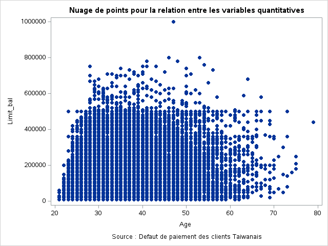

Nuage de points pour la relation entre les variables quantitatives

La procédure FREQ

| defaultpayment | defaultpayment Fréquence | defaultpayment Pourcentage | defaultpayment Fréquence cumulée | defaultpayment Pourcentage cumulé |
| --- | --- | --- | --- | --- |
| 0 | 23364 | 77.88 | 23364 | 77.88 |
| 1 | 6636 | 22.12 | 30000 | 100.00 |

| SEX | SEX Fréquence | SEX Pourcentage | SEX Fréquence cumulée | SEX Pourcentage cumulé |
| --- | --- | --- | --- | --- |
| 1 | 11888 | 39.63 | 11888 | 39.63 |
| 2 | 18112 | 60.37 | 30000 | 100.00 |

| EDUCATION | EDUCATION Fréquence | EDUCATION Pourcentage | EDUCATION Fréquence cumulée | EDUCATION Pourcentage cumulé |
| --- | --- | --- | --- | --- |
| 0 | 14 | 0.05 | 14 | 0.05 |
| 1 | 10585 | 35.28 | 10599 | 35.33 |
| 2 | 14030 | 46.77 | 24629 | 82.10 |
| 3 | 4917 | 16.39 | 29546 | 98.49 |
| 4 | 123 | 0.41 | 29669 | 98.90 |
| 5 | 280 | 0.93 | 29949 | 99.83 |
| 6 | 51 | 0.17 | 30000 | 100.00 |

| MARRIAGE | MARRIAGE Fréquence | MARRIAGE Pourcentage | MARRIAGE Fréquence cumulée | MARRIAGE Pourcentage cumulé |
| --- | --- | --- | --- | --- |
| 0 | 54 | 0.18 | 54 | 0.18 |
| 1 | 13659 | 45.53 | 13713 | 45.71 |
| 2 | 15964 | 53.21 | 29677 | 98.92 |
| 3 | 323 | 1.08 | 30000 | 100.00 |

Source : Defaut de paiement des clients Taiwanais

Statistiques sur le defaut de paiement

La procédure UNIVARIATE

Variable : defaultpayment (defaultpayment)

| Moments |  |  |  |
| --- | --- | --- | --- |
| N | 30000 | Somme des poids | 30000 |
| Moyenne | 0.2212 | Somme des observations | 6636 |
| Ecart-type | 0.41506181 | Variance | 0.1722763 |
| Skewness | 1.34350395 | Kurtosis | -0.1950101 |
| Somme des carrés non corrigée | 6636 | Somme des carrés corrigée | 5168.1168 |
| Coeff Variation | 187.640961 | Std Error Mean | 0.00239636 |

| Mesures statistiques de base Location | Mesures statistiques de base Location | Mesures statistiques de base Variabilité | Mesures statistiques de base Variabilité |
| --- | --- | --- | --- |
| Moyenne | 0.221200 | Ecart-type | 0.41506 |
| Médiane | 0.000000 | Variance | 0.17228 |
| Mode | 0.000000 | Intervalle | 1.00000 |
|  |  | Ecart interquartile | 0 |

| Tests de tendance centrale : Mu0=0 Test | Tests de tendance centrale : Mu0=0 Statistique | Tests de tendance centrale : Mu0=0 Statistique | Tests de tendance centrale : Mu0=0 p-value | Tests de tendance centrale : Mu0=0 p-value |
| --- | --- | --- | --- | --- |
| t de Student | t | 92.30665 | Pr > \|t\| | <.0001 |
| Signe | M | 3318 | Pr >= \|M\| | <.0001 |
| Rang signé | S | 11010783 | Pr >= \|S\| | <.0001 |

| Quantiles (Définition 5) Niveau | Quantiles (Définition 5) Quantile |
| --- | --- |
| 100Max 100% | 1 |
| 99% | 1 |
| 95% | 1 |
| 90% | 1 |
| 75% Q3 | 0 |
| 50% Médiane | 0 |
| 25% Q1 | 0 |
| 10% | 0 |
| 5% | 0 |
| 1% | 0 |
| 0% Min | 0 |

| Observations extrêmes La plus petite Valeur | Observations extrêmes La plus petite Obs | Observations extrêmes La plus grande Valeur | Observations extrêmes La plus grande Obs |
| --- | --- | --- | --- |
| 0 | 29997 | 1 | 29992 |
| 0 | 29996 | 1 | 29995 |
| 0 | 29994 | 1 | 29998 |
| 0 | 29993 | 1 | 29999 |
| 0 | 29991 | 1 | 30000 |

Source : Defaut de paiement des clients Taiwanais

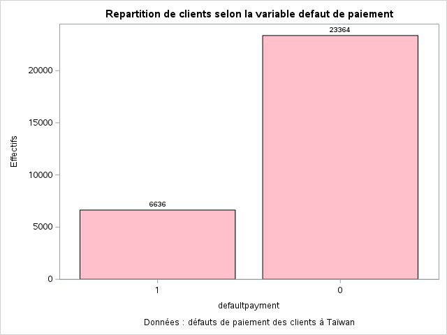

[figure not shown]

[figure not shown]

[figure not shown]

Repartition de clients selon la variable defaut de paiement

La procédure UNIVARIATE

Variable : ID (ID)

| Moments |  |  |  |
| --- | --- | --- | --- |
| N | 30000 | Somme des poids | 30000 |
| Moyenne | 15000.5 | Somme des observations | 450015000 |
| Ecart-type | 8660.39837 | Variance | 75002500 |
| Skewness | 0 | Kurtosis | -1.2 |
| Somme des carrés non corrigée | 9.00045E12 | Somme des carrés corrigée | 2.25E12 |
| Coeff Variation | 57.7340647 | Std Error Mean | 50.0008333 |

| Mesures statistiques de base Location | Mesures statistiques de base Location | Mesures statistiques de base Variabilité | Mesures statistiques de base Variabilité |
| --- | --- | --- | --- |
| Moyenne | 15000.50 | Ecart-type | 8660 |
| Médiane | 15000.50 | Variance | 75002500 |
| Mode | . | Intervalle | 29999 |
|  |  | Ecart interquartile | 15000 |

| Tests de tendance centrale : Mu0=0 Test | Tests de tendance centrale : Mu0=0 Statistique | Tests de tendance centrale : Mu0=0 Statistique | Tests de tendance centrale : Mu0=0 p-value | Tests de tendance centrale : Mu0=0 p-value |
| --- | --- | --- | --- | --- |
| t de Student | t | 300.005 | Pr > \|t\| | <.0001 |
| Signe | M | 15000 | Pr >= \|M\| | <.0001 |
| Rang signé | S | 2.2501E8 | Pr >= \|S\| | <.0001 |

| Quantiles (Définition 5) Niveau | Quantiles (Définition 5) Quantile |
| --- | --- |
| 100Max 100% | 30000.0 |
| 99% | 29700.5 |
| 95% | 28500.5 |
| 90% | 27000.5 |
| 75% Q3 | 22500.5 |
| 50% Médiane | 15000.5 |
| 25% Q1 | 7500.5 |
| 10% | 3000.5 |
| 5% | 1500.5 |
| 1% | 300.5 |
| 0% Min | 1.0 |

| Observations extrêmes La plus petite Valeur | Observations extrêmes La plus petite Obs | Observations extrêmes La plus grande Valeur | Observations extrêmes La plus grande Obs |
| --- | --- | --- | --- |
| 1 | 1 | 29996 | 29996 |
| 2 | 2 | 29997 | 29997 |
| 3 | 3 | 29998 | 29998 |
| 4 | 4 | 29999 | 29999 |
| 5 | 5 | 30000 | 30000 |

Données : défauts de paiement des clients à Taïwan

Repartition de clients selon la variable defaut de paiement

La procédure UNIVARIATE

Variable : LIMIT_BAL (LIMIT_BAL)

| Moments |  |  |  |
| --- | --- | --- | --- |
| N | 30000 | Somme des poids | 30000 |
| Moyenne | 167484.323 | Somme des observations | 5024529680 |
| Ecart-type | 129747.662 | Variance | 1.68345E10 |
| Skewness | 0.99286696 | Kurtosis | 0.5362629 |
| Somme des carrés non corrigée | 1.34655E15 | Somme des carrés corrigée | 5.05017E14 |
| Coeff Variation | 77.4685412 | Std Error Mean | 749.098473 |

| Mesures statistiques de base Location | Mesures statistiques de base Location | Mesures statistiques de base Variabilité | Mesures statistiques de base Variabilité |
| --- | --- | --- | --- |
| Moyenne | 167484.3 | Ecart-type | 129748 |
| Médiane | 140000.0 | Variance | 1.68345E10 |
| Mode | 50000.0 | Intervalle | 990000 |
|  |  | Ecart interquartile | 190000 |

| Tests de tendance centrale : Mu0=0 Test | Tests de tendance centrale : Mu0=0 Statistique | Tests de tendance centrale : Mu0=0 Statistique | Tests de tendance centrale : Mu0=0 p-value | Tests de tendance centrale : Mu0=0 p-value |
| --- | --- | --- | --- | --- |
| t de Student | t | 223.5812 | Pr > \|t\| | <.0001 |
| Signe | M | 15000 | Pr >= \|M\| | <.0001 |
| Rang signé | S | 2.2501E8 | Pr >= \|S\| | <.0001 |

| Quantiles (Définition 5) Niveau | Quantiles (Définition 5) Quantile |
| --- | --- |
| 100Max 100% | 1000000 |
| 99% | 500000 |
| 95% | 430000 |
| 90% | 360000 |
| 75% Q3 | 240000 |
| 50% Médiane | 140000 |
| 25% Q1 | 50000 |
| 10% | 30000 |
| 5% | 20000 |
| 1% | 10000 |
| 0% Min | 10000 |

| Observations extrêmes La plus petite Valeur | Observations extrêmes La plus petite Obs | Observations extrêmes La plus grande Valeur | Observations extrêmes La plus grande Obs |
| --- | --- | --- | --- |
| 10000 | 29993 | 780000 | 24321 |
| 10000 | 29961 | 780000 | 28716 |
| 10000 | 29916 | 800000 | 14920 |
| 10000 | 29871 | 800000 | 18007 |
| 10000 | 29846 | 1000000 | 2198 |

Données : défauts de paiement des clients à Taïwan

Repartition de clients selon la variable defaut de paiement

La procédure UNIVARIATE

Variable : SEX (SEX)

| Moments |  |  |  |
| --- | --- | --- | --- |
| N | 30000 | Somme des poids | 30000 |
| Moyenne | 1.60373333 | Somme des observations | 48112 |
| Ecart-type | 0.4891292 | Variance | 0.23924737 |
| Skewness | -0.4241834 | Kurtosis | -1.8201898 |
| Somme des carrés non corrigée | 84336 | Somme des carrés corrigée | 7177.18187 |
| Coeff Variation | 30.4994095 | Std Error Mean | 0.00282399 |

| Mesures statistiques de base Location | Mesures statistiques de base Location | Mesures statistiques de base Variabilité | Mesures statistiques de base Variabilité |
| --- | --- | --- | --- |
| Moyenne | 1.603733 | Ecart-type | 0.48913 |
| Médiane | 2.000000 | Variance | 0.23925 |
| Mode | 2.000000 | Intervalle | 1.00000 |
|  |  | Ecart interquartile | 1.00000 |

| Tests de tendance centrale : Mu0=0 Test | Tests de tendance centrale : Mu0=0 Statistique | Tests de tendance centrale : Mu0=0 Statistique | Tests de tendance centrale : Mu0=0 p-value | Tests de tendance centrale : Mu0=0 p-value |
| --- | --- | --- | --- | --- |
| t de Student | t | 567.8965 | Pr > \|t\| | <.0001 |
| Signe | M | 15000 | Pr >= \|M\| | <.0001 |
| Rang signé | S | 2.2501E8 | Pr >= \|S\| | <.0001 |

| Quantiles (Définition 5) Niveau | Quantiles (Définition 5) Quantile |
| --- | --- |
| 100Max 100% | 2 |
| 99% | 2 |
| 95% | 2 |
| 90% | 2 |
| 75% Q3 | 2 |
| 50% Médiane | 2 |
| 25% Q1 | 1 |
| 10% | 1 |
| 5% | 1 |
| 1% | 1 |
| 0% Min | 1 |

| Observations extrêmes La plus petite Valeur | Observations extrêmes La plus petite Obs | Observations extrêmes La plus grande Valeur | Observations extrêmes La plus grande Obs |
| --- | --- | --- | --- |
| 1 | 30000 | 2 | 29181 |
| 1 | 29999 | 2 | 29182 |
| 1 | 29998 | 2 | 29183 |
| 1 | 29997 | 2 | 29186 |
| 1 | 29996 | 2 | 29283 |

Données : défauts de paiement des clients à Taïwan

Repartition de clients selon la variable defaut de paiement

La procédure UNIVARIATE

Variable : EDUCATION (EDUCATION)

| Moments |  |  |  |
| --- | --- | --- | --- |
| N | 30000 | Somme des poids | 30000 |
| Moyenne | 1.85313333 | Somme des observations | 55594 |
| Ecart-type | 0.79034866 | Variance | 0.624651 |
| Skewness | 0.97097205 | Kurtosis | 2.0786216 |
| Somme des carrés non corrigée | 121762 | Somme des carrés corrigée | 18738.9055 |
| Coeff Variation | 42.6493143 | Std Error Mean | 0.00456308 |

| Mesures statistiques de base Location | Mesures statistiques de base Location | Mesures statistiques de base Variabilité | Mesures statistiques de base Variabilité |
| --- | --- | --- | --- |
| Moyenne | 1.853133 | Ecart-type | 0.79035 |
| Médiane | 2.000000 | Variance | 0.62465 |
| Mode | 2.000000 | Intervalle | 6.00000 |
|  |  | Ecart interquartile | 1.00000 |

| Tests de tendance centrale : Mu0=0 Test | Tests de tendance centrale : Mu0=0 Statistique | Tests de tendance centrale : Mu0=0 Statistique | Tests de tendance centrale : Mu0=0 p-value | Tests de tendance centrale : Mu0=0 p-value |
| --- | --- | --- | --- | --- |
| t de Student | t | 406.1146 | Pr > \|t\| | <.0001 |
| Signe | M | 14993 | Pr >= \|M\| | <.0001 |
| Rang signé | S | 2.248E8 | Pr >= \|S\| | <.0001 |

| Quantiles (Définition 5) Niveau | Quantiles (Définition 5) Quantile |
| --- | --- |
| 100Max 100% | 6 |
| 99% | 5 |
| 95% | 3 |
| 90% | 3 |
| 75% Q3 | 2 |
| 50% Médiane | 2 |
| 25% Q1 | 1 |
| 10% | 1 |
| 5% | 1 |
| 1% | 1 |
| 0% Min | 0 |

| Observations extrêmes La plus petite Valeur | Observations extrêmes La plus petite Obs | Observations extrêmes La plus grande Valeur | Observations extrêmes La plus grande Obs |
| --- | --- | --- | --- |
| 0 | 27271 | 6 | 27565 |
| 0 | 27156 | 6 | 28781 |
| 0 | 24138 | 6 | 28853 |
| 0 | 23235 | 6 | 29341 |
| 0 | 20031 | 6 | 29837 |

Données : défauts de paiement des clients à Taïwan

Repartition de clients selon la variable defaut de paiement

La procédure UNIVARIATE

Variable : MARRIAGE (MARRIAGE)

| Moments |  |  |  |
| --- | --- | --- | --- |
| N | 30000 | Somme des poids | 30000 |
| Moyenne | 1.55186667 | Somme des observations | 46556 |
| Ecart-type | 0.5219696 | Variance | 0.27245226 |
| Skewness | -0.0187417 | Kurtosis | -1.3633678 |
| Somme des carrés non corrigée | 80422 | Somme des carrés corrigée | 8173.29547 |
| Coeff Variation | 33.6349515 | Std Error Mean | 0.00301359 |

| Mesures statistiques de base Location | Mesures statistiques de base Location | Mesures statistiques de base Variabilité | Mesures statistiques de base Variabilité |
| --- | --- | --- | --- |
| Moyenne | 1.551867 | Ecart-type | 0.52197 |
| Médiane | 2.000000 | Variance | 0.27245 |
| Mode | 2.000000 | Intervalle | 3.00000 |
|  |  | Ecart interquartile | 1.00000 |

| Tests de tendance centrale : Mu0=0 Test | Tests de tendance centrale : Mu0=0 Statistique | Tests de tendance centrale : Mu0=0 Statistique | Tests de tendance centrale : Mu0=0 p-value | Tests de tendance centrale : Mu0=0 p-value |
| --- | --- | --- | --- | --- |
| t de Student | t | 514.9556 | Pr > \|t\| | <.0001 |
| Signe | M | 14973 | Pr >= \|M\| | <.0001 |
| Rang signé | S | 2.242E8 | Pr >= \|S\| | <.0001 |

| Quantiles (Définition 5) Niveau | Quantiles (Définition 5) Quantile |
| --- | --- |
| 100Max 100% | 3 |
| 99% | 3 |
| 95% | 2 |
| 90% | 2 |
| 75% Q3 | 2 |
| 50% Médiane | 2 |
| 25% Q1 | 1 |
| 10% | 1 |
| 5% | 1 |
| 1% | 1 |
| 0% Min | 0 |

| Observations extrêmes La plus petite Valeur | Observations extrêmes La plus petite Obs | Observations extrêmes La plus grande Valeur | Observations extrêmes La plus grande Obs |
| --- | --- | --- | --- |
| 0 | 29112 | 3 | 29283 |
| 0 | 29079 | 3 | 29510 |
| 0 | 28767 | 3 | 29613 |
| 0 | 28604 | 3 | 29746 |
| 0 | 28603 | 3 | 29932 |

Données : défauts de paiement des clients à Taïwan

Repartition de clients selon la variable defaut de paiement

La procédure UNIVARIATE

Variable : AGE (AGE)

| Moments |  |  |  |
| --- | --- | --- | --- |
| N | 30000 | Somme des poids | 30000 |
| Moyenne | 35.4855 | Somme des observations | 1064565 |
| Ecart-type | 9.21790407 | Variance | 84.9697554 |
| Skewness | 0.73224587 | Kurtosis | 0.04430338 |
| Somme des carrés non corrigée | 40325629 | Somme des carrés corrigée | 2549007.69 |
| Coeff Variation | 25.9765371 | Std Error Mean | 0.05321959 |

| Mesures statistiques de base Location | Mesures statistiques de base Location | Mesures statistiques de base Variabilité | Mesures statistiques de base Variabilité |
| --- | --- | --- | --- |
| Moyenne | 35.48550 | Ecart-type | 9.21790 |
| Médiane | 34.00000 | Variance | 84.96976 |
| Mode | 29.00000 | Intervalle | 58.00000 |
|  |  | Ecart interquartile | 13.00000 |

| Tests de tendance centrale : Mu0=0 Test | Tests de tendance centrale : Mu0=0 Statistique | Tests de tendance centrale : Mu0=0 Statistique | Tests de tendance centrale : Mu0=0 p-value | Tests de tendance centrale : Mu0=0 p-value |
| --- | --- | --- | --- | --- |
| t de Student | t | 666.7751 | Pr > \|t\| | <.0001 |
| Signe | M | 15000 | Pr >= \|M\| | <.0001 |
| Rang signé | S | 2.2501E8 | Pr >= \|S\| | <.0001 |

| Quantiles (Définition 5) Niveau | Quantiles (Définition 5) Quantile |
| --- | --- |
| 100Max 100% | 79 |
| 99% | 60 |
| 95% | 53 |
| 90% | 49 |
| 75% Q3 | 41 |
| 50% Médiane | 34 |
| 25% Q1 | 28 |
| 10% | 25 |
| 5% | 23 |
| 1% | 22 |
| 0% Min | 21 |

| Observations extrêmes La plus petite Valeur | Observations extrêmes La plus petite Obs | Observations extrêmes La plus grande Valeur | Observations extrêmes La plus grande Obs |
| --- | --- | --- | --- |
| 21 | 27663 | 74 | 29176 |
| 21 | 27631 | 75 | 247 |
| 21 | 25303 | 75 | 25137 |
| 21 | 25183 | 75 | 25142 |
| 21 | 25175 | 79 | 18246 |

Données : défauts de paiement des clients à Taïwan

Repartition de clients selon la variable defaut de paiement

La procédure UNIVARIATE

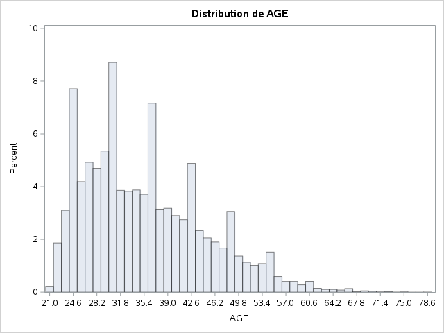

Données : défauts de paiement des clients à Taïwan

Repartition de clients selon la variable defaut de paiement

La procédure UNIVARIATE

Variable : PAY_0 (PAY_0)

| Moments |  |  |  |
| --- | --- | --- | --- |
| N | 30000 | Somme des poids | 30000 |
| Moyenne | -0.0167 | Somme des observations | -501 |
| Ecart-type | 1.12380153 | Variance | 1.26292987 |
| Skewness | 0.73197493 | Kurtosis | 2.72071504 |
| Somme des carrés non corrigée | 37895 | Somme des carrés corrigée | 37886.6333 |
| Coeff Variation | -6729.3505 | Std Error Mean | 0.00648827 |

| Mesures statistiques de base Location | Mesures statistiques de base Location | Mesures statistiques de base Variabilité | Mesures statistiques de base Variabilité |
| --- | --- | --- | --- |
| Moyenne | -0.01670 | Ecart-type | 1.12380 |
| Médiane | 0.00000 | Variance | 1.26293 |
| Mode | 0.00000 | Intervalle | 10.00000 |
|  |  | Ecart interquartile | 1.00000 |

| Tests de tendance centrale : Mu0=0 Test | Tests de tendance centrale : Mu0=0 Statistique | Tests de tendance centrale : Mu0=0 Statistique | Tests de tendance centrale : Mu0=0 p-value | Tests de tendance centrale : Mu0=0 p-value |
| --- | --- | --- | --- | --- |
| t de Student | t | -2.57388 | Pr > \|t\| | 0.0101 |
| Signe | M | -813.5 | Pr >= \|M\| | <.0001 |
| Rang signé | S | -1758930 | Pr >= \|S\| | 0.0008 |

| Quantiles (Définition 5) Niveau | Quantiles (Définition 5) Quantile |
| --- | --- |
| 100Max 100% | 8 |
| 99% | 3 |
| 95% | 2 |
| 90% | 2 |
| 75% Q3 | 0 |
| 50% Médiane | 0 |
| 25% Q1 | -1 |
| 10% | -1 |
| 5% | -2 |
| 1% | -2 |
| 0% Min | -2 |

| Observations extrêmes La plus petite Valeur | Observations extrêmes La plus petite Obs | Observations extrêmes La plus grande Valeur | Observations extrêmes La plus grande Obs |
| --- | --- | --- | --- |
| -2 | 29986 | 8 | 13636 |
| -2 | 29984 | 8 | 13713 |
| -2 | 29980 | 8 | 18868 |
| -2 | 29962 | 8 | 23040 |
| -2 | 29947 | 8 | 25870 |

Données : défauts de paiement des clients à Taïwan

Repartition de clients selon la variable defaut de paiement

La procédure UNIVARIATE

Variable : PAY_2 (PAY_2)

| Moments |  |  |  |
| --- | --- | --- | --- |
| N | 30000 | Somme des poids | 30000 |
| Moyenne | -0.1337667 | Somme des observations | -4013 |
| Ecart-type | 1.19718597 | Variance | 1.43325425 |
| Skewness | 0.79056502 | Kurtosis | 1.57041773 |
| Somme des carrés non corrigée | 43533 | Somme des carrés corrigée | 42996.1944 |
| Coeff Variation | -894.98079 | Std Error Mean | 0.00691196 |

| Mesures statistiques de base Location | Mesures statistiques de base Location | Mesures statistiques de base Variabilité | Mesures statistiques de base Variabilité |
| --- | --- | --- | --- |
| Moyenne | -0.13377 | Ecart-type | 1.19719 |
| Médiane | 0.00000 | Variance | 1.43325 |
| Mode | 0.00000 | Intervalle | 10.00000 |
|  |  | Ecart interquartile | 1.00000 |

| Tests de tendance centrale : Mu0=0 Test | Tests de tendance centrale : Mu0=0 Statistique | Tests de tendance centrale : Mu0=0 Statistique | Tests de tendance centrale : Mu0=0 p-value | Tests de tendance centrale : Mu0=0 p-value |
| --- | --- | --- | --- | --- |
| t de Student | t | -19.3529 | Pr > \|t\| | <.0001 |
| Signe | M | -2697 | Pr >= \|M\| | <.0001 |
| Rang signé | S | -5043789 | Pr >= \|S\| | <.0001 |

| Quantiles (Définition 5) Niveau | Quantiles (Définition 5) Quantile |
| --- | --- |
| 100Max 100% | 8 |
| 99% | 3 |
| 95% | 2 |
| 90% | 2 |
| 75% Q3 | 0 |
| 50% Médiane | 0 |
| 25% Q1 | -1 |
| 10% | -2 |
| 5% | -2 |
| 1% | -2 |
| 0% Min | -2 |

| Observations extrêmes La plus petite Valeur | Observations extrêmes La plus petite Obs | Observations extrêmes La plus grande Valeur | Observations extrêmes La plus grande Obs |
| --- | --- | --- | --- |
| -2 | 29986 | 7 | 18868 |
| -2 | 29984 | 7 | 23040 |
| -2 | 29980 | 7 | 25144 |
| -2 | 29974 | 7 | 25870 |
| -2 | 29962 | 8 | 8844 |

Données : défauts de paiement des clients à Taïwan

Repartition de clients selon la variable defaut de paiement

La procédure UNIVARIATE

Variable : PAY_3 (PAY_3)

| Moments |  |  |  |
| --- | --- | --- | --- |
| N | 30000 | Somme des poids | 30000 |
| Moyenne | -0.1662 | Somme des observations | -4986 |
| Ecart-type | 1.19686757 | Variance | 1.43249198 |
| Skewness | 0.84068183 | Kurtosis | 2.08443588 |
| Somme des carrés non corrigée | 43802 | Somme des carrés corrigée | 42973.3268 |
| Coeff Variation | -720.13692 | Std Error Mean | 0.00691012 |

| Mesures statistiques de base Location | Mesures statistiques de base Location | Mesures statistiques de base Variabilité | Mesures statistiques de base Variabilité |
| --- | --- | --- | --- |
| Moyenne | -0.16620 | Ecart-type | 1.19687 |
| Médiane | 0.00000 | Variance | 1.43249 |
| Mode | 0.00000 | Intervalle | 10.00000 |
|  |  | Ecart interquartile | 1.00000 |

| Tests de tendance centrale : Mu0=0 Test | Tests de tendance centrale : Mu0=0 Statistique | Tests de tendance centrale : Mu0=0 Statistique | Tests de tendance centrale : Mu0=0 p-value | Tests de tendance centrale : Mu0=0 p-value |
| --- | --- | --- | --- | --- |
| t de Student | t | -24.0517 | Pr > \|t\| | <.0001 |
| Signe | M | -2905 | Pr >= \|M\| | <.0001 |
| Rang signé | S | -7394317 | Pr >= \|S\| | <.0001 |

| Quantiles (Définition 5) Niveau | Quantiles (Définition 5) Quantile |
| --- | --- |
| 100Max 100% | 8 |
| 99% | 3 |
| 95% | 2 |
| 90% | 2 |
| 75% Q3 | 0 |
| 50% Médiane | 0 |
| 25% Q1 | -1 |
| 10% | -2 |
| 5% | -2 |
| 1% | -2 |
| 0% Min | -2 |

| Observations extrêmes La plus petite Valeur | Observations extrêmes La plus petite Obs | Observations extrêmes La plus grande Valeur | Observations extrêmes La plus grande Obs |
| --- | --- | --- | --- |
| -2 | 29987 | 7 | 14892 |
| -2 | 29986 | 7 | 14974 |
| -2 | 29985 | 8 | 8655 |
| -2 | 29984 | 8 | 18004 |
| -2 | 29980 | 8 | 29800 |

Données : défauts de paiement des clients à Taïwan

Repartition de clients selon la variable defaut de paiement

La procédure UNIVARIATE

Variable : PAY_4 (PAY_4)

| Moments |  |  |  |
| --- | --- | --- | --- |
| N | 30000 | Somme des poids | 30000 |
| Moyenne | -0.2206667 | Somme des observations | -6620 |
| Ecart-type | 1.16913862 | Variance | 1.36688512 |
| Skewness | 0.99962941 | Kurtosis | 3.4969835 |
| Somme des carrés non corrigée | 42466 | Somme des carrés corrigée | 41005.1867 |
| Coeff Variation | -529.82113 | Std Error Mean | 0.00675002 |

| Mesures statistiques de base Location | Mesures statistiques de base Location | Mesures statistiques de base Variabilité | Mesures statistiques de base Variabilité |
| --- | --- | --- | --- |
| Moyenne | -0.22067 | Ecart-type | 1.16914 |
| Médiane | 0.00000 | Variance | 1.36689 |
| Mode | 0.00000 | Intervalle | 10.00000 |
|  |  | Ecart interquartile | 1.00000 |

| Tests de tendance centrale : Mu0=0 Test | Tests de tendance centrale : Mu0=0 Statistique | Tests de tendance centrale : Mu0=0 Statistique | Tests de tendance centrale : Mu0=0 p-value | Tests de tendance centrale : Mu0=0 p-value |
| --- | --- | --- | --- | --- |
| t de Student | t | -32.6912 | Pr > \|t\| | <.0001 |
| Signe | M | -3262.5 | Pr >= \|M\| | <.0001 |
| Rang signé | S | -1.137E7 | Pr >= \|S\| | <.0001 |

| Quantiles (Définition 5) Niveau | Quantiles (Définition 5) Quantile |
| --- | --- |
| 100Max 100% | 8 |
| 99% | 3 |
| 95% | 2 |
| 90% | 2 |
| 75% Q3 | 0 |
| 50% Médiane | 0 |
| 25% Q1 | -1 |
| 10% | -2 |
| 5% | -2 |
| 1% | -2 |
| 0% Min | -2 |

| Observations extrêmes La plus petite Valeur | Observations extrêmes La plus petite Obs | Observations extrêmes La plus grande Valeur | Observations extrêmes La plus grande Obs |
| --- | --- | --- | --- |
| -2 | 29993 | 7 | 29727 |
| -2 | 29987 | 7 | 29771 |
| -2 | 29986 | 7 | 29800 |
| -2 | 29984 | 8 | 8655 |
| -2 | 29980 | 8 | 9080 |

Données : défauts de paiement des clients à Taïwan

Repartition de clients selon la variable defaut de paiement

La procédure UNIVARIATE

Variable : PAY_5 (PAY_5)

| Moments |  |  |  |
| --- | --- | --- | --- |
| N | 30000 | Somme des poids | 30000 |
| Moyenne | -0.2662 | Somme des observations | -7986 |
| Ecart-type | 1.13318741 | Variance | 1.2841137 |
| Skewness | 1.00819703 | Kurtosis | 3.98974814 |
| Somme des carrés non corrigée | 40648 | Somme des carrés corrigée | 38522.1268 |
| Coeff Variation | -425.69024 | Std Error Mean | 0.00654246 |

| Mesures statistiques de base Location | Mesures statistiques de base Location | Mesures statistiques de base Variabilité | Mesures statistiques de base Variabilité |
| --- | --- | --- | --- |
| Moyenne | -0.26620 | Ecart-type | 1.13319 |
| Médiane | 0.00000 | Variance | 1.28411 |
| Mode | 0.00000 | Intervalle | 10.00000 |
|  |  | Ecart interquartile | 1.00000 |

| Tests de tendance centrale : Mu0=0 Test | Tests de tendance centrale : Mu0=0 Statistique | Tests de tendance centrale : Mu0=0 Statistique | Tests de tendance centrale : Mu0=0 p-value | Tests de tendance centrale : Mu0=0 p-value |
| --- | --- | --- | --- | --- |
| t de Student | t | -40.6881 | Pr > \|t\| | <.0001 |
| Signe | M | -3558.5 | Pr >= \|M\| | <.0001 |
| Rang signé | S | -1.423E7 | Pr >= \|S\| | <.0001 |

| Quantiles (Définition 5) Niveau | Quantiles (Définition 5) Quantile |
| --- | --- |
| 100Max 100% | 8 |
| 99% | 3 |
| 95% | 2 |
| 90% | 0 |
| 75% Q3 | 0 |
| 50% Médiane | 0 |
| 25% Q1 | -1 |
| 10% | -2 |
| 5% | -2 |
| 1% | -2 |
| 0% Min | -2 |

| Observations extrêmes La plus petite Valeur | Observations extrêmes La plus petite Obs | Observations extrêmes La plus grande Valeur | Observations extrêmes La plus grande Obs |
| --- | --- | --- | --- |
| -2 | 29993 | 7 | 29524 |
| -2 | 29987 | 7 | 29580 |
| -2 | 29986 | 7 | 29727 |
| -2 | 29984 | 7 | 29771 |
| -2 | 29980 | 8 | 8655 |

Données : défauts de paiement des clients à Taïwan

Repartition de clients selon la variable defaut de paiement

La procédure UNIVARIATE

Variable : PAY_6 (PAY_6)

| Moments |  |  |  |
| --- | --- | --- | --- |
| N | 30000 | Somme des poids | 30000 |
| Moyenne | -0.2911 | Somme des observations | -8733 |
| Ecart-type | 1.14998763 | Variance | 1.32247154 |
| Skewness | 0.94802939 | Kurtosis | 3.42653413 |
| Somme des carrés non corrigée | 42215 | Somme des carrés corrigée | 39672.8237 |
| Coeff Variation | -395.049 | Std Error Mean | 0.00663946 |

| Mesures statistiques de base Location | Mesures statistiques de base Location | Mesures statistiques de base Variabilité | Mesures statistiques de base Variabilité |
| --- | --- | --- | --- |
| Moyenne | -0.29110 | Ecart-type | 1.14999 |
| Médiane | 0.00000 | Variance | 1.32247 |
| Mode | 0.00000 | Intervalle | 10.00000 |
|  |  | Ecart interquartile | 1.00000 |

| Tests de tendance centrale : Mu0=0 Test | Tests de tendance centrale : Mu0=0 Statistique | Tests de tendance centrale : Mu0=0 Statistique | Tests de tendance centrale : Mu0=0 p-value | Tests de tendance centrale : Mu0=0 p-value |
| --- | --- | --- | --- | --- |
| t de Student | t | -43.8439 | Pr > \|t\| | <.0001 |
| Signe | M | -3778 | Pr >= \|M\| | <.0001 |
| Rang signé | S | -1.63E7 | Pr >= \|S\| | <.0001 |

| Quantiles (Définition 5) Niveau | Quantiles (Définition 5) Quantile |
| --- | --- |
| 100Max 100% | 8 |
| 99% | 3 |
| 95% | 2 |
| 90% | 2 |
| 75% Q3 | 0 |
| 50% Médiane | 0 |
| 25% Q1 | -1 |
| 10% | -2 |
| 5% | -2 |
| 1% | -2 |
| 0% Min | -2 |

| Observations extrêmes La plus petite Valeur | Observations extrêmes La plus petite Obs | Observations extrêmes La plus grande Valeur | Observations extrêmes La plus grande Obs |
| --- | --- | --- | --- |
| -2 | 29993 | 7 | 29524 |
| -2 | 29990 | 7 | 29580 |
| -2 | 29987 | 7 | 29771 |
| -2 | 29986 | 8 | 1895 |
| -2 | 29984 | 8 | 8655 |

Données : défauts de paiement des clients à Taïwan

Repartition de clients selon la variable defaut de paiement

La procédure UNIVARIATE

Variable : BILL_AMT1 (BILL_AMT1)

| Moments |  |  |  |
| --- | --- | --- | --- |
| N | 30000 | Somme des poids | 30000 |
| Moyenne | 51223.3309 | Somme des observations | 1536699927 |
| Ecart-type | 73635.8606 | Variance | 5422239963 |
| Skewness | 2.66386102 | Kurtosis | 9.80628934 |
| Somme des carrés non corrigée | 2.41377E14 | Somme des carrés corrigée | 1.62662E14 |
| Coeff Variation | 143.754534 | Std Error Mean | 425.136839 |

| Mesures statistiques de base Location | Mesures statistiques de base Location | Mesures statistiques de base Variabilité | Mesures statistiques de base Variabilité |
| --- | --- | --- | --- |
| Moyenne | 51223.33 | Ecart-type | 73636 |
| Médiane | 22381.50 | Variance | 5422239963 |
| Mode | 0.00 | Intervalle | 1130091 |
|  |  | Ecart interquartile | 63534 |

| Tests de tendance centrale : Mu0=0 Test | Tests de tendance centrale : Mu0=0 Statistique | Tests de tendance centrale : Mu0=0 Statistique | Tests de tendance centrale : Mu0=0 p-value | Tests de tendance centrale : Mu0=0 p-value |
| --- | --- | --- | --- | --- |
| t de Student | t | 120.4867 | Pr > \|t\| | <.0001 |
| Signe | M | 13406 | Pr >= \|M\| | <.0001 |
| Rang signé | S | 1.9516E8 | Pr >= \|S\| | <.0001 |

| Quantiles (Définition 5) Niveau | Quantiles (Définition 5) Quantile |
| --- | --- |
| 100Max 100% | 964511.0 |
| 99% | 350144.0 |
| 95% | 201212.5 |
| 90% | 142140.5 |
| 75% Q3 | 67092.0 |
| 50% Médiane | 22381.5 |
| 25% Q1 | 3558.5 |
| 10% | 278.5 |
| 5% | 0.0 |
| 1% | -81.0 |
| 0% Min | -165580.0 |

| Observations extrêmes La plus petite Valeur | Observations extrêmes La plus petite Obs | Observations extrêmes La plus grande Valeur | Observations extrêmes La plus grande Obs |
| --- | --- | --- | --- |
| -165580 | 12331 | 626648 | 28143 |
| -154973 | 23004 | 630458 | 6913 |
| -15308 | 8836 | 653062 | 26548 |
| -14386 | 352 | 746814 | 27558 |
| -11545 | 29780 | 964511 | 2198 |

Données : défauts de paiement des clients à Taïwan

Repartition de clients selon la variable defaut de paiement

La procédure UNIVARIATE

Variable : BILL_AMT2 (BILL_AMT2)

| Moments |  |  |  |
| --- | --- | --- | --- |
| N | 30000 | Somme des poids | 30000 |
| Moyenne | 49179.0752 | Somme des observations | 1475372255 |
| Ecart-type | 71173.7688 | Variance | 5065705363 |
| Skewness | 2.70522085 | Kurtosis | 10.3029459 |
| Somme des carrés non corrigée | 2.24524E14 | Somme des carrés corrigée | 1.51966E14 |
| Coeff Variation | 144.723683 | Std Error Mean | 410.921946 |

| Mesures statistiques de base Location | Mesures statistiques de base Location | Mesures statistiques de base Variabilité | Mesures statistiques de base Variabilité |
| --- | --- | --- | --- |
| Moyenne | 49179.08 | Ecart-type | 71174 |
| Médiane | 21200.00 | Variance | 5065705363 |
| Mode | 0.00 | Intervalle | 1053708 |
|  |  | Ecart interquartile | 61024 |

| Tests de tendance centrale : Mu0=0 Test | Tests de tendance centrale : Mu0=0 Statistique | Tests de tendance centrale : Mu0=0 Statistique | Tests de tendance centrale : Mu0=0 p-value | Tests de tendance centrale : Mu0=0 p-value |
| --- | --- | --- | --- | --- |
| t de Student | t | 119.6798 | Pr > \|t\| | <.0001 |
| Signe | M | 13078 | Pr >= \|M\| | <.0001 |
| Rang signé | S | 1.8796E8 | Pr >= \|S\| | <.0001 |

| Quantiles (Définition 5) Niveau | Quantiles (Définition 5) Quantile |
| --- | --- |
| 100Max 100% | 983931.0 |
| 99% | 337509.0 |
| 95% | 194794.0 |
| 90% | 136923.5 |
| 75% Q3 | 64008.5 |
| 50% Médiane | 21200.0 |
| 25% Q1 | 2984.5 |
| 10% | 0.0 |
| 5% | 0.0 |
| 1% | -200.0 |
| 0% Min | -69777.0 |

| Observations extrêmes La plus petite Valeur | Observations extrêmes La plus petite Obs | Observations extrêmes La plus grande Valeur | Observations extrêmes La plus grande Obs |
| --- | --- | --- | --- |
| -69777 | 21730 | 624475 | 26228 |
| -67526 | 25863 | 646770 | 6913 |
| -33350 | 8836 | 671563 | 26548 |
| -30000 | 4440 | 743970 | 19749 |
| -26214 | 19367 | 983931 | 2198 |

Données : défauts de paiement des clients à Taïwan

Repartition de clients selon la variable defaut de paiement

La procédure UNIVARIATE

Variable : BILL_AMT3 (BILL_AMT3)

| Moments |  |  |  |
| --- | --- | --- | --- |
| N | 30000 | Somme des poids | 30000 |
| Moyenne | 47013.1548 | Somme des observations | 1410394644 |
| Ecart-type | 69349.3874 | Variance | 4809337537 |
| Skewness | 3.08783005 | Kurtosis | 19.7832551 |
| Somme des carrés non corrigée | 2.10582E14 | Somme des carrés corrigée | 1.44275E14 |
| Coeff Variation | 147.510601 | Std Error Mean | 400.388875 |

| Mesures statistiques de base Location | Mesures statistiques de base Location | Mesures statistiques de base Variabilité | Mesures statistiques de base Variabilité |
| --- | --- | --- | --- |
| Moyenne | 47013.15 | Ecart-type | 69349 |
| Médiane | 20088.50 | Variance | 4809337537 |
| Mode | 0.00 | Intervalle | 1821353 |
|  |  | Ecart interquartile | 57500 |

| Tests de tendance centrale : Mu0=0 Test | Tests de tendance centrale : Mu0=0 Statistique | Tests de tendance centrale : Mu0=0 Statistique | Tests de tendance centrale : Mu0=0 p-value | Tests de tendance centrale : Mu0=0 p-value |
| --- | --- | --- | --- | --- |
| t de Student | t | 117.4187 | Pr > \|t\| | <.0001 |
| Signe | M | 12910 | Pr >= \|M\| | <.0001 |
| Rang signé | S | 1.8294E8 | Pr >= \|S\| | <.0001 |

| Quantiles (Définition 5) Niveau | Quantiles (Définition 5) Quantile |
| --- | --- |
| 100Max 100% | 1664089.0 |
| 99% | 325343.5 |
| 95% | 187830.5 |
| 90% | 132052.5 |
| 75% Q3 | 60165.5 |
| 50% Médiane | 20088.5 |
| 25% Q1 | 2665.5 |
| 10% | 0.0 |
| 5% | 0.0 |
| 1% | -200.0 |
| 0% Min | -157264.0 |

| Observations extrêmes La plus petite Valeur | Observations extrêmes La plus petite Obs | Observations extrêmes La plus grande Valeur | Observations extrêmes La plus grande Obs |
| --- | --- | --- | --- |
| -157264 | 18116 | 689627 | 26548 |
| -61506 | 18877 | 689643 | 26594 |
| -46127 | 29492 | 693131 | 6913 |
| -34041 | 8348 | 855086 | 25732 |
| -25443 | 21236 | 1664089 | 5297 |

Données : défauts de paiement des clients à Taïwan

Repartition de clients selon la variable defaut de paiement

La procédure UNIVARIATE

Variable : BILL_AMT4 (BILL_AMT4)

| Moments |  |  |  |
| --- | --- | --- | --- |
| N | 30000 | Somme des poids | 30000 |
| Moyenne | 43262.949 | Somme des observations | 1297888469 |
| Ecart-type | 64332.8561 | Variance | 4138716378 |
| Skewness | 2.82196529 | Kurtosis | 11.3093248 |
| Somme des carrés non corrigée | 1.80308E14 | Somme des carrés corrigée | 1.24157E14 |
| Coeff Variation | 148.701967 | Std Error Mean | 371.425918 |

| Mesures statistiques de base Location | Mesures statistiques de base Location | Mesures statistiques de base Variabilité | Mesures statistiques de base Variabilité |
| --- | --- | --- | --- |
| Moyenne | 43262.95 | Ecart-type | 64333 |
| Médiane | 19052.00 | Variance | 4138716378 |
| Mode | 0.00 | Intervalle | 1061586 |
|  |  | Ecart interquartile | 52183 |

| Tests de tendance centrale : Mu0=0 Test | Tests de tendance centrale : Mu0=0 Statistique | Tests de tendance centrale : Mu0=0 Statistique | Tests de tendance centrale : Mu0=0 p-value | Tests de tendance centrale : Mu0=0 p-value |
| --- | --- | --- | --- | --- |
| t de Student | t | 116.478 | Pr > \|t\| | <.0001 |
| Signe | M | 12727.5 | Pr >= \|M\| | <.0001 |
| Rang signé | S | 1.7849E8 | Pr >= \|S\| | <.0001 |

| Quantiles (Définition 5) Niveau | Quantiles (Définition 5) Quantile |
| --- | --- |
| 100Max 100% | 891586.0 |
| 99% | 305010.5 |
| 95% | 174363.5 |
| 90% | 122429.5 |
| 75% Q3 | 54509.0 |
| 50% Médiane | 19052.0 |
| 25% Q1 | 2326.5 |
| 10% | 0.0 |
| 5% | 0.0 |
| 1% | -213.0 |
| 0% Min | -170000.0 |

| Observations extrêmes La plus petite Valeur | Observations extrêmes La plus petite Obs | Observations extrêmes La plus grande Valeur | Observations extrêmes La plus grande Obs |
| --- | --- | --- | --- |
| -170000 | 3184 | 572805 | 20893 |
| -81334 | 8356 | 616836 | 24119 |
| -65167 | 24857 | 628699 | 41 |
| -50616 | 29492 | 706864 | 26548 |
| -46627 | 21236 | 891586 | 2198 |

Données : défauts de paiement des clients à Taïwan

Repartition de clients selon la variable defaut de paiement

La procédure UNIVARIATE

Variable : BILL_AMT5 (BILL_AMT5)

| Moments |  |  |  |
| --- | --- | --- | --- |
| N | 30000 | Somme des poids | 30000 |
| Moyenne | 40311.401 | Somme des observations | 1209342029 |
| Ecart-type | 60797.1558 | Variance | 3696294150 |
| Skewness | 2.87637987 | Kurtosis | 12.3058813 |
| Somme des carrés non corrigée | 1.59635E14 | Somme des carrés corrigée | 1.10885E14 |
| Coeff Variation | 150.818762 | Std Error Mean | 351.012542 |

| Mesures statistiques de base Location | Mesures statistiques de base Location | Mesures statistiques de base Variabilité | Mesures statistiques de base Variabilité |
| --- | --- | --- | --- |
| Moyenne | 40311.40 | Ecart-type | 60797 |
| Médiane | 18104.50 | Variance | 3696294150 |
| Mode | 0.00 | Intervalle | 1008505 |
|  |  | Ecart interquartile | 48433 |

| Tests de tendance centrale : Mu0=0 Test | Tests de tendance centrale : Mu0=0 Statistique | Tests de tendance centrale : Mu0=0 Statistique | Tests de tendance centrale : Mu0=0 p-value | Tests de tendance centrale : Mu0=0 p-value |
| --- | --- | --- | --- | --- |
| t de Student | t | 114.8432 | Pr > \|t\| | <.0001 |
| Signe | M | 12592 | Pr >= \|M\| | <.0001 |
| Rang signé | S | 1.7425E8 | Pr >= \|S\| | <.0001 |

| Quantiles (Définition 5) Niveau | Quantiles (Définition 5) Quantile |
| --- | --- |
| 100Max 100% | 927171.0 |
| 99% | 285884.5 |
| 95% | 165797.0 |
| 90% | 115887.0 |
| 75% Q3 | 50196.0 |
| 50% Médiane | 18104.5 |
| 25% Q1 | 1763.0 |
| 10% | 0.0 |
| 5% | 0.0 |
| 1% | -232.5 |
| 0% Min | -81334.0 |

| Observations extrêmes La plus petite Valeur | Observations extrêmes La plus petite Obs | Observations extrêmes La plus grande Valeur | Observations extrêmes La plus grande Obs |
| --- | --- | --- | --- |
| -81334 | 23327 | 547880 | 13783 |
| -61372 | 26671 | 551702 | 8230 |
| -53007 | 29492 | 587067 | 28406 |
| -46627 | 21236 | 823540 | 20893 |
| -37594 | 14549 | 927171 | 2198 |

Données : défauts de paiement des clients à Taïwan

Repartition de clients selon la variable defaut de paiement

La procédure UNIVARIATE

Variable : BILL_AMT6 (BILL_AMT6)

| Moments |  |  |  |
| --- | --- | --- | --- |
| N | 30000 | Somme des poids | 30000 |
| Moyenne | 38871.7604 | Somme des observations | 1166152812 |
| Ecart-type | 59554.1075 | Variance | 3546691724 |
| Skewness | 2.84664458 | Kurtosis | 12.2707053 |
| Somme des carrés non corrigée | 1.51728E14 | Somme des carrés corrigée | 1.06397E14 |
| Coeff Variation | 153.206613 | Std Error Mean | 343.8358 |

| Mesures statistiques de base Location | Mesures statistiques de base Location | Mesures statistiques de base Variabilité | Mesures statistiques de base Variabilité |
| --- | --- | --- | --- |
| Moyenne | 38871.76 | Ecart-type | 59554 |
| Médiane | 17071.00 | Variance | 3546691724 |
| Mode | 0.00 | Intervalle | 1301267 |
|  |  | Ecart interquartile | 47945 |

| Tests de tendance centrale : Mu0=0 Test | Tests de tendance centrale : Mu0=0 Statistique | Tests de tendance centrale : Mu0=0 Statistique | Tests de tendance centrale : Mu0=0 p-value | Tests de tendance centrale : Mu0=0 p-value |
| --- | --- | --- | --- | --- |
| t de Student | t | 113.0533 | Pr > \|t\| | <.0001 |
| Signe | M | 12302 | Pr >= \|M\| | <.0001 |
| Rang signé | S | 1.672E8 | Pr >= \|S\| | <.0001 |

| Quantiles (Définition 5) Niveau | Quantiles (Définition 5) Quantile |
| --- | --- |
| 100Max 100% | 961664.0 |
| 99% | 279606.0 |
| 95% | 161912.0 |
| 90% | 112124.0 |
| 75% Q3 | 49200.5 |
| 50% Médiane | 17071.0 |
| 25% Q1 | 1256.0 |
| 10% | 0.0 |
| 5% | 0.0 |
| 1% | -332.5 |
| 0% Min | -339603.0 |

| Observations extrêmes La plus petite Valeur | Observations extrêmes La plus petite Obs | Observations extrêmes La plus grande Valeur | Observations extrêmes La plus grande Obs |
| --- | --- | --- | --- |
| -339603 | 291 | 527566 | 5036 |
| -209051 | 26098 | 527711 | 1993 |
| -150953 | 12829 | 568638 | 8230 |
| -94625 | 29492 | 699944 | 1509 |
| -73895 | 28920 | 961664 | 2198 |

Données : défauts de paiement des clients à Taïwan

Repartition de clients selon la variable defaut de paiement

La procédure UNIVARIATE

Variable : PAY_AMT1 (PAY_AMT1)

| Moments |  |  |  |
| --- | --- | --- | --- |
| N | 30000 | Somme des poids | 30000 |
| Moyenne | 5663.5805 | Somme des observations | 169907415 |
| Ecart-type | 16563.2804 | Variance | 274342256 |
| Skewness | 14.6683643 | Kurtosis | 415.254743 |
| Somme des carrés non corrigée | 9.19228E12 | Somme des carrés corrigée | 8.22999E12 |
| Coeff Variation | 292.452457 | Std Error Mean | 95.6281437 |

| Mesures statistiques de base Location | Mesures statistiques de base Location | Mesures statistiques de base Variabilité | Mesures statistiques de base Variabilité |
| --- | --- | --- | --- |
| Moyenne | 5663.581 | Ecart-type | 16563 |
| Médiane | 2100.000 | Variance | 274342256 |
| Mode | 0.000 | Intervalle | 873552 |
|  |  | Ecart interquartile | 4006 |

| Tests de tendance centrale : Mu0=0 Test | Tests de tendance centrale : Mu0=0 Statistique | Tests de tendance centrale : Mu0=0 Statistique | Tests de tendance centrale : Mu0=0 p-value | Tests de tendance centrale : Mu0=0 p-value |
| --- | --- | --- | --- | --- |
| t de Student | t | 59.22504 | Pr > \|t\| | <.0001 |
| Signe | M | 12375.5 | Pr >= \|M\| | <.0001 |
| Rang signé | S | 1.5316E8 | Pr >= \|S\| | <.0001 |

| Quantiles (Définition 5) Niveau | Quantiles (Définition 5) Quantile |
| --- | --- |
| 100Max 100% | 873552 |
| 99% | 66972 |
| 95% | 18430 |
| 90% | 10300 |
| 75% Q3 | 5006 |
| 50% Médiane | 2100 |
| 25% Q1 | 1000 |
| 10% | 0 |
| 5% | 0 |
| 1% | 0 |
| 0% Min | 0 |

| Observations extrêmes La plus petite Valeur | Observations extrêmes La plus petite Obs | Observations extrêmes La plus grande Valeur | Observations extrêmes La plus grande Obs |
| --- | --- | --- | --- |
| 0 | 29998 | 405016 | 8501 |
| 0 | 29992 | 423903 | 29821 |
| 0 | 29987 | 493358 | 28004 |
| 0 | 29986 | 505000 | 12331 |
| 0 | 29980 | 873552 | 28717 |

Données : défauts de paiement des clients à Taïwan

Repartition de clients selon la variable defaut de paiement

La procédure UNIVARIATE

Variable : PAY_AMT2 (PAY_AMT2)

| Moments |  |  |  |
| --- | --- | --- | --- |
| N | 30000 | Somme des poids | 30000 |
| Moyenne | 5921.1635 | Somme des observations | 177634905 |
| Ecart-type | 23040.8704 | Variance | 530881709 |
| Skewness | 30.4538175 | Kurtosis | 1641.63191 |
| Somme des carrés non corrigée | 1.69777E13 | Somme des carrés corrigée | 1.59259E13 |
| Coeff Variation | 389.127414 | Std Error Mean | 133.026527 |

| Mesures statistiques de base Location | Mesures statistiques de base Location | Mesures statistiques de base Variabilité | Mesures statistiques de base Variabilité |
| --- | --- | --- | --- |
| Moyenne | 5921.164 | Ecart-type | 23041 |
| Médiane | 2009.000 | Variance | 530881709 |
| Mode | 0.000 | Intervalle | 1684259 |
|  |  | Ecart interquartile | 4167 |

| Tests de tendance centrale : Mu0=0 Test | Tests de tendance centrale : Mu0=0 Statistique | Tests de tendance centrale : Mu0=0 Statistique | Tests de tendance centrale : Mu0=0 p-value | Tests de tendance centrale : Mu0=0 p-value |
| --- | --- | --- | --- | --- |
| t de Student | t | 44.51115 | Pr > \|t\| | <.0001 |
| Signe | M | 12302 | Pr >= \|M\| | <.0001 |
| Rang signé | S | 1.5135E8 | Pr >= \|S\| | <.0001 |

| Quantiles (Définition 5) Niveau | Quantiles (Définition 5) Quantile |
| --- | --- |
| 100Max 100% | 1684259.0 |
| 99% | 76652.0 |
| 95% | 19016.5 |
| 90% | 10405.5 |
| 75% Q3 | 5000.0 |
| 50% Médiane | 2009.0 |
| 25% Q1 | 833.0 |
| 10% | 0.0 |
| 5% | 0.0 |
| 1% | 0.0 |
| 0% Min | 0.0 |

| Observations extrêmes La plus petite Valeur | Observations extrêmes La plus petite Obs | Observations extrêmes La plus grande Valeur | Observations extrêmes La plus grande Obs |
| --- | --- | --- | --- |
| 0 | 29998 | 580464 | 14514 |
| 0 | 29993 | 1024516 | 25732 |
| 0 | 29992 | 1215471 | 28717 |
| 0 | 29990 | 1227082 | 28004 |
| 0 | 29987 | 1684259 | 5297 |

Données : défauts de paiement des clients à Taïwan

Repartition de clients selon la variable defaut de paiement

La procédure UNIVARIATE

Variable : PAY_AMT3 (PAY_AMT3)

| Moments |  |  |  |
| --- | --- | --- | --- |
| N | 30000 | Somme des poids | 30000 |
| Moyenne | 5225.6815 | Somme des observations | 156770445 |
| Ecart-type | 17606.9615 | Variance | 310005092 |
| Skewness | 17.2166354 | Kurtosis | 564.311229 |
| Somme des carrés non corrigée | 1.01191E13 | Somme des carrés corrigée | 9.29984E12 |
| Coeff Variation | 336.931393 | Std Error Mean | 101.653839 |

| Mesures statistiques de base Location | Mesures statistiques de base Location | Mesures statistiques de base Variabilité | Mesures statistiques de base Variabilité |
| --- | --- | --- | --- |
| Moyenne | 5225.682 | Ecart-type | 17607 |
| Médiane | 1800.000 | Variance | 310005092 |
| Mode | 0.000 | Intervalle | 896040 |
|  |  | Ecart interquartile | 4115 |

| Tests de tendance centrale : Mu0=0 Test | Tests de tendance centrale : Mu0=0 Statistique | Tests de tendance centrale : Mu0=0 Statistique | Tests de tendance centrale : Mu0=0 p-value | Tests de tendance centrale : Mu0=0 p-value |
| --- | --- | --- | --- | --- |
| t de Student | t | 51.40663 | Pr > \|t\| | <.0001 |
| Signe | M | 12016 | Pr >= \|M\| | <.0001 |
| Rang signé | S | 1.4439E8 | Pr >= \|S\| | <.0001 |

| Quantiles (Définition 5) Niveau | Quantiles (Définition 5) Quantile |
| --- | --- |
| 100Max 100% | 896040 |
| 99% | 70000 |
| 95% | 17593 |
| 90% | 10000 |
| 75% Q3 | 4505 |
| 50% Médiane | 1800 |
| 25% Q1 | 390 |
| 10% | 0 |
| 5% | 0 |
| 1% | 0 |
| 0% Min | 0 |

| Observations extrêmes La plus petite Valeur | Observations extrêmes La plus petite Obs | Observations extrêmes La plus grande Valeur | Observations extrêmes La plus grande Obs |
| --- | --- | --- | --- |
| 0 | 29995 | 400972 | 28744 |
| 0 | 29993 | 417588 | 7298 |
| 0 | 29992 | 508229 | 27441 |
| 0 | 29987 | 889043 | 28717 |
| 0 | 29986 | 896040 | 2198 |

Données : défauts de paiement des clients à Taïwan

Repartition de clients selon la variable defaut de paiement

La procédure UNIVARIATE

Variable : PAY_AMT4 (PAY_AMT4)

| Moments |  |  |  |
| --- | --- | --- | --- |
| N | 30000 | Somme des poids | 30000 |
| Moyenne | 4826.07687 | Somme des observations | 144782306 |
| Ecart-type | 15666.1597 | Variance | 245428561 |
| Skewness | 12.9049848 | Kurtosis | 277.333768 |
| Somme des carrés non corrigée | 8.06134E12 | Somme des carrés corrigée | 7.36261E12 |
| Coeff Variation | 324.614799 | Std Error Mean | 90.4486155 |

| Mesures statistiques de base Location | Mesures statistiques de base Location | Mesures statistiques de base Variabilité | Mesures statistiques de base Variabilité |
| --- | --- | --- | --- |
| Moyenne | 4826.077 | Ecart-type | 15666 |
| Médiane | 1500.000 | Variance | 245428561 |
| Mode | 0.000 | Intervalle | 621000 |
|  |  | Ecart interquartile | 3718 |

| Tests de tendance centrale : Mu0=0 Test | Tests de tendance centrale : Mu0=0 Statistique | Tests de tendance centrale : Mu0=0 Statistique | Tests de tendance centrale : Mu0=0 p-value | Tests de tendance centrale : Mu0=0 p-value |
| --- | --- | --- | --- | --- |
| t de Student | t | 53.35711 | Pr > \|t\| | <.0001 |
| Signe | M | 11796 | Pr >= \|M\| | <.0001 |
| Rang signé | S | 1.3915E8 | Pr >= \|S\| | <.0001 |

| Quantiles (Définition 5) Niveau | Quantiles (Définition 5) Quantile |
| --- | --- |
| 100Max 100% | 621000.0 |
| 99% | 67174.0 |
| 95% | 16023.5 |
| 90% | 9573.0 |
| 75% Q3 | 4013.5 |
| 50% Médiane | 1500.0 |
| 25% Q1 | 296.0 |
| 10% | 0.0 |
| 5% | 0.0 |
| 1% | 0.0 |
| 0% Min | 0.0 |

| Observations extrêmes La plus petite Valeur | Observations extrêmes La plus petite Obs | Observations extrêmes La plus grande Valeur | Observations extrêmes La plus grande Obs |
| --- | --- | --- | --- |
| 0 | 29993 | 400046 | 11558 |
| 0 | 29992 | 432130 | 14554 |
| 0 | 29990 | 497000 | 3184 |
| 0 | 29987 | 528897 | 24687 |
| 0 | 29986 | 621000 | 28717 |

Données : défauts de paiement des clients à Taïwan

Repartition de clients selon la variable defaut de paiement

La procédure UNIVARIATE

Variable : PAY_AMT5 (PAY_AMT5)

| Moments |  |  |  |
| --- | --- | --- | --- |
| N | 30000 | Somme des poids | 30000 |
| Moyenne | 4799.38763 | Somme des observations | 143981629 |
| Ecart-type | 15278.3057 | Variance | 233426624 |
| Skewness | 11.1274171 | Kurtosis | 180.06394 |
| Somme des carrés non corrigée | 7.69359E12 | Somme des carrés corrigée | 7.00257E12 |
| Coeff Variation | 318.338647 | Std Error Mean | 88.209339 |

| Mesures statistiques de base Location | Mesures statistiques de base Location | Mesures statistiques de base Variabilité | Mesures statistiques de base Variabilité |
| --- | --- | --- | --- |
| Moyenne | 4799.388 | Ecart-type | 15278 |
| Médiane | 1500.000 | Variance | 233426624 |
| Mode | 0.000 | Intervalle | 426529 |
|  |  | Ecart interquartile | 3780 |

| Tests de tendance centrale : Mu0=0 Test | Tests de tendance centrale : Mu0=0 Statistique | Tests de tendance centrale : Mu0=0 Statistique | Tests de tendance centrale : Mu0=0 p-value | Tests de tendance centrale : Mu0=0 p-value |
| --- | --- | --- | --- | --- |
| t de Student | t | 54.40906 | Pr > \|t\| | <.0001 |
| Signe | M | 11648.5 | Pr >= \|M\| | <.0001 |
| Rang signé | S | 1.3569E8 | Pr >= \|S\| | <.0001 |

| Quantiles (Définition 5) Niveau | Quantiles (Définition 5) Quantile |
| --- | --- |
| 100Max 100% | 426529 |
| 99% | 65635 |
| 95% | 16000 |
| 90% | 9500 |
| 75% Q3 | 4032 |
| 50% Médiane | 1500 |
| 25% Q1 | 252 |
| 10% | 0 |
| 5% | 0 |
| 1% | 0 |
| 0% Min | 0 |

| Observations extrêmes La plus petite Valeur | Observations extrêmes La plus petite Obs | Observations extrêmes La plus grande Valeur | Observations extrêmes La plus grande Obs |
| --- | --- | --- | --- |
| 0 | 29997 | 332000 | 1262 |
| 0 | 29995 | 379267 | 5297 |
| 0 | 29993 | 388071 | 10996 |
| 0 | 29992 | 417990 | 13187 |
| 0 | 29990 | 426529 | 28038 |

Données : défauts de paiement des clients à Taïwan

Repartition de clients selon la variable defaut de paiement

La procédure UNIVARIATE

Variable : PAY_AMT6 (PAY_AMT6)

| Moments |  |  |  |
| --- | --- | --- | --- |
| N | 30000 | Somme des poids | 30000 |
| Moyenne | 5215.50257 | Somme des observations | 156465077 |
| Ecart-type | 17777.4658 | Variance | 316038289 |
| Skewness | 10.6407273 | Kurtosis | 167.16143 |
| Somme des carrés non corrigée | 1.02969E13 | Somme des carrés corrigée | 9.48083E12 |
| Coeff Variation | 340.858154 | Std Error Mean | 102.638247 |

| Mesures statistiques de base Location | Mesures statistiques de base Location | Mesures statistiques de base Variabilité | Mesures statistiques de base Variabilité |
| --- | --- | --- | --- |
| Moyenne | 5215.503 | Ecart-type | 17777 |
| Médiane | 1500.000 | Variance | 316038289 |
| Mode | 0.000 | Intervalle | 528666 |
|  |  | Ecart interquartile | 3883 |

| Tests de tendance centrale : Mu0=0 Test | Tests de tendance centrale : Mu0=0 Statistique | Tests de tendance centrale : Mu0=0 Statistique | Tests de tendance centrale : Mu0=0 p-value | Tests de tendance centrale : Mu0=0 p-value |
| --- | --- | --- | --- | --- |
| t de Student | t | 50.81442 | Pr > \|t\| | <.0001 |
| Signe | M | 11413.5 | Pr >= \|M\| | <.0001 |
| Rang signé | S | 1.3027E8 | Pr >= \|S\| | <.0001 |

| Quantiles (Définition 5) Niveau | Quantiles (Définition 5) Quantile |
| --- | --- |
| 100Max 100% | 528666.0 |
| 99% | 82817.5 |
| 95% | 17360.0 |
| 90% | 9600.0 |
| 75% Q3 | 4000.0 |
| 50% Médiane | 1500.0 |
| 25% Q1 | 117.5 |
| 10% | 0.0 |
| 5% | 0.0 |
| 1% | 0.0 |
| 0% Min | 0.0 |

| Observations extrêmes La plus petite Valeur | Observations extrêmes La plus petite Obs | Observations extrêmes La plus grande Valeur | Observations extrêmes La plus grande Obs |
| --- | --- | --- | --- |
| 0 | 29997 | 403500 | 4892 |
| 0 | 29993 | 422000 | 22851 |
| 0 | 29992 | 443001 | 28630 |
| 0 | 29990 | 527143 | 14512 |
| 0 | 29987 | 528666 | 507 |

Données : défauts de paiement des clients à Taïwan

Repartition de clients selon la variable defaut de paiement

La procédure UNIVARIATE

Variable : defaultpayment (defaultpayment)

| Moments |  |  |  |
| --- | --- | --- | --- |
| N | 30000 | Somme des poids | 30000 |
| Moyenne | 0.2212 | Somme des observations | 6636 |
| Ecart-type | 0.41506181 | Variance | 0.1722763 |
| Skewness | 1.34350395 | Kurtosis | -0.1950101 |
| Somme des carrés non corrigée | 6636 | Somme des carrés corrigée | 5168.1168 |
| Coeff Variation | 187.640961 | Std Error Mean | 0.00239636 |

| Mesures statistiques de base Location | Mesures statistiques de base Location | Mesures statistiques de base Variabilité | Mesures statistiques de base Variabilité |
| --- | --- | --- | --- |
| Moyenne | 0.221200 | Ecart-type | 0.41506 |
| Médiane | 0.000000 | Variance | 0.17228 |
| Mode | 0.000000 | Intervalle | 1.00000 |
|  |  | Ecart interquartile | 0 |

| Tests de tendance centrale : Mu0=0 Test | Tests de tendance centrale : Mu0=0 Statistique | Tests de tendance centrale : Mu0=0 Statistique | Tests de tendance centrale : Mu0=0 p-value | Tests de tendance centrale : Mu0=0 p-value |
| --- | --- | --- | --- | --- |
| t de Student | t | 92.30665 | Pr > \|t\| | <.0001 |
| Signe | M | 3318 | Pr >= \|M\| | <.0001 |
| Rang signé | S | 11010783 | Pr >= \|S\| | <.0001 |

| Quantiles (Définition 5) Niveau | Quantiles (Définition 5) Quantile |
| --- | --- |
| 100Max 100% | 1 |
| 99% | 1 |
| 95% | 1 |
| 90% | 1 |
| 75% Q3 | 0 |
| 50% Médiane | 0 |
| 25% Q1 | 0 |
| 10% | 0 |
| 5% | 0 |
| 1% | 0 |
| 0% Min | 0 |

| Observations extrêmes La plus petite Valeur | Observations extrêmes La plus petite Obs | Observations extrêmes La plus grande Valeur | Observations extrêmes La plus grande Obs |
| --- | --- | --- | --- |
| 0 | 29997 | 1 | 29992 |
| 0 | 29996 | 1 | 29995 |
| 0 | 29994 | 1 | 29998 |
| 0 | 29993 | 1 | 29999 |
| 0 | 29991 | 1 | 30000 |

Données : défauts de paiement des clients à Taïwan

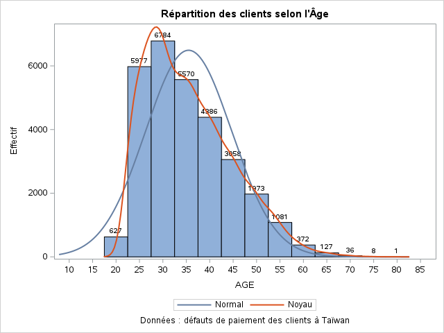

[figure not shown]

Répartition du Montant Maximum Accordé par Tranche d'Âge

La procédure CORR

| 25 Variables : | ID LIMIT_BAL SEX EDUCATION MARRIAGE AGE PAY_0 PAY_2 PAY_3 PAY_4 PAY_5 PAY_6 BILL_AMT1 BILL_AMT2 BILL_AMT3 BILL_AMT4 BILL_AMT5 BILL_AMT6 PAY_AMT1 PAY_AMT2 PAY_AMT3 PAY_AMT4 PAY_AMT5 PAY_AMT6 defaultpay… |
| --- | --- |

| Statistiques simples Variable | Statistiques simples N | Statistiques simples Moyenne | Statistiques simples Ec-type | Statistiques simples Somme | Statistiques simples Minimum | Statistiques simples Maximum | Statistiques simples Libellé |
| --- | --- | --- | --- | --- | --- | --- | --- |
| ID | 30000 | 15001 | 8660 | 450015000 | 1.00000 | 30000 | ID |
| LIMIT_BAL | 30000 | 167484 | 129748 | 5024529680 | 10000 | 1000000 | LIMIT_BAL |
| SEX | 30000 | 1.60373 | 0.48913 | 48112 | 1.00000 | 2.00000 | SEX |
| EDUCATION | 30000 | 1.85313 | 0.79035 | 55594 | 0 | 6.00000 | EDUCATION |
| MARRIAGE | 30000 | 1.55187 | 0.52197 | 46556 | 0 | 3.00000 | MARRIAGE |
| AGE | 30000 | 35.48550 | 9.21790 | 1064565 | 21.00000 | 79.00000 | AGE |
| PAY_0 | 30000 | -0.01670 | 1.12380 | -501.00000 | -2.00000 | 8.00000 | PAY_0 |
| PAY_2 | 30000 | -0.13377 | 1.19719 | -4013 | -2.00000 | 8.00000 | PAY_2 |
| PAY_3 | 30000 | -0.16620 | 1.19687 | -4986 | -2.00000 | 8.00000 | PAY_3 |
| PAY_4 | 30000 | -0.22067 | 1.16914 | -6620 | -2.00000 | 8.00000 | PAY_4 |
| PAY_5 | 30000 | -0.26620 | 1.13319 | -7986 | -2.00000 | 8.00000 | PAY_5 |
| PAY_6 | 30000 | -0.29110 | 1.14999 | -8733 | -2.00000 | 8.00000 | PAY_6 |
| BILL_AMT1 | 30000 | 51223 | 73636 | 1536699927 | -165580 | 964511 | BILL_AMT1 |
| BILL_AMT2 | 30000 | 49179 | 71174 | 1475372255 | -69777 | 983931 | BILL_AMT2 |
| BILL_AMT3 | 30000 | 47013 | 69349 | 1410394644 | -157264 | 1664089 | BILL_AMT3 |
| BILL_AMT4 | 30000 | 43263 | 64333 | 1297888469 | -170000 | 891586 | BILL_AMT4 |
| BILL_AMT5 | 30000 | 40311 | 60797 | 1209342029 | -81334 | 927171 | BILL_AMT5 |
| BILL_AMT6 | 30000 | 38872 | 59554 | 1166152812 | -339603 | 961664 | BILL_AMT6 |
| PAY_AMT1 | 30000 | 5664 | 16563 | 169907415 | 0 | 873552 | PAY_AMT1 |
| PAY_AMT2 | 30000 | 5921 | 23041 | 177634905 | 0 | 1684259 | PAY_AMT2 |
| PAY_AMT3 | 30000 | 5226 | 17607 | 156770445 | 0 | 896040 | PAY_AMT3 |
| PAY_AMT4 | 30000 | 4826 | 15666 | 144782306 | 0 | 621000 | PAY_AMT4 |
| PAY_AMT5 | 30000 | 4799 | 15278 | 143981629 | 0 | 426529 | PAY_AMT5 |
| PAY_AMT6 | 30000 | 5216 | 17777 | 156465077 | 0 | 528666 | PAY_AMT6 |
| defaultpayment | 30000 | 0.22120 | 0.41506 | 6636 | 0 | 1.00000 | defaultpayment |

| Coefficients de corrélation de Pearson, N = 30000 Proba > \|r\| sous H0: Rho=0 | Coefficients de corrélation de Pearson, N = 30000 Proba > \|r\| sous H0: Rho=0 ID | Coefficients de corrélation de Pearson, N = 30000 Proba > \|r\| sous H0: Rho=0 LIMIT_BAL | Coefficients de corrélation de Pearson, N = 30000 Proba > \|r\| sous H0: Rho=0 SEX | Coefficients de corrélation de Pearson, N = 30000 Proba > \|r\| sous H0: Rho=0 EDUCATION | Coefficients de corrélation de Pearson, N = 30000 Proba > \|r\| sous H0: Rho=0 MARRIAGE | Coefficients de corrélation de Pearson, N = 30000 Proba > \|r\| sous H0: Rho=0 AGE | Coefficients de corrélation de Pearson, N = 30000 Proba > \|r\| sous H0: Rho=0 PAY_0 | Coefficients de corrélation de Pearson, N = 30000 Proba > \|r\| sous H0: Rho=0 PAY_2 | Coefficients de corrélation de Pearson, N = 30000 Proba > \|r\| sous H0: Rho=0 PAY_3 | Coefficients de corrélation de Pearson, N = 30000 Proba > \|r\| sous H0: Rho=0 PAY_4 | Coefficients de corrélation de Pearson, N = 30000 Proba > \|r\| sous H0: Rho=0 PAY_5 | Coefficients de corrélation de Pearson, N = 30000 Proba > \|r\| sous H0: Rho=0 PAY_6 | Coefficients de corrélation de Pearson, N = 30000 Proba > \|r\| sous H0: Rho=0 BILL_AMT1 | Coefficients de corrélation de Pearson, N = 30000 Proba > \|r\| sous H0: Rho=0 BILL_AMT2 | Coefficients de corrélation de Pearson, N = 30000 Proba > \|r\| sous H0: Rho=0 BILL_AMT3 | Coefficients de corrélation de Pearson, N = 30000 Proba > \|r\| sous H0: Rho=0 BILL_AMT4 | Coefficients de corrélation de Pearson, N = 30000 Proba > \|r\| sous H0: Rho=0 BILL_AMT5 | Coefficients de corrélation de Pearson, N = 30000 Proba > \|r\| sous H0: Rho=0 BILL_AMT6 | Coefficients de corrélation de Pearson, N = 30000 Proba > \|r\| sous H0: Rho=0 PAY_AMT1 | Coefficients de corrélation de Pearson, N = 30000 Proba > \|r\| sous H0: Rho=0 PAY_AMT2 | Coefficients de corrélation de Pearson, N = 30000 Proba > \|r\| sous H0: Rho=0 PAY_AMT3 | Coefficients de corrélation de Pearson, N = 30000 Proba > \|r\| sous H0: Rho=0 PAY_AMT4 | Coefficients de corrélation de Pearson, N = 30000 Proba > \|r\| sous H0: Rho=0 PAY_AMT5 | Coefficients de corrélation de Pearson, N = 30000 Proba > \|r\| sous H0: Rho=0 PAY_AMT6 | Coefficients de corrélation de Pearson, N = 30000 Proba > \|r\| sous H0: Rho=0 defaultpayment |
| --- | --- | --- | --- | --- | --- | --- | --- | --- | --- | --- | --- | --- | --- | --- | --- | --- | --- | --- | --- | --- | --- | --- | --- | --- | --- |
| ID ID | 1.00000 | 0.02618 <.0001 | 0.01850 0.0014 | 0.03918 <.0001 | -0.02908 <.0001 | 0.01868 0.0012 | -0.03057 <.0001 | -0.01121 0.0521 | -0.01849 0.0014 | -0.00273 0.6357 | -0.02220 0.0001 | -0.02027 0.0004 | 0.01939 0.0008 | 0.01798 0.0018 | 0.02435 <.0001 | 0.04035 <.0001 | 0.01671 0.0038 | 0.01673 0.0038 | 0.00974 0.0915 | 0.00841 0.1454 | 0.03915 <.0001 | 0.00779 0.1771 | 0.00065 0.9101 | 0.00300 0.6034 | -0.01395 0.0157 |
| LIMIT_BAL LIMIT_BAL | 0.02618 <.0001 | 1.00000 | 0.02476 <.0001 | -0.21916 <.0001 | -0.10814 <.0001 | 0.14471 <.0001 | -0.27121 <.0001 | -0.29638 <.0001 | -0.28612 <.0001 | -0.26746 <.0001 | -0.24941 <.0001 | -0.23520 <.0001 | 0.28543 <.0001 | 0.27831 <.0001 | 0.28324 <.0001 | 0.29399 <.0001 | 0.29556 <.0001 | 0.29039 <.0001 | 0.19524 <.0001 | 0.17841 <.0001 | 0.21017 <.0001 | 0.20324 <.0001 | 0.21720 <.0001 | 0.21960 <.0001 | -0.15352 <.0001 |
| SEX SEX | 0.01850 0.0014 | 0.02476 <.0001 | 1.00000 | 0.01423 0.0137 | -0.03139 <.0001 | -0.09087 <.0001 | -0.05764 <.0001 | -0.07077 <.0001 | -0.06610 <.0001 | -0.06017 <.0001 | -0.05506 <.0001 | -0.04401 <.0001 | -0.03364 <.0001 | -0.03118 <.0001 | -0.02456 <.0001 | -0.02188 0.0002 | -0.01701 0.0032 | -0.01673 0.0038 | -0.00024 0.9665 | -0.00139 0.8096 | -0.00860 0.1365 | -0.00223 0.6995 | -0.00167 0.7728 | -0.00277 0.6319 | -0.03996 <.0001 |
| EDUCATION EDUCATION | 0.03918 <.0001 | -0.21916 <.0001 | 0.01423 0.0137 | 1.00000 | -0.14346 <.0001 | 0.17506 <.0001 | 0.10536 <.0001 | 0.12157 <.0001 | 0.11402 <.0001 | 0.10879 <.0001 | 0.09752 <.0001 | 0.08232 <.0001 | 0.02358 <.0001 | 0.01875 0.0012 | 0.01300 0.0243 | -0.00045 0.9377 | -0.00757 0.1900 | -0.00910 0.1150 | -0.03746 <.0001 | -0.03004 <.0001 | -0.03994 <.0001 | -0.03822 <.0001 | -0.04036 <.0001 | -0.03720 <.0001 | 0.02801 <.0001 |
| MARRIAGE MARRIAGE | -0.02908 <.0001 | -0.10814 <.0001 | -0.03139 <.0001 | -0.14346 <.0001 | 1.00000 | -0.41417 <.0001 | 0.01992 0.0006 | 0.02420 <.0001 | 0.03269 <.0001 | 0.03312 <.0001 | 0.03563 <.0001 | 0.03434 <.0001 | -0.02347 <.0001 | -0.02160 0.0002 | -0.02491 <.0001 | -0.02334 <.0001 | -0.02539 <.0001 | -0.02121 0.0002 | -0.00598 0.3004 | -0.00809 0.1610 | -0.00354 0.5396 | -0.01266 0.0283 | -0.00120 0.8347 | -0.00664 0.2501 | -0.02434 <.0001 |
| AGE AGE | 0.01868 0.0012 | 0.14471 <.0001 | -0.09087 <.0001 | 0.17506 <.0001 | -0.41417 <.0001 | 1.00000 | -0.03945 <.0001 | -0.05015 <.0001 | -0.05305 <.0001 | -0.04972 <.0001 | -0.05383 <.0001 | -0.04877 <.0001 | 0.05624 <.0001 | 0.05428 <.0001 | 0.05371 <.0001 | 0.05135 <.0001 | 0.04935 <.0001 | 0.04761 <.0001 | 0.02615 <.0001 | 0.02178 0.0002 | 0.02925 <.0001 | 0.02138 0.0002 | 0.02285 <.0001 | 0.01948 0.0007 | 0.01389 0.0161 |
| PAY_0 PAY_0 | -0.03057 <.0001 | -0.27121 <.0001 | -0.05764 <.0001 | 0.10536 <.0001 | 0.01992 0.0006 | -0.03945 <.0001 | 1.00000 | 0.67216 <.0001 | 0.57425 <.0001 | 0.53884 <.0001 | 0.50943 <.0001 | 0.47455 <.0001 | 0.18707 <.0001 | 0.18986 <.0001 | 0.17979 <.0001 | 0.17912 <.0001 | 0.18063 <.0001 | 0.17698 <.0001 | -0.07927 <.0001 | -0.07010 <.0001 | -0.07056 <.0001 | -0.06400 <.0001 | -0.05819 <.0001 | -0.05867 <.0001 | 0.32479 <.0001 |
| PAY_2 PAY_2 | -0.01121 0.0521 | -0.29638 <.0001 | -0.07077 <.0001 | 0.12157 <.0001 | 0.02420 <.0001 | -0.05015 <.0001 | 0.67216 <.0001 | 1.00000 | 0.76655 <.0001 | 0.66207 <.0001 | 0.62278 <.0001 | 0.57550 <.0001 | 0.23489 <.0001 | 0.23526 <.0001 | 0.22415 <.0001 | 0.22224 <.0001 | 0.22135 <.0001 | 0.21940 <.0001 | -0.08070 <.0001 | -0.05899 <.0001 | -0.05590 <.0001 | -0.04686 <.0001 | -0.03709 <.0001 | -0.03650 <.0001 | 0.26355 <.0001 |
| PAY_3 PAY_3 | -0.01849 0.0014 | -0.28612 <.0001 | -0.06610 <.0001 | 0.11402 <.0001 | 0.03269 <.0001 | -0.05305 <.0001 | 0.57425 <.0001 | 0.76655 <.0001 | 1.00000 | 0.77736 <.0001 | 0.68677 <.0001 | 0.63268 <.0001 | 0.20847 <.0001 | 0.23729 <.0001 | 0.22749 <.0001 | 0.22720 <.0001 | 0.22515 <.0001 | 0.22233 <.0001 | 0.00129 0.8226 | -0.06679 <.0001 | -0.05331 <.0001 | -0.04607 <.0001 | -0.03586 <.0001 | -0.03586 <.0001 | 0.23525 <.0001 |
| PAY_4 PAY_4 | -0.00273 0.6357 | -0.26746 <.0001 | -0.06017 <.0001 | 0.10879 <.0001 | 0.03312 <.0001 | -0.04972 <.0001 | 0.53884 <.0001 | 0.66207 <.0001 | 0.77736 <.0001 | 1.00000 | 0.81984 <.0001 | 0.71645 <.0001 | 0.20281 <.0001 | 0.22582 <.0001 | 0.24498 <.0001 | 0.24592 <.0001 | 0.24290 <.0001 | 0.23915 <.0001 | -0.00936 0.1049 | -0.00194 0.7364 | -0.06924 <.0001 | -0.04346 <.0001 | -0.03359 <.0001 | -0.02657 <.0001 | 0.21661 <.0001 |
| PAY_5 PAY_5 | -0.02220 0.0001 | -0.24941 <.0001 | -0.05506 <.0001 | 0.09752 <.0001 | 0.03563 <.0001 | -0.05383 <.0001 | 0.50943 <.0001 | 0.62278 <.0001 | 0.68677 <.0001 | 0.81984 <.0001 | 1.00000 | 0.81690 <.0001 | 0.20668 <.0001 | 0.22691 <.0001 | 0.24333 <.0001 | 0.27192 <.0001 | 0.26978 <.0001 | 0.26251 <.0001 | -0.00609 0.2916 | -0.00319 0.5804 | 0.00906 0.1165 | -0.05830 <.0001 | -0.03334 <.0001 | -0.02303 <.0001 | 0.20415 <.0001 |
| PAY_6 PAY_6 | -0.02027 0.0004 | -0.23520 <.0001 | -0.04401 <.0001 | 0.08232 <.0001 | 0.03434 <.0001 | -0.04877 <.0001 | 0.47455 <.0001 | 0.57550 <.0001 | 0.63268 <.0001 | 0.71645 <.0001 | 0.81690 <.0001 | 1.00000 | 0.20737 <.0001 | 0.22692 <.0001 | 0.24118 <.0001 | 0.26636 <.0001 | 0.29089 <.0001 | 0.28509 <.0001 | -0.00150 0.7955 | -0.00522 0.3656 | 0.00583 0.3123 | 0.01902 0.0010 | -0.04643 <.0001 | -0.02530 <.0001 | 0.18687 <.0001 |
| BILL_AMT1 BILL_AMT1 | 0.01939 0.0008 | 0.28543 <.0001 | -0.03364 <.0001 | 0.02358 <.0001 | -0.02347 <.0001 | 0.05624 <.0001 | 0.18707 <.0001 | 0.23489 <.0001 | 0.20847 <.0001 | 0.20281 <.0001 | 0.20668 <.0001 | 0.20737 <.0001 | 1.00000 | 0.95148 <.0001 | 0.89228 <.0001 | 0.86027 <.0001 | 0.82978 <.0001 | 0.80265 <.0001 | 0.14028 <.0001 | 0.09936 <.0001 | 0.15689 <.0001 | 0.15830 <.0001 | 0.16703 <.0001 | 0.17934 <.0001 | -0.01964 0.0007 |
| BILL_AMT2 BILL_AMT2 | 0.01798 0.0018 | 0.27831 <.0001 | -0.03118 <.0001 | 0.01875 0.0012 | -0.02160 0.0002 | 0.05428 <.0001 | 0.18986 <.0001 | 0.23526 <.0001 | 0.23729 <.0001 | 0.22582 <.0001 | 0.22691 <.0001 | 0.22692 <.0001 | 0.95148 <.0001 | 1.00000 | 0.92833 <.0001 | 0.89248 <.0001 | 0.85978 <.0001 | 0.83159 <.0001 | 0.28037 <.0001 | 0.10085 <.0001 | 0.15072 <.0001 | 0.14740 <.0001 | 0.15796 <.0001 | 0.17426 <.0001 | -0.01419 0.0140 |
| BILL_AMT3 BILL_AMT3 | 0.02435 <.0001 | 0.28324 <.0001 | -0.02456 <.0001 | 0.01300 0.0243 | -0.02491 <.0001 | 0.05371 <.0001 | 0.17979 <.0001 | 0.22415 <.0001 | 0.22749 <.0001 | 0.24498 <.0001 | 0.24333 <.0001 | 0.24118 <.0001 | 0.89228 <.0001 | 0.92833 <.0001 | 1.00000 | 0.92397 <.0001 | 0.88391 <.0001 | 0.85332 <.0001 | 0.24434 <.0001 | 0.31694 <.0001 | 0.13001 <.0001 | 0.14340 <.0001 | 0.17971 <.0001 | 0.18233 <.0001 | -0.01408 0.0148 |
| BILL_AMT4 BILL_AMT4 | 0.04035 <.0001 | 0.29399 <.0001 | -0.02188 0.0002 | -0.00045 0.9377 | -0.02334 <.0001 | 0.05135 <.0001 | 0.17912 <.0001 | 0.22224 <.0001 | 0.22720 <.0001 | 0.24592 <.0001 | 0.27192 <.0001 | 0.26636 <.0001 | 0.86027 <.0001 | 0.89248 <.0001 | 0.92397 <.0001 | 1.00000 | 0.94013 <.0001 | 0.90094 <.0001 | 0.23301 <.0001 | 0.20756 <.0001 | 0.30002 <.0001 | 0.13019 <.0001 | 0.16043 <.0001 | 0.17764 <.0001 | -0.01016 0.0786 |
| BILL_AMT5 BILL_AMT5 | 0.01671 0.0038 | 0.29556 <.0001 | -0.01701 0.0032 | -0.00757 0.1900 | -0.02539 <.0001 | 0.04935 <.0001 | 0.18063 <.0001 | 0.22135 <.0001 | 0.22515 <.0001 | 0.24290 <.0001 | 0.26978 <.0001 | 0.29089 <.0001 | 0.82978 <.0001 | 0.85978 <.0001 | 0.88391 <.0001 | 0.94013 <.0001 | 1.00000 | 0.94620 <.0001 | 0.21703 <.0001 | 0.18125 <.0001 | 0.25230 <.0001 | 0.29312 <.0001 | 0.14157 <.0001 | 0.16418 <.0001 | -0.00676 0.2416 |
| BILL_AMT6 BILL_AMT6 | 0.01673 0.0038 | 0.29039 <.0001 | -0.01673 0.0038 | -0.00910 0.1150 | -0.02121 0.0002 | 0.04761 <.0001 | 0.17698 <.0001 | 0.21940 <.0001 | 0.22233 <.0001 | 0.23915 <.0001 | 0.26251 <.0001 | 0.28509 <.0001 | 0.80265 <.0001 | 0.83159 <.0001 | 0.85332 <.0001 | 0.90094 <.0001 | 0.94620 <.0001 | 1.00000 | 0.19997 <.0001 | 0.17266 <.0001 | 0.23377 <.0001 | 0.25024 <.0001 | 0.30773 <.0001 | 0.11549 <.0001 | -0.00537 0.3521 |
| PAY_AMT1 PAY_AMT1 | 0.00974 0.0915 | 0.19524 <.0001 | -0.00024 0.9665 | -0.03746 <.0001 | -0.00598 0.3004 | 0.02615 <.0001 | -0.07927 <.0001 | -0.08070 <.0001 | 0.00129 0.8226 | -0.00936 0.1049 | -0.00609 0.2916 | -0.00150 0.7955 | 0.14028 <.0001 | 0.28037 <.0001 | 0.24434 <.0001 | 0.23301 <.0001 | 0.21703 <.0001 | 0.19997 <.0001 | 1.00000 | 0.28558 <.0001 | 0.25219 <.0001 | 0.19956 <.0001 | 0.14846 <.0001 | 0.18574 <.0001 | -0.07293 <.0001 |
| PAY_AMT2 PAY_AMT2 | 0.00841 0.1454 | 0.17841 <.0001 | -0.00139 0.8096 | -0.03004 <.0001 | -0.00809 0.1610 | 0.02178 0.0002 | -0.07010 <.0001 | -0.05899 <.0001 | -0.06679 <.0001 | -0.00194 0.7364 | -0.00319 0.5804 | -0.00522 0.3656 | 0.09936 <.0001 | 0.10085 <.0001 | 0.31694 <.0001 | 0.20756 <.0001 | 0.18125 <.0001 | 0.17266 <.0001 | 0.28558 <.0001 | 1.00000 | 0.24477 <.0001 | 0.18011 <.0001 | 0.18091 <.0001 | 0.15763 <.0001 | -0.05858 <.0001 |
| PAY_AMT3 PAY_AMT3 | 0.03915 <.0001 | 0.21017 <.0001 | -0.00860 0.1365 | -0.03994 <.0001 | -0.00354 0.5396 | 0.02925 <.0001 | -0.07056 <.0001 | -0.05590 <.0001 | -0.05331 <.0001 | -0.06924 <.0001 | 0.00906 0.1165 | 0.00583 0.3123 | 0.15689 <.0001 | 0.15072 <.0001 | 0.13001 <.0001 | 0.30002 <.0001 | 0.25230 <.0001 | 0.23377 <.0001 | 0.25219 <.0001 | 0.24477 <.0001 | 1.00000 | 0.21633 <.0001 | 0.15921 <.0001 | 0.16274 <.0001 | -0.05625 <.0001 |
| PAY_AMT4 PAY_AMT4 | 0.00779 0.1771 | 0.20324 <.0001 | -0.00223 0.6995 | -0.03822 <.0001 | -0.01266 0.0283 | 0.02138 0.0002 | -0.06400 <.0001 | -0.04686 <.0001 | -0.04607 <.0001 | -0.04346 <.0001 | -0.05830 <.0001 | 0.01902 0.0010 | 0.15830 <.0001 | 0.14740 <.0001 | 0.14340 <.0001 | 0.13019 <.0001 | 0.29312 <.0001 | 0.25024 <.0001 | 0.19956 <.0001 | 0.18011 <.0001 | 0.21633 <.0001 | 1.00000 | 0.15183 <.0001 | 0.15783 <.0001 | -0.05683 <.0001 |
| PAY_AMT5 PAY_AMT5 | 0.00065 0.9101 | 0.21720 <.0001 | -0.00167 0.7728 | -0.04036 <.0001 | -0.00120 0.8347 | 0.02285 <.0001 | -0.05819 <.0001 | -0.03709 <.0001 | -0.03586 <.0001 | -0.03359 <.0001 | -0.03334 <.0001 | -0.04643 <.0001 | 0.16703 <.0001 | 0.15796 <.0001 | 0.17971 <.0001 | 0.16043 <.0001 | 0.14157 <.0001 | 0.30773 <.0001 | 0.14846 <.0001 | 0.18091 <.0001 | 0.15921 <.0001 | 0.15183 <.0001 | 1.00000 | 0.15490 <.0001 | -0.05512 <.0001 |
| PAY_AMT6 PAY_AMT6 | 0.00300 0.6034 | 0.21960 <.0001 | -0.00277 0.6319 | -0.03720 <.0001 | -0.00664 0.2501 | 0.01948 0.0007 | -0.05867 <.0001 | -0.03650 <.0001 | -0.03586 <.0001 | -0.02657 <.0001 | -0.02303 <.0001 | -0.02530 <.0001 | 0.17934 <.0001 | 0.17426 <.0001 | 0.18233 <.0001 | 0.17764 <.0001 | 0.16418 <.0001 | 0.11549 <.0001 | 0.18574 <.0001 | 0.15763 <.0001 | 0.16274 <.0001 | 0.15783 <.0001 | 0.15490 <.0001 | 1.00000 | -0.05318 <.0001 |
| defaultpayment defaultpayment | -0.01395 0.0157 | -0.15352 <.0001 | -0.03996 <.0001 | 0.02801 <.0001 | -0.02434 <.0001 | 0.01389 0.0161 | 0.32479 <.0001 | 0.26355 <.0001 | 0.23525 <.0001 | 0.21661 <.0001 | 0.20415 <.0001 | 0.18687 <.0001 | -0.01964 0.0007 | -0.01419 0.0140 | -0.01408 0.0148 | -0.01016 0.0786 | -0.00676 0.2416 | -0.00537 0.3521 | -0.07293 <.0001 | -0.05858 <.0001 | -0.05625 <.0001 | -0.05683 <.0001 | -0.05512 <.0001 | -0.05318 <.0001 | 1.00000 |

Données : défauts de paiement des clients à Taïwan

La procédure REG

Modèle : MODEL1

Variable dépendante : defaultpayment defaultpayment

| Nb d'observations lues | 30000 |
| --- | --- |
| Nb d'obs. utilisées | 30000 |

| Analyse de variance Source | Analyse de variance DDL | Analyse de variance Somme des carrés | Analyse de variance Moyenne quadratique | Analyse de variance Valeur F | Analyse de variance Pr > F |
| --- | --- | --- | --- | --- | --- |
| Modèle | 3 | 12.61991 | 4.20664 | 24.48 | <.0001 |
| Erreur | 29996 | 5155.49689 | 0.17187 |  |  |
| Total sommes corrigées | 29999 | 5168.11680 |  |  |  |

| Root MSE | 0.41458 | R carré | 0.0024 |
| --- | --- | --- | --- |
| Moyenne dépendante | 0.22120 | R car. ajust. | 0.0023 |
| Coeff Var | 187.42109 |  |  |

| Paramètres estimés Variable | Paramètres estimés Libellé | Paramètres estimés DDL | Paramètres estimés Valeur estimée des paramètres | Paramètres estimés Erreur type | Paramètres estimés Valeur du test t | Paramètres estimés Pr > \|t\| |
| --- | --- | --- | --- | --- | --- | --- |
| Intercept | Intercept | 1 | 0.23988 | 0.01346 | 17.83 | <.0001 |
| AGE | AGE | 1 | 0.00024459 | 0.00026493 | 0.92 | 0.3559 |
| SEX | SEX | 1 | -0.03382 | 0.00492 | -6.88 | <.0001 |
| EDUCATION | EDUCATION | 1 | 0.01451 | 0.00308 | 4.71 | <.0001 |

La procédure REG

Modèle : MODEL1

Variable dépendante : defaultpayment defaultpayment

| Durbin-Watson D | 2.000 |
| --- | --- |
| Nombre d'observations | 30000 |
| Autocorrélation de 1er ordre | -0.000 |

La procédure REG

Modèle : MODEL1

Variable dépendante : defaultpayment defaultpayment

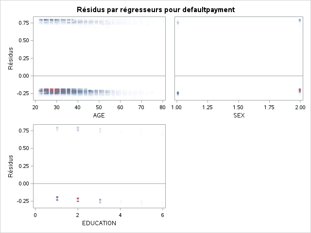

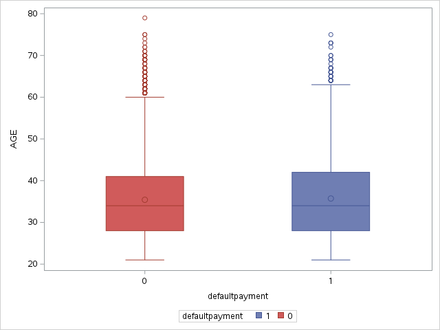

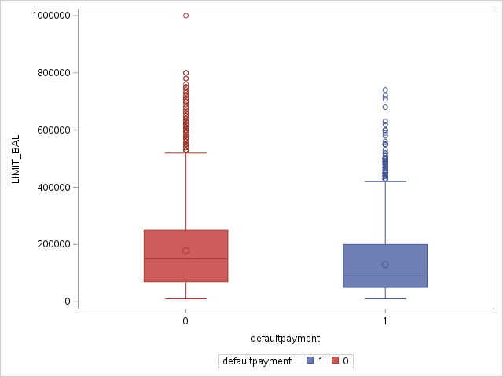

Tableau croisé des variables

[output not shown]

Données : défauts de paiement des clients à Taïwan

Tableau croisé des variables

[output not shown]

Données : défauts de paiement des clients à Taïwan

Tableau croisé des variables

[output not shown]

Données : défauts de paiement des clients à Taïwan

Tableau croisé des variables

[output not shown]

Données : défauts de paiement des clients à Taïwan

Tableau croisé des variables

La procédure FREQ

| Fréquence Pourcentage Pct de ligne Pct de col. |
| --- |

| Table de SEX par defaultpayment SEX(SEX) | Table de SEX par defaultpayment defaultpayment(defaultpayment) 0 | Table de SEX par defaultpayment defaultpayment(defaultpayment) 1 | Table de SEX par defaultpayment defaultpayment(defaultpayment) Total |
| --- | --- | --- | --- |
| 1 | 9015 30.05 75.83 38.59 | 2873 9.58 24.17 43.29 | 11888 39.63 |
| 2 | 14349 47.83 79.22 61.41 | 3763 12.54 20.78 56.71 | 18112 60.37 |
| Total | 23364 77.88 | 6636 22.12 | 30000 100.00 |

Statistiques pour la table de SEX par defaultpayment

| Statistique | DDL | Valeur | Prob |
| --- | --- | --- | --- |
| Khi-2 | 1 | 47.9054 | <.0001 |
| Test du rapport de vraisemblance | 1 | 47.5827 | <.0001 |
| Khi-2 continuité ajustée | 1 | 47.7088 | <.0001 |
| Khi-2 de Mantel-Haenszel | 1 | 47.9038 | <.0001 |
| Coefficient Phi |  | -0.0400 |  |
| Coefficient de contingence |  | 0.0399 |  |
| V de Cramer |  | -0.0400 |  |

| Test exact de Fisher |  |
| --- | --- |
| Cellule (1,1) Fréquence (F) | 9015 |
| Pr <= F unilatérale à gauche | <.0001 |
| Pr >= F unilatérale à droite | 1.0000 |
| Probabilité de la table (P) | <.0001 |
| Pr <= P bilatéral | <.0001 |

Taille de l'échantillon = 30000

Données : défauts de paiement des clients à Taïwan

Tableau croisé des variables

La procédure FREQ

| Fréquence Pourcentage Pct de ligne Pct de col. |
| --- |

| Table de AGE par defaultpayment AGE(AGE) | Table de AGE par defaultpayment defaultpayment(defaultpayment) 0 | Table de AGE par defaultpayment defaultpayment(defaultpayment) 1 | Table de AGE par defaultpayment defaultpayment(defaultpayment) Total |
| --- | --- | --- | --- |
| 21 | 53 0.18 79.10 0.23 | 14 0.05 20.90 0.21 | 67 0.22 |
| 22 | 391 1.30 69.82 1.67 | 169 0.56 30.18 2.55 | 560 1.87 |
| 23 | 684 2.28 73.47 2.93 | 247 0.82 26.53 3.72 | 931 3.10 |
| 24 | 827 2.76 73.38 3.54 | 300 1.00 26.62 4.52 | 1127 3.76 |
| 25 | 884 2.95 74.54 3.78 | 302 1.01 25.46 4.55 | 1186 3.95 |
| 26 | 1003 3.34 79.86 4.29 | 253 0.84 20.14 3.81 | 1256 4.19 |
| 27 | 1164 3.88 78.81 4.98 | 313 1.04 21.19 4.72 | 1477 4.92 |
| 28 | 1123 3.74 79.70 4.81 | 286 0.95 20.30 4.31 | 1409 4.70 |
| 29 | 1292 4.31 80.50 5.53 | 313 1.04 19.50 4.72 | 1605 5.35 |
| 30 | 1121 3.74 80.36 4.80 | 274 0.91 19.64 4.13 | 1395 4.65 |
| 31 | 988 3.29 81.18 4.23 | 229 0.76 18.82 3.45 | 1217 4.06 |
| 32 | 933 3.11 80.57 3.99 | 225 0.75 19.43 3.39 | 1158 3.86 |
| 33 | 931 3.10 81.24 3.98 | 215 0.72 18.76 3.24 | 1146 3.82 |
| 34 | 931 3.10 80.12 3.98 | 231 0.77 19.88 3.48 | 1162 3.87 |
| 35 | 887 2.96 79.69 3.80 | 226 0.75 20.31 3.41 | 1113 3.71 |
| 36 | 854 2.85 77.08 3.66 | 254 0.85 22.92 3.83 | 1108 3.69 |
| 37 | 812 2.71 78.00 3.48 | 229 0.76 22.00 3.45 | 1041 3.47 |
| 38 | 750 2.50 79.45 3.21 | 194 0.65 20.55 2.92 | 944 3.15 |
| 39 | 755 2.52 79.14 3.23 | 199 0.66 20.86 3.00 | 954 3.18 |
| 40 | 683 2.28 78.51 2.92 | 187 0.62 21.49 2.82 | 870 2.90 |
| 41 | 639 2.13 77.55 2.73 | 185 0.62 22.45 2.79 | 824 2.75 |
| 42 | 609 2.03 76.70 2.61 | 185 0.62 23.30 2.79 | 794 2.65 |
| 43 | 520 1.73 77.61 2.23 | 150 0.50 22.39 2.26 | 670 2.23 |
| 44 | 538 1.79 76.86 2.30 | 162 0.54 23.14 2.44 | 700 2.33 |
| 45 | 501 1.67 81.20 2.14 | 116 0.39 18.80 1.75 | 617 2.06 |
| 46 | 413 1.38 72.46 1.77 | 157 0.52 27.54 2.37 | 570 1.90 |
| 47 | 381 1.27 76.05 1.63 | 120 0.40 23.95 1.81 | 501 1.67 |
| 48 | 362 1.21 77.68 1.55 | 104 0.35 22.32 1.57 | 466 1.55 |
| 49 | 333 1.11 73.67 1.43 | 119 0.40 26.33 1.79 | 452 1.51 |
| 50 | 310 1.03 75.43 1.33 | 101 0.34 24.57 1.52 | 411 1.37 |
| 51 | 252 0.84 74.12 1.08 | 88 0.29 25.88 1.33 | 340 1.13 |
| 52 | 226 0.75 74.34 0.97 | 78 0.26 25.66 1.18 | 304 1.01 |
| 53 | 251 0.84 77.23 1.07 | 74 0.25 22.77 1.12 | 325 1.08 |
| 54 | 191 0.64 77.33 0.82 | 56 0.19 22.67 0.84 | 247 0.82 |
| 55 | 152 0.51 72.73 0.65 | 57 0.19 27.27 0.86 | 209 0.70 |
| 56 | 129 0.43 72.47 0.55 | 49 0.16 27.53 0.74 | 178 0.59 |
| 57 | 95 0.32 77.87 0.41 | 27 0.09 22.13 0.41 | 122 0.41 |
| 58 | 91 0.30 74.59 0.39 | 31 0.10 25.41 0.47 | 122 0.41 |
| 59 | 62 0.21 74.70 0.27 | 21 0.07 25.30 0.32 | 83 0.28 |
| 60 | 44 0.15 65.67 0.19 | 23 0.08 34.33 0.35 | 67 0.22 |
| 61 | 35 0.12 62.50 0.15 | 21 0.07 37.50 0.32 | 56 0.19 |
| 62 | 37 0.12 84.09 0.16 | 7 0.02 15.91 0.11 | 44 0.15 |
| 63 | 23 0.08 74.19 0.10 | 8 0.03 25.81 0.12 | 31 0.10 |
| 64 | 22 0.07 70.97 0.09 | 9 0.03 29.03 0.14 | 31 0.10 |
| 65 | 19 0.06 79.17 0.08 | 5 0.02 20.83 0.08 | 24 0.08 |
| 66 | 18 0.06 72.00 0.08 | 7 0.02 28.00 0.11 | 25 0.08 |
| 67 | 11 0.04 68.75 0.05 | 5 0.02 31.25 0.08 | 16 0.05 |
| 68 | 4 0.01 80.00 0.02 | 1 0.00 20.00 0.02 | 5 0.02 |
| 69 | 12 0.04 80.00 0.05 | 3 0.01 20.00 0.05 | 15 0.05 |
| 70 | 8 0.03 80.00 0.03 | 2 0.01 20.00 0.03 | 10 0.03 |
| 71 | 3 0.01 100.00 0.01 | 0 0.00 0.00 0.00 | 3 0.01 |
| 72 | 2 0.01 66.67 0.01 | 1 0.00 33.33 0.02 | 3 0.01 |
| 73 | 1 0.00 25.00 0.00 | 3 0.01 75.00 0.05 | 4 0.01 |
| 74 | 1 0.00 100.00 0.00 | 0 0.00 0.00 0.00 | 1 0.00 |
| 75 | 2 0.01 66.67 0.01 | 1 0.00 33.33 0.02 | 3 0.01 |
| 79 | 1 0.00 100.00 0.00 | 0 0.00 0.00 0.00 | 1 0.00 |
| Total | 23364 77.88 | 6636 22.12 | 30000 100.00 |

Statistiques pour la table de AGE par defaultpayment

| Statistique | DDL | Valeur | Prob |
| --- | --- | --- | --- |
| Khi-2 | 55 | 158.5529 | <.0001 |
| Test du rapport de vraisemblance | 55 | 153.9990 | <.0001 |
| Khi-2 de Mantel-Haenszel | 1 | 5.7876 | 0.0161 |
| Coefficient Phi |  | 0.0727 |  |
| Coefficient de contingence |  | 0.0725 |  |
| V de Cramer |  | 0.0727 |  |

Taille de l'échantillon = 30000

Données : défauts de paiement des clients à Taïwan

Tableau croisé des variables

La procédure FREQ

| Fréquence Pourcentage Pct de ligne Pct de col. |
| --- |

| Table de EDUCATION par defaultpayment EDUCATION(EDUCATION) | Table de EDUCATION par defaultpayment defaultpayment(defaultpayment) 0 | Table de EDUCATION par defaultpayment defaultpayment(defaultpayment) 1 | Table de EDUCATION par defaultpayment defaultpayment(defaultpayment) Total |
| --- | --- | --- | --- |
| 0 | 14 0.05 100.00 0.06 | 0 0.00 0.00 0.00 | 14 0.05 |
| 1 | 8549 28.50 80.77 36.59 | 2036 6.79 19.23 30.68 | 10585 35.28 |
| 2 | 10700 35.67 76.27 45.80 | 3330 11.10 23.73 50.18 | 14030 46.77 |
| 3 | 3680 12.27 74.84 15.75 | 1237 4.12 25.16 18.64 | 4917 16.39 |
| 4 | 116 0.39 94.31 0.50 | 7 0.02 5.69 0.11 | 123 0.41 |
| 5 | 262 0.87 93.57 1.12 | 18 0.06 6.43 0.27 | 280 0.93 |
| 6 | 43 0.14 84.31 0.18 | 8 0.03 15.69 0.12 | 51 0.17 |
| Total | 23364 77.88 | 6636 22.12 | 30000 100.00 |

Statistiques pour la table de EDUCATION par defaultpayment

| Statistique | DDL | Valeur | Prob |
| --- | --- | --- | --- |
| Khi-2 | 6 | 163.2166 | <.0001 |
| Test du rapport de vraisemblance | 6 | 184.7080 | <.0001 |
| Khi-2 de Mantel-Haenszel | 1 | 23.5294 | <.0001 |
| Coefficient Phi |  | 0.0738 |  |
| Coefficient de contingence |  | 0.0736 |  |
| V de Cramer |  | 0.0738 |  |

Taille de l'échantillon = 30000

Données : défauts de paiement des clients à Taïwan

Tableau croisé des variables

La procédure FREQ

| Fréquence Pourcentage Pct de ligne Pct de col. |
| --- |

| Table de MARRIAGE par defaultpayment MARRIAGE(MARRIAGE) | Table de MARRIAGE par defaultpayment defaultpayment(defaultpayment) 0 | Table de MARRIAGE par defaultpayment defaultpayment(defaultpayment) 1 | Table de MARRIAGE par defaultpayment defaultpayment(defaultpayment) Total |
| --- | --- | --- | --- |
| 0 | 49 0.16 90.74 0.21 | 5 0.02 9.26 0.08 | 54 0.18 |
| 1 | 10453 34.84 76.53 44.74 | 3206 10.69 23.47 48.31 | 13659 45.53 |
| 2 | 12623 42.08 79.07 54.03 | 3341 11.14 20.93 50.35 | 15964 53.21 |
| 3 | 239 0.80 73.99 1.02 | 84 0.28 26.01 1.27 | 323 1.08 |
| Total | 23364 77.88 | 6636 22.12 | 30000 100.00 |

Statistiques pour la table de MARRIAGE par defaultpayment

| Statistique | DDL | Valeur | Prob |
| --- | --- | --- | --- |
| Khi-2 | 3 | 35.6624 | <.0001 |
| Test du rapport de vraisemblance | 3 | 36.6092 | <.0001 |
| Khi-2 de Mantel-Haenszel | 1 | 17.7713 | <.0001 |
| Coefficient Phi |  | 0.0345 |  |
| Coefficient de contingence |  | 0.0345 |  |
| V de Cramer |  | 0.0345 |  |

Taille de l'échantillon = 30000

Données : défauts de paiement des clients à Taïwan

Tableau croisé des variables

La procédure UNIVARIATE

Variable : AGE (AGE)

| Moments |  |  |  |
| --- | --- | --- | --- |
| N | 30000 | Somme des poids | 30000 |
| Moyenne | 35.4855 | Somme des observations | 1064565 |
| Ecart-type | 9.21790407 | Variance | 84.9697554 |
| Skewness | 0.73224587 | Kurtosis | 0.04430338 |
| Somme des carrés non corrigée | 40325629 | Somme des carrés corrigée | 2549007.69 |
| Coeff Variation | 25.9765371 | Std Error Mean | 0.05321959 |

| Mesures statistiques de base Location | Mesures statistiques de base Location | Mesures statistiques de base Variabilité | Mesures statistiques de base Variabilité |
| --- | --- | --- | --- |
| Moyenne | 35.48550 | Ecart-type | 9.21790 |
| Médiane | 34.00000 | Variance | 84.96976 |
| Mode | 29.00000 | Intervalle | 58.00000 |
|  |  | Ecart interquartile | 13.00000 |

| Tests de tendance centrale : Mu0=0 Test | Tests de tendance centrale : Mu0=0 Statistique | Tests de tendance centrale : Mu0=0 Statistique | Tests de tendance centrale : Mu0=0 p-value | Tests de tendance centrale : Mu0=0 p-value |
| --- | --- | --- | --- | --- |
| t de Student | t | 666.7751 | Pr > \|t\| | <.0001 |
| Signe | M | 15000 | Pr >= \|M\| | <.0001 |
| Rang signé | S | 2.2501E8 | Pr >= \|S\| | <.0001 |

| Tests de normalité Test | Tests de normalité Statistique | Tests de normalité Statistique | Tests de normalité p-value | Tests de normalité p-value |
| --- | --- | --- | --- | --- |
| Kolmogorov-Smirnov | D | 0.094398 | Pr > D | <0.0100 |
| Cramer-von Mises | W-Sq | 62.75938 | Pr > W-Sq | <0.0050 |
| Anderson-Darling | A-Sq | 399.7678 | Pr > A-Sq | <0.0050 |

| Quantiles (Définition 5) Niveau | Quantiles (Définition 5) Quantile |
| --- | --- |
| 100Max 100% | 79 |
| 99% | 60 |
| 95% | 53 |
| 90% | 49 |
| 75% Q3 | 41 |
| 50% Médiane | 34 |
| 25% Q1 | 28 |
| 10% | 25 |
| 5% | 23 |
| 1% | 22 |
| 0% Min | 21 |

| Observations extrêmes La plus petite Valeur | Observations extrêmes La plus petite Obs | Observations extrêmes La plus grande Valeur | Observations extrêmes La plus grande Obs |
| --- | --- | --- | --- |
| 21 | 27663 | 74 | 29176 |
| 21 | 27631 | 75 | 247 |
| 21 | 25303 | 75 | 25137 |
| 21 | 25183 | 75 | 25142 |
| 21 | 25175 | 79 | 18246 |

Données : défauts de paiement des clients à Taïwan

Tableau croisé des variables

La procédure UNIVARIATE

Variable : LIMIT_BAL (LIMIT_BAL)

| Moments |  |  |  |
| --- | --- | --- | --- |
| N | 30000 | Somme des poids | 30000 |
| Moyenne | 167484.323 | Somme des observations | 5024529680 |
| Ecart-type | 129747.662 | Variance | 1.68345E10 |
| Skewness | 0.99286696 | Kurtosis | 0.5362629 |
| Somme des carrés non corrigée | 1.34655E15 | Somme des carrés corrigée | 5.05017E14 |
| Coeff Variation | 77.4685412 | Std Error Mean | 749.098473 |

| Mesures statistiques de base Location | Mesures statistiques de base Location | Mesures statistiques de base Variabilité | Mesures statistiques de base Variabilité |
| --- | --- | --- | --- |
| Moyenne | 167484.3 | Ecart-type | 129748 |
| Médiane | 140000.0 | Variance | 1.68345E10 |
| Mode | 50000.0 | Intervalle | 990000 |
|  |  | Ecart interquartile | 190000 |

| Tests de tendance centrale : Mu0=0 Test | Tests de tendance centrale : Mu0=0 Statistique | Tests de tendance centrale : Mu0=0 Statistique | Tests de tendance centrale : Mu0=0 p-value | Tests de tendance centrale : Mu0=0 p-value |
| --- | --- | --- | --- | --- |
| t de Student | t | 223.5812 | Pr > \|t\| | <.0001 |
| Signe | M | 15000 | Pr >= \|M\| | <.0001 |
| Rang signé | S | 2.2501E8 | Pr >= \|S\| | <.0001 |

| Tests de normalité Test | Tests de normalité Statistique | Tests de normalité Statistique | Tests de normalité p-value | Tests de normalité p-value |
| --- | --- | --- | --- | --- |
| Kolmogorov-Smirnov | D | 0.11511 | Pr > D | <0.0100 |
| Cramer-von Mises | W-Sq | 117.6357 | Pr > W-Sq | <0.0050 |
| Anderson-Darling | A-Sq | 774.3814 | Pr > A-Sq | <0.0050 |

| Quantiles (Définition 5) Niveau | Quantiles (Définition 5) Quantile |
| --- | --- |
| 100Max 100% | 1000000 |
| 99% | 500000 |
| 95% | 430000 |
| 90% | 360000 |
| 75% Q3 | 240000 |
| 50% Médiane | 140000 |
| 25% Q1 | 50000 |
| 10% | 30000 |
| 5% | 20000 |
| 1% | 10000 |
| 0% Min | 10000 |

| Observations extrêmes La plus petite Valeur | Observations extrêmes La plus petite Obs | Observations extrêmes La plus grande Valeur | Observations extrêmes La plus grande Obs |
| --- | --- | --- | --- |
| 10000 | 29993 | 780000 | 24321 |
| 10000 | 29961 | 780000 | 28716 |
| 10000 | 29916 | 800000 | 14920 |
| 10000 | 29871 | 800000 | 18007 |
| 10000 | 29846 | 1000000 | 2198 |

Données : défauts de paiement des clients à Taïwan

Tableau croisé des variables

La procédure TTEST

Variable : AGE (AGE)

| N | Moyenne | Ec-type | Err. type | Minimum | Maximum |
| --- | --- | --- | --- | --- | --- |
| 30000 | 35.4855 | 9.2179 | 0.0532 | 21.0000 | 79.0000 |

| Moyenne | IC à95% - Moyenne |  | Ec-type | Ec.-type de l'IC à95% |  |
| --- | --- | --- | --- | --- | --- |
| 35.4855 | 35.3812 | 35.5898 | 9.2179 | 9.1447 | 9.2923 |

| DDL | Valeur du test t | Pr > \|t\| |
| --- | --- | --- |
| 29999 | 666.78 | <.0001 |

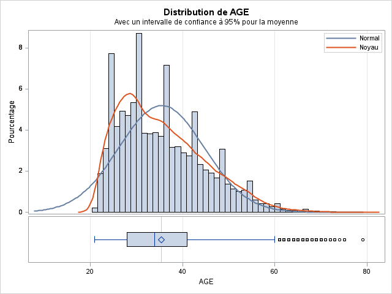

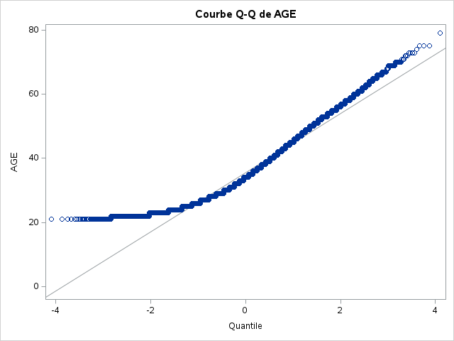

Données : défauts de paiement des clients à Taïwan

Tableau croisé des variables

La procédure SURVEYSELECT

| Méthode de sélection | Echantillonnage aléatoire simple |
| --- | --- |

| Table d'entrée | TAIWAN |
| --- | --- |
| Valeur initiale du nombre aléatoire | 2 |
| Taux d'échantillonnage | 0.8 |
| Taille d'échantillon | 24000 |
| Probabilité de sélection | 0.8 |
| Poids d'échantillonnage | 0 |
| Table de sortie | TAIWAN2 |

Données : défauts de paiement des clients à Taïwan

Tableau croisé des variables

| Obs. | Selected | ID | LIMIT_BAL | SEX | EDUCATION | MARRIAGE | AGE | PAY_0 | PAY_2 | PAY_3 | PAY_4 | PAY_5 | PAY_6 | BILL_AMT1 | BILL_AMT2 | BILL_AMT3 | BILL_AMT4 | BILL_AMT5 | BILL_AMT6 | PAY_AMT1 | PAY_AMT2 | PAY_AMT3 | PAY_AMT4 | PAY_AMT5 | PAY_AMT6 | defaultpayment |
| --- | --- | --- | --- | --- | --- | --- | --- | --- | --- | --- | --- | --- | --- | --- | --- | --- | --- | --- | --- | --- | --- | --- | --- | --- | --- | --- |
| 1 | 1 | 1 | 20000 | 2 | 2 | 1 | 24 | 2 | 2 | -1 | -1 | -2 | -2 | 3913 | 3102 | 689 | 0 | 0 | 0 | 0 | 689 | 0 | 0 | 0 | 0 | 1 |
| 2 | 1 | 2 | 120000 | 2 | 2 | 2 | 26 | -1 | 2 | 0 | 0 | 0 | 2 | 2682 | 1725 | 2682 | 3272 | 3455 | 3261 | 0 | 1000 | 1000 | 1000 | 0 | 2000 | 1 |
| 3 | 1 | 4 | 50000 | 2 | 2 | 1 | 37 | 0 | 0 | 0 | 0 | 0 | 0 | 46990 | 48233 | 49291 | 28314 | 28959 | 29547 | 2000 | 2019 | 1200 | 1100 | 1069 | 1000 | 0 |
| 4 | 1 | 5 | 50000 | 1 | 2 | 1 | 57 | -1 | 0 | -1 | 0 | 0 | 0 | 8617 | 5670 | 35835 | 20940 | 19146 | 19131 | 2000 | 36681 | 10000 | 9000 | 689 | 679 | 0 |
| 5 | 1 | 6 | 50000 | 1 | 1 | 2 | 37 | 0 | 0 | 0 | 0 | 0 | 0 | 64400 | 57069 | 57608 | 19394 | 19619 | 20024 | 2500 | 1815 | 657 | 1000 | 1000 | 800 | 0 |
| 6 | 1 | 8 | 100000 | 2 | 2 | 2 | 23 | 0 | -1 | -1 | 0 | 0 | -1 | 11876 | 380 | 601 | 221 | -159 | 567 | 380 | 601 | 0 | 581 | 1687 | 1542 | 0 |
| 7 | 1 | 9 | 140000 | 2 | 3 | 1 | 28 | 0 | 0 | 2 | 0 | 0 | 0 | 11285 | 14096 | 12108 | 12211 | 11793 | 3719 | 3329 | 0 | 432 | 1000 | 1000 | 1000 | 0 |
| 8 | 1 | 10 | 20000 | 1 | 3 | 2 | 35 | -2 | -2 | -2 | -2 | -1 | -1 | 0 | 0 | 0 | 0 | 13007 | 13912 | 0 | 0 | 0 | 13007 | 1122 | 0 | 0 |
| 9 | 1 | 11 | 200000 | 2 | 3 | 2 | 34 | 0 | 0 | 2 | 0 | 0 | -1 | 11073 | 9787 | 5535 | 2513 | 1828 | 3731 | 2306 | 12 | 50 | 300 | 3738 | 66 | 0 |
| 10 | 1 | 12 | 260000 | 2 | 1 | 2 | 51 | -1 | -1 | -1 | -1 | -1 | 2 | 12261 | 21670 | 9966 | 8517 | 22287 | 13668 | 21818 | 9966 | 8583 | 22301 | 0 | 3640 | 0 |
| 11 | 1 | 13 | 630000 | 2 | 2 | 2 | 41 | -1 | 0 | -1 | -1 | -1 | -1 | 12137 | 6500 | 6500 | 6500 | 6500 | 2870 | 1000 | 6500 | 6500 | 6500 | 2870 | 0 | 0 |
| 12 | 1 | 14 | 70000 | 1 | 2 | 2 | 30 | 1 | 2 | 2 | 0 | 0 | 2 | 65802 | 67369 | 65701 | 66782 | 36137 | 36894 | 3200 | 0 | 3000 | 3000 | 1500 | 0 | 1 |
| 13 | 1 | 15 | 250000 | 1 | 1 | 2 | 29 | 0 | 0 | 0 | 0 | 0 | 0 | 70887 | 67060 | 63561 | 59696 | 56875 | 55512 | 3000 | 3000 | 3000 | 3000 | 3000 | 3000 | 0 |
| 14 | 1 | 17 | 20000 | 1 | 1 | 2 | 24 | 0 | 0 | 2 | 2 | 2 | 2 | 15376 | 18010 | 17428 | 18338 | 17905 | 19104 | 3200 | 0 | 1500 | 0 | 1650 | 0 | 1 |
| 15 | 1 | 20 | 180000 | 2 | 1 | 2 | 29 | 1 | -2 | -2 | -2 | -2 | -2 | 0 | 0 | 0 | 0 | 0 | 0 | 0 | 0 | 0 | 0 | 0 | 0 | 0 |
| 16 | 1 | 21 | 130000 | 2 | 3 | 2 | 39 | 0 | 0 | 0 | 0 | 0 | -1 | 38358 | 27688 | 24489 | 20616 | 11802 | 930 | 3000 | 1537 | 1000 | 2000 | 930 | 33764 | 0 |
| 17 | 1 | 22 | 120000 | 2 | 2 | 1 | 39 | -1 | -1 | -1 | -1 | -1 | -1 | 316 | 316 | 316 | 0 | 632 | 316 | 316 | 316 | 0 | 632 | 316 | 0 | 1 |
| 18 | 1 | 24 | 450000 | 2 | 1 | 1 | 40 | -2 | -2 | -2 | -2 | -2 | -2 | 5512 | 19420 | 1473 | 560 | 0 | 0 | 19428 | 1473 | 560 | 0 | 0 | 1128 | 1 |
| 19 | 1 | 25 | 90000 | 1 | 1 | 2 | 23 | 0 | 0 | 0 | -1 | 0 | 0 | 4744 | 7070 | 0 | 5398 | 6360 | 8292 | 5757 | 0 | 5398 | 1200 | 2045 | 2000 | 0 |
| 20 | 1 | 26 | 50000 | 1 | 3 | 2 | 23 | 0 | 0 | 0 | 0 | 0 | 0 | 47620 | 41810 | 36023 | 28967 | 29829 | 30046 | 1973 | 1426 | 1001 | 1432 | 1062 | 997 | 0 |
| 21 | 1 | 27 | 60000 | 1 | 1 | 2 | 27 | 1 | -2 | -1 | -1 | -1 | -1 | -109 | -425 | 259 | -57 | 127 | -189 | 0 | 1000 | 0 | 500 | 0 | 1000 | 1 |
| 22 | 1 | 29 | 50000 | 2 | 3 | 1 | 47 | -1 | -1 | -1 | -1 | -1 | -1 | 650 | 3415 | 3416 | 2040 | 30430 | 257 | 3415 | 3421 | 2044 | 30430 | 257 | 0 | 0 |
| 23 | 1 | 30 | 50000 | 1 | 1 | 2 | 26 | 0 | 0 | 0 | 0 | 0 | 0 | 15329 | 16575 | 17496 | 17907 | 18375 | 11400 | 1500 | 1500 | 1000 | 1000 | 1600 | 0 | 0 |
| 24 | 1 | 31 | 230000 | 2 | 1 | 2 | 27 | -1 | -1 | -1 | -1 | -1 | -1 | 16646 | 17265 | 13266 | 15339 | 14307 | 36923 | 17270 | 13281 | 15339 | 14307 | 37292 | 0 | 0 |
| 25 | 1 | 32 | 50000 | 1 | 2 | 2 | 33 | 2 | 0 | 0 | 0 | 0 | 0 | 30518 | 29618 | 22102 | 22734 | 23217 | 23680 | 1718 | 1500 | 1000 | 1000 | 1000 | 716 | 1 |
| 26 | 1 | 33 | 100000 | 1 | 1 | 2 | 32 | 0 | 0 | 0 | 0 | 0 | 0 | 93036 | 84071 | 82880 | 80958 | 78703 | 75589 | 3023 | 3511 | 3302 | 3204 | 3200 | 2504 | 0 |
| 27 | 1 | 34 | 500000 | 2 | 2 | 1 | 54 | -2 | -2 | -2 | -2 | -2 | -2 | 10929 | 4152 | 22722 | 7521 | 71439 | 8981 | 4152 | 22827 | 7521 | 71439 | 981 | 51582 | 0 |
| 28 | 1 | 35 | 500000 | 1 | 1 | 1 | 58 | -2 | -2 | -2 | -2 | -2 | -2 | 13709 | 5006 | 31130 | 3180 | 0 | 5293 | 5006 | 31178 | 3180 | 0 | 5293 | 768 | 0 |
| 29 | 1 | 36 | 160000 | 1 | 1 | 2 | 30 | -1 | -1 | -2 | -2 | -2 | -1 | 30265 | -131 | -527 | -923 | -1488 | -1884 | 131 | 396 | 396 | 565 | 792 | 0 | 0 |
| 30 | 1 | 37 | 280000 | 1 | 2 | 1 | 40 | 0 | 0 | 0 | 0 | 0 | 0 | 186503 | 181328 | 180422 | 170410 | 173901 | 177413 | 8026 | 8060 | 6300 | 6400 | 6400 | 6737 | 0 |

[output cut: 470 more lines]

Données : défauts de paiement des clients à Taïwan

Tableau croisé des variables

| Obs. | Selected | ID | LIMIT_BAL | SEX | EDUCATION | MARRIAGE | AGE | PAY_0 | PAY_2 | PAY_3 | PAY_4 | PAY_5 | PAY_6 | BILL_AMT1 | BILL_AMT2 | BILL_AMT3 | BILL_AMT4 | BILL_AMT5 | BILL_AMT6 | PAY_AMT1 | PAY_AMT2 | PAY_AMT3 | PAY_AMT4 | PAY_AMT5 | PAY_AMT6 | defaultpayment |
| --- | --- | --- | --- | --- | --- | --- | --- | --- | --- | --- | --- | --- | --- | --- | --- | --- | --- | --- | --- | --- | --- | --- | --- | --- | --- | --- |
| 1 | 0 | 3 | 90000 | 2 | 2 | 2 | 34 | 0 | 0 | 0 | 0 | 0 | 0 | 29239 | 14027 | 13559 | 14331 | 14948 | 15549 | 1518 | 1500 | 1000 | 1000 | 1000 | 5000 | 0 |
| 2 | 0 | 7 | 500000 | 1 | 1 | 2 | 29 | 0 | 0 | 0 | 0 | 0 | 0 | 367965 | 412023 | 445007 | 542653 | 483003 | 473944 | 55000 | 40000 | 38000 | 20239 | 13750 | 13770 | 0 |
| 3 | 0 | 16 | 50000 | 2 | 3 | 3 | 23 | 1 | 2 | 0 | 0 | 0 | 0 | 50614 | 29173 | 28116 | 28771 | 29531 | 30211 | 0 | 1500 | 1100 | 1200 | 1300 | 1100 | 0 |
| 4 | 0 | 18 | 320000 | 1 | 1 | 1 | 49 | 0 | 0 | 0 | -1 | -1 | -1 | 253286 | 246536 | 194663 | 70074 | 5856 | 195599 | 10358 | 10000 | 75940 | 20000 | 195599 | 50000 | 0 |
| 5 | 0 | 19 | 360000 | 2 | 1 | 1 | 49 | 1 | -2 | -2 | -2 | -2 | -2 | 0 | 0 | 0 | 0 | 0 | 0 | 0 | 0 | 0 | 0 | 0 | 0 | 0 |
| 6 | 0 | 23 | 70000 | 2 | 2 | 2 | 26 | 2 | 0 | 0 | 2 | 2 | 2 | 41087 | 42445 | 45020 | 44006 | 46905 | 46012 | 2007 | 3582 | 0 | 3601 | 0 | 1820 | 1 |
| 7 | 0 | 28 | 50000 | 2 | 3 | 2 | 30 | 0 | 0 | 0 | 0 | 0 | 0 | 22541 | 16138 | 17163 | 17878 | 18931 | 19617 | 1300 | 1300 | 1000 | 1500 | 1000 | 1012 | 0 |
| 8 | 0 | 41 | 360000 | 1 | 1 | 2 | 33 | 0 | 0 | 0 | 0 | 0 | 0 | 218668 | 221296 | 206895 | 628699 | 195969 | 179224 | 10000 | 7000 | 6000 | 188840 | 28000 | 4000 | 0 |
| 9 | 0 | 42 | 70000 | 2 | 1 | 2 | 25 | 0 | 0 | 0 | 0 | 0 | 0 | 67521 | 66999 | 63949 | 63699 | 64718 | 65970 | 3000 | 4500 | 4042 | 2500 | 2800 | 2500 | 0 |
| 10 | 0 | 43 | 10000 | 1 | 2 | 2 | 22 | 0 | 0 | 0 | 0 | 0 | 0 | 1877 | 3184 | 6003 | 3576 | 3670 | 4451 | 1500 | 2927 | 1000 | 300 | 1000 | 500 | 0 |
| 11 | 0 | 50 | 20000 | 1 | 1 | 2 | 24 | 0 | 0 | 0 | 0 | 0 | 0 | 17447 | 18479 | 19476 | 19865 | 20480 | 20063 | 1318 | 1315 | 704 | 928 | 912 | 1069 | 0 |
| 12 | 0 | 62 | 70000 | 1 | 2 | 1 | 39 | 0 | 0 | 0 | 0 | 0 | -1 | 70800 | 72060 | 69938 | 16518 | 14096 | 830 | 4025 | 2095 | 1000 | 2000 | 3000 | 0 | 0 |
| 13 | 0 | 76 | 20000 | 1 | 2 | 2 | 24 | 0 | 0 | 2 | 0 | 0 | 0 | 14619 | 17216 | 16642 | 16976 | 17332 | 18543 | 2850 | 0 | 610 | 630 | 1500 | 0 | 0 |
| 14 | 0 | 77 | 50000 | 1 | 3 | 2 | 25 | -1 | 0 | 0 | 0 | 0 | 0 | 42838 | 37225 | 36087 | 9636 | 9590 | 10030 | 1759 | 1779 | 320 | 500 | 1000 | 1000 | 0 |
| 15 | 0 | 78 | 300000 | 2 | 1 | 1 | 45 | -1 | -1 | -1 | -1 | -1 | -1 | 291 | 291 | 291 | 291 | 291 | 291 | 291 | 291 | 291 | 291 | 291 | 291 | 0 |
| 16 | 0 | 79 | 30000 | 2 | 2 | 2 | 22 | 0 | 0 | 0 | 0 | 0 | 0 | 28387 | 29612 | 30326 | 28004 | 26446 | 6411 | 1686 | 1400 | 560 | 3000 | 1765 | 0 | 1 |
| 17 | 0 | 83 | 60000 | 1 | 3 | 2 | 30 | 0 | 0 | 0 | 0 | 0 | 0 | 26324 | 27471 | 28108 | 21993 | 19899 | 19771 | 1576 | 1213 | 648 | 768 | 1140 | 0 | 1 |
| 18 | 0 | 84 | 400000 | 2 | 2 | 1 | 44 | 0 | 0 | 2 | 0 | 0 | 0 | 131595 | 139060 | 126819 | 104430 | 104990 | 94058 | 10700 | 3 | 3050 | 3000 | 3200 | 2800 | 0 |
| 19 | 0 | 85 | 50000 | 2 | 3 | 2 | 49 | 0 | 0 | 0 | 0 | 0 | 0 | 48909 | 47863 | 21489 | 20414 | 19342 | 19482 | 1676 | 1302 | 700 | 699 | 849 | 826 | 0 |
| 20 | 0 | 90 | 20000 | 1 | 3 | 2 | 44 | 2 | 2 | 0 | 0 | 0 | 2 | 8583 | 8303 | 9651 | 10488 | 12314 | 11970 | 0 | 1651 | 1000 | 2000 | 0 | 1500 | 0 |
| 21 | 0 | 98 | 150000 | 1 | 1 | 2 | 27 | 0 | 0 | 0 | 0 | 0 | 0 | 86009 | 86108 | 89006 | 89775 | 87725 | 40788 | 4031 | 10006 | 3266 | 4040 | 1698 | 800 | 0 |
| 22 | 0 | 105 | 60000 | 2 | 2 | 2 | 26 | 2 | 2 | 2 | 2 | 2 | 0 | 56685 | 55208 | 59175 | 60218 | 55447 | 55305 | 0 | 5000 | 2511 | 6 | 3000 | 3000 | 0 |
| 23 | 0 | 106 | 70000 | 2 | 2 | 2 | 24 | -1 | -1 | -2 | -2 | -2 | -1 | 5580 | 0 | 0 | 0 | 0 | 26529 | 0 | 0 | 0 | 0 | 26529 | 2000 | 0 |
| 24 | 0 | 107 | 80000 | 2 | 2 | 1 | 36 | -1 | -1 | -1 | -1 | -1 | -1 | 6108 | 2861 | 3277 | 3319 | 1150 | 1150 | 2861 | 3279 | 3319 | 1150 | 1150 | 1035 | 0 |
| 25 | 0 | 108 | 350000 | 1 | 1 | 2 | 52 | -1 | -1 | -1 | -1 | -1 | -1 | 713 | 2272 | 722 | 867 | 1150 | 5263 | 2272 | 722 | 867 | 1150 | 5263 | 5011 | 0 |
| 26 | 0 | 123 | 110000 | 2 | 1 | 1 | 48 | 1 | -2 | -2 | -2 | -2 | -2 | 0 | 0 | 0 | 0 | 0 | 0 | 0 | 0 | 0 | 0 | 0 | 0 | 0 |
| 27 | 0 | 124 | 310000 | 2 | 2 | 1 | 35 | 2 | 0 | 0 | 0 | 0 | 0 | 304991 | 311243 | 306314 | 258610 | 246491 | 198889 | 13019 | 11128 | 8407 | 8599 | 6833 | 5987 | 1 |
| 28 | 0 | 126 | 20000 | 1 | 2 | 2 | 23 | 1 | -2 | -2 | -2 | -2 | -2 | 0 | 0 | 0 | 0 | 0 | 0 | 0 | 0 | 0 | 0 | 0 | 0 | 0 |
| 29 | 0 | 136 | 240000 | 1 | 2 | 1 | 34 | 0 | 0 | 0 | 2 | 2 | 2 | 10674 | 12035 | 13681 | 13269 | 14158 | 13891 | 1500 | 1800 | 0 | 1000 | 0 | 327 | 0 |
| 30 | 0 | 149 | 80000 | 2 | 2 | 1 | 23 | 1 | 2 | 3 | 2 | 0 | 0 | 9168 | 10522 | 10205 | 9898 | 10123 | 12034 | 1650 | 0 | 0 | 379 | 2091 | 1 | 0 |

[output cut: 65 more lines]

Données : défauts de paiement des clients à Taïwan

Tableau croisé des variables

| Obs. | Selected | ID | LIMIT_BAL | SEX | EDUCATION | MARRIAGE | AGE | PAY_0 | PAY_2 | PAY_3 | PAY_4 | PAY_5 | PAY_6 | BILL_AMT1 | BILL_AMT2 | BILL_AMT3 | BILL_AMT4 | BILL_AMT5 | BILL_AMT6 | PAY_AMT1 | PAY_AMT2 | PAY_AMT3 | PAY_AMT4 | PAY_AMT5 | PAY_AMT6 | defaultpayment |
| --- | --- | --- | --- | --- | --- | --- | --- | --- | --- | --- | --- | --- | --- | --- | --- | --- | --- | --- | --- | --- | --- | --- | --- | --- | --- | --- |
| 1 | 0 | 3 | 90000 | 2 | 2 | 2 | 34 | 0 | 0 | 0 | 0 | 0 | 0 | 29239 | 14027 | 13559 | 14331 | 14948 | 15549 | 1518 | 1500 | 1000 | 1000 | 1000 | 5000 | 0 |
| 2 | 0 | 7 | 500000 | 1 | 1 | 2 | 29 | 0 | 0 | 0 | 0 | 0 | 0 | 367965 | 412023 | 445007 | 542653 | 483003 | 473944 | 55000 | 40000 | 38000 | 20239 | 13750 | 13770 | 0 |
| 3 | 0 | 16 | 50000 | 2 | 3 | 3 | 23 | 1 | 2 | 0 | 0 | 0 | 0 | 50614 | 29173 | 28116 | 28771 | 29531 | 30211 | 0 | 1500 | 1100 | 1200 | 1300 | 1100 | 0 |
| 4 | 0 | 18 | 320000 | 1 | 1 | 1 | 49 | 0 | 0 | 0 | -1 | -1 | -1 | 253286 | 246536 | 194663 | 70074 | 5856 | 195599 | 10358 | 10000 | 75940 | 20000 | 195599 | 50000 | 0 |
| 5 | 0 | 19 | 360000 | 2 | 1 | 1 | 49 | 1 | -2 | -2 | -2 | -2 | -2 | 0 | 0 | 0 | 0 | 0 | 0 | 0 | 0 | 0 | 0 | 0 | 0 | 0 |
| 6 | 0 | 23 | 70000 | 2 | 2 | 2 | 26 | 2 | 0 | 0 | 2 | 2 | 2 | 41087 | 42445 | 45020 | 44006 | 46905 | 46012 | 2007 | 3582 | 0 | 3601 | 0 | 1820 | 1 |
| 7 | 0 | 28 | 50000 | 2 | 3 | 2 | 30 | 0 | 0 | 0 | 0 | 0 | 0 | 22541 | 16138 | 17163 | 17878 | 18931 | 19617 | 1300 | 1300 | 1000 | 1500 | 1000 | 1012 | 0 |
| 8 | 0 | 41 | 360000 | 1 | 1 | 2 | 33 | 0 | 0 | 0 | 0 | 0 | 0 | 218668 | 221296 | 206895 | 628699 | 195969 | 179224 | 10000 | 7000 | 6000 | 188840 | 28000 | 4000 | 0 |
| 9 | 0 | 42 | 70000 | 2 | 1 | 2 | 25 | 0 | 0 | 0 | 0 | 0 | 0 | 67521 | 66999 | 63949 | 63699 | 64718 | 65970 | 3000 | 4500 | 4042 | 2500 | 2800 | 2500 | 0 |
| 10 | 0 | 43 | 10000 | 1 | 2 | 2 | 22 | 0 | 0 | 0 | 0 | 0 | 0 | 1877 | 3184 | 6003 | 3576 | 3670 | 4451 | 1500 | 2927 | 1000 | 300 | 1000 | 500 | 0 |
| 11 | 0 | 50 | 20000 | 1 | 1 | 2 | 24 | 0 | 0 | 0 | 0 | 0 | 0 | 17447 | 18479 | 19476 | 19865 | 20480 | 20063 | 1318 | 1315 | 704 | 928 | 912 | 1069 | 0 |
| 12 | 0 | 62 | 70000 | 1 | 2 | 1 | 39 | 0 | 0 | 0 | 0 | 0 | -1 | 70800 | 72060 | 69938 | 16518 | 14096 | 830 | 4025 | 2095 | 1000 | 2000 | 3000 | 0 | 0 |
| 13 | 0 | 76 | 20000 | 1 | 2 | 2 | 24 | 0 | 0 | 2 | 0 | 0 | 0 | 14619 | 17216 | 16642 | 16976 | 17332 | 18543 | 2850 | 0 | 610 | 630 | 1500 | 0 | 0 |
| 14 | 0 | 77 | 50000 | 1 | 3 | 2 | 25 | -1 | 0 | 0 | 0 | 0 | 0 | 42838 | 37225 | 36087 | 9636 | 9590 | 10030 | 1759 | 1779 | 320 | 500 | 1000 | 1000 | 0 |
| 15 | 0 | 78 | 300000 | 2 | 1 | 1 | 45 | -1 | -1 | -1 | -1 | -1 | -1 | 291 | 291 | 291 | 291 | 291 | 291 | 291 | 291 | 291 | 291 | 291 | 291 | 0 |
| 16 | 0 | 79 | 30000 | 2 | 2 | 2 | 22 | 0 | 0 | 0 | 0 | 0 | 0 | 28387 | 29612 | 30326 | 28004 | 26446 | 6411 | 1686 | 1400 | 560 | 3000 | 1765 | 0 | 1 |
| 17 | 0 | 83 | 60000 | 1 | 3 | 2 | 30 | 0 | 0 | 0 | 0 | 0 | 0 | 26324 | 27471 | 28108 | 21993 | 19899 | 19771 | 1576 | 1213 | 648 | 768 | 1140 | 0 | 1 |
| 18 | 0 | 84 | 400000 | 2 | 2 | 1 | 44 | 0 | 0 | 2 | 0 | 0 | 0 | 131595 | 139060 | 126819 | 104430 | 104990 | 94058 | 10700 | 3 | 3050 | 3000 | 3200 | 2800 | 0 |
| 19 | 0 | 85 | 50000 | 2 | 3 | 2 | 49 | 0 | 0 | 0 | 0 | 0 | 0 | 48909 | 47863 | 21489 | 20414 | 19342 | 19482 | 1676 | 1302 | 700 | 699 | 849 | 826 | 0 |
| 20 | 0 | 90 | 20000 | 1 | 3 | 2 | 44 | 2 | 2 | 0 | 0 | 0 | 2 | 8583 | 8303 | 9651 | 10488 | 12314 | 11970 | 0 | 1651 | 1000 | 2000 | 0 | 1500 | 0 |
| 21 | 0 | 98 | 150000 | 1 | 1 | 2 | 27 | 0 | 0 | 0 | 0 | 0 | 0 | 86009 | 86108 | 89006 | 89775 | 87725 | 40788 | 4031 | 10006 | 3266 | 4040 | 1698 | 800 | 0 |
| 22 | 0 | 105 | 60000 | 2 | 2 | 2 | 26 | 2 | 2 | 2 | 2 | 2 | 0 | 56685 | 55208 | 59175 | 60218 | 55447 | 55305 | 0 | 5000 | 2511 | 6 | 3000 | 3000 | 0 |
| 23 | 0 | 106 | 70000 | 2 | 2 | 2 | 24 | -1 | -1 | -2 | -2 | -2 | -1 | 5580 | 0 | 0 | 0 | 0 | 26529 | 0 | 0 | 0 | 0 | 26529 | 2000 | 0 |
| 24 | 0 | 107 | 80000 | 2 | 2 | 1 | 36 | -1 | -1 | -1 | -1 | -1 | -1 | 6108 | 2861 | 3277 | 3319 | 1150 | 1150 | 2861 | 3279 | 3319 | 1150 | 1150 | 1035 | 0 |
| 25 | 0 | 108 | 350000 | 1 | 1 | 2 | 52 | -1 | -1 | -1 | -1 | -1 | -1 | 713 | 2272 | 722 | 867 | 1150 | 5263 | 2272 | 722 | 867 | 1150 | 5263 | 5011 | 0 |
| 26 | 0 | 123 | 110000 | 2 | 1 | 1 | 48 | 1 | -2 | -2 | -2 | -2 | -2 | 0 | 0 | 0 | 0 | 0 | 0 | 0 | 0 | 0 | 0 | 0 | 0 | 0 |
| 27 | 0 | 124 | 310000 | 2 | 2 | 1 | 35 | 2 | 0 | 0 | 0 | 0 | 0 | 304991 | 311243 | 306314 | 258610 | 246491 | 198889 | 13019 | 11128 | 8407 | 8599 | 6833 | 5987 | 1 |
| 28 | 0 | 126 | 20000 | 1 | 2 | 2 | 23 | 1 | -2 | -2 | -2 | -2 | -2 | 0 | 0 | 0 | 0 | 0 | 0 | 0 | 0 | 0 | 0 | 0 | 0 | 0 |
| 29 | 0 | 136 | 240000 | 1 | 2 | 1 | 34 | 0 | 0 | 0 | 2 | 2 | 2 | 10674 | 12035 | 13681 | 13269 | 14158 | 13891 | 1500 | 1800 | 0 | 1000 | 0 | 327 | 0 |
| 30 | 0 | 149 | 80000 | 2 | 2 | 1 | 23 | 1 | 2 | 3 | 2 | 0 | 0 | 9168 | 10522 | 10205 | 9898 | 10123 | 12034 | 1650 | 0 | 0 | 379 | 2091 | 1 | 0 |

[output cut: 65 more lines]

Données : défauts de paiement des clients à Taïwan

Tableau croisé des variables

La procédure LOGISTIC

| Informations sur le modèle |  |  |
| --- | --- | --- |
| Table | WORK.TRAIN |  |
| Variable de réponse | defaultpayment | defaultpayment |
| Nombre de niveaux de réponse | 2 |  |
| Modèle | logit binaire |  |
| Technique d'optimisation | Score de Fisher |  |

| Nb d'observations lues | 500 |
| --- | --- |
| Nb d'observations utilisées | 500 |

| Profil de réponse Valeur ordonnée | Profil de réponse defaultpayment | Profil de réponse Fréquence totale |
| --- | --- | --- |
| 1 | 0 | 385 |
| 2 | 1 | 115 |

La probabilité modélisée est defaultpayment='1'.

Procédure d'élimination descendante

| Informations sur les niveaux de classe Classe | Informations sur les niveaux de classe Valeur | Informations sur les niveaux de classe Variables d'expérience | Informations sur les niveaux de classe Variables d'expérience | Informations sur les niveaux de classe Variables d'expérience | Informations sur les niveaux de classe Variables d'expérience | Informations sur les niveaux de classe Variables d'expérience | Informations sur les niveaux de classe Variables d'expérience | Informations sur les niveaux de classe Variables d'expérience |
| --- | --- | --- | --- | --- | --- | --- | --- | --- |
| SEX | 1 | 1 | 0 |  |  |  |  |  |
|  | 2 | 0 | 1 |  |  |  |  |  |
| EDUCATION | 1 | 1 | 0 | 0 | 0 | 0 | 0 |  |
|  | 2 | 0 | 1 | 0 | 0 | 0 | 0 |  |
|  | 3 | 0 | 0 | 1 | 0 | 0 | 0 |  |
|  | 4 | 0 | 0 | 0 | 1 | 0 | 0 |  |
|  | 5 | 0 | 0 | 0 | 0 | 1 | 0 |  |
|  | 6 | 0 | 0 | 0 | 0 | 0 | 1 |  |
| MARRIAGE | 0 | 1 | 0 | 0 | 0 |  |  |  |
|  | 1 | 0 | 1 | 0 | 0 |  |  |  |
|  | 2 | 0 | 0 | 1 | 0 |  |  |  |
|  | 3 | 0 | 0 | 0 | 1 |  |  |  |
| PAY_0 | 0 | 1 | 0 | 0 | 0 | 0 | 0 | 0 |
|  | 1 | 0 | 1 | 0 | 0 | 0 | 0 | 0 |
|  | 2 | 0 | 0 | 1 | 0 | 0 | 0 | 0 |
|  | 3 | 0 | 0 | 0 | 1 | 0 | 0 | 0 |
|  | 4 | 0 | 0 | 0 | 0 | 1 | 0 | 0 |
|  | -1 | 0 | 0 | 0 | 0 | 0 | 1 | 0 |
|  | -2 | 0 | 0 | 0 | 0 | 0 | 0 | 1 |
| PAY_2 | 0 | 1 | 0 | 0 | 0 | 0 | 0 |  |
|  | 2 | 0 | 1 | 0 | 0 | 0 | 0 |  |
|  | 3 | 0 | 0 | 1 | 0 | 0 | 0 |  |
|  | 5 | 0 | 0 | 0 | 1 | 0 | 0 |  |
|  | -1 | 0 | 0 | 0 | 0 | 1 | 0 |  |
|  | -2 | 0 | 0 | 0 | 0 | 0 | 1 |  |
| PAY_3 | 0 | 1 | 0 | 0 | 0 | 0 |  |  |
|  | 2 | 0 | 1 | 0 | 0 | 0 |  |  |
|  | 4 | 0 | 0 | 1 | 0 | 0 |  |  |
|  | -1 | 0 | 0 | 0 | 1 | 0 |  |  |
|  | -2 | 0 | 0 | 0 | 0 | 1 |  |  |
| PAY_4 | 0 | 1 | 0 | 0 | 0 | 0 | 0 |  |
|  | 2 | 0 | 1 | 0 | 0 | 0 | 0 |  |
|  | 3 | 0 | 0 | 1 | 0 | 0 | 0 |  |
|  | 4 | 0 | 0 | 0 | 1 | 0 | 0 |  |
|  | -1 | 0 | 0 | 0 | 0 | 1 | 0 |  |
|  | -2 | 0 | 0 | 0 | 0 | 0 | 1 |  |
| PAY_5 | 0 | 1 | 0 | 0 | 0 | 0 |  |  |
|  | 2 | 0 | 1 | 0 | 0 | 0 |  |  |
|  | 3 | 0 | 0 | 1 | 0 | 0 |  |  |
|  | -1 | 0 | 0 | 0 | 1 | 0 |  |  |
|  | -2 | 0 | 0 | 0 | 0 | 1 |  |  |
| PAY_6 | 0 | 1 | 0 | 0 | 0 | 0 | 0 |  |
|  | 2 | 0 | 1 | 0 | 0 | 0 | 0 |  |
|  | 3 | 0 | 0 | 1 | 0 | 0 | 0 |  |
|  | 4 | 0 | 0 | 0 | 1 | 0 | 0 |  |
|  | -1 | 0 | 0 | 0 | 0 | 1 | 0 |  |
|  | -2 | 0 | 0 | 0 | 0 | 0 | 1 |  |

Etape 0. Les effets suivants ont été saisis :

Intercept SEX EDUCATION MARRIAGE PAY_0 PAY_2 PAY_3 PAY_4 PAY_5 PAY_6 LIMIT_BAL AGE BILL_AMT1 BILL_AMT2 BILL_AMT3 BILL_AMT4 BILL_AMT5 BILL_AMT6 PAY_AMT1 PAY_AMT2 PAY_AMT3 PAY_AMT4 PAY_AMT5 PAY_AMT6

| Etat de convergence du modèle |
| --- |
| Séparation quasi-complète des points de données détectée. |

| Statistique d'ajustement du modèle Critère | Statistique d'ajustement du modèle Constante uniquement | Statistique d'ajustement du modèle Constante et Covariables |
| --- | --- | --- |
| AIC | 541.276 | 525.567 |
| SC | 545.491 | 740.512 |
| -2 Log L | 539.276 | 423.567 |

| Test de l'hypothèse nulle globale : BETA=0 Test | Test de l'hypothèse nulle globale : BETA=0 khi-2 | Test de l'hypothèse nulle globale : BETA=0 DDL | Test de l'hypothèse nulle globale : BETA=0 Pr > khi-2 |
| --- | --- | --- | --- |
| Rapport de vrais | 115.7096 | 50 | <.0001 |
| Score | 106.7344 | 50 | <.0001 |
| Wald | 69.6410 | 50 | 0.0345 |

Etape 1. Effet PAY_AMT3 supprimé :

| Etat de convergence du modèle |
| --- |
| Séparation quasi-complète des points de données détectée. |

| Statistique d'ajustement du modèle Critère | Statistique d'ajustement du modèle Constante uniquement | Statistique d'ajustement du modèle Constante et Covariables |
| --- | --- | --- |
| AIC | 541.276 | 523.567 |
| SC | 545.491 | 734.298 |
| -2 Log L | 539.276 | 423.567 |

| Test de l'hypothèse nulle globale : BETA=0 Test | Test de l'hypothèse nulle globale : BETA=0 khi-2 | Test de l'hypothèse nulle globale : BETA=0 DDL | Test de l'hypothèse nulle globale : BETA=0 Pr > khi-2 |
| --- | --- | --- | --- |
| Rapport de vrais | 115.7089 | 49 | <.0001 |
| Score | 106.4354 | 49 | <.0001 |
| Wald | 69.6237 | 49 | 0.0279 |

| Test du khi-2 résiduel khi-2 | Test du khi-2 résiduel DDL | Test du khi-2 résiduel Pr > khi-2 |
| --- | --- | --- |
| 0.0011 | 1 | 0.9734 |

Etape 2. Effet MARRIAGE supprimé :

| Etat de convergence du modèle |
| --- |
| Séparation quasi-complète des points de données détectée. |

| Statistique d'ajustement du modèle Critère | Statistique d'ajustement du modèle Constante uniquement | Statistique d'ajustement du modèle Constante et Covariables |
| --- | --- | --- |
| AIC | 541.276 | 521.454 |
| SC | 545.491 | 719.541 |
| -2 Log L | 539.276 | 427.454 |

| Test de l'hypothèse nulle globale : BETA=0 Test | Test de l'hypothèse nulle globale : BETA=0 khi-2 | Test de l'hypothèse nulle globale : BETA=0 DDL | Test de l'hypothèse nulle globale : BETA=0 Pr > khi-2 |
| --- | --- | --- | --- |
| Rapport de vrais | 111.8224 | 46 | <.0001 |
| Score | 104.6734 | 46 | <.0001 |
| Wald | 70.1297 | 46 | 0.0125 |

| Test du khi-2 résiduel khi-2 | Test du khi-2 résiduel DDL | Test du khi-2 résiduel Pr > khi-2 |
| --- | --- | --- |
| 2.4582 | 4 | 0.6521 |

Etape 3. Effet BILL_AMT2 supprimé :

| Etat de convergence du modèle |
| --- |
| Séparation quasi-complète des points de données détectée. |

| Statistique d'ajustement du modèle Critère | Statistique d'ajustement du modèle Constante uniquement | Statistique d'ajustement du modèle Constante et Covariables |
| --- | --- | --- |
| AIC | 541.276 | 519.454 |
| SC | 545.491 | 713.326 |
| -2 Log L | 539.276 | 427.454 |

| Test de l'hypothèse nulle globale : BETA=0 Test | Test de l'hypothèse nulle globale : BETA=0 khi-2 | Test de l'hypothèse nulle globale : BETA=0 DDL | Test de l'hypothèse nulle globale : BETA=0 Pr > khi-2 |
| --- | --- | --- | --- |
| Rapport de vrais | 111.8220 | 45 | <.0001 |
| Score | 104.5128 | 45 | <.0001 |
| Wald | 70.1324 | 45 | 0.0096 |

| Test du khi-2 résiduel khi-2 | Test du khi-2 résiduel DDL | Test du khi-2 résiduel Pr > khi-2 |
| --- | --- | --- |
| 2.4598 | 5 | 0.7825 |

Etape 4. Effet PAY_6 supprimé :

| Etat de convergence du modèle |
| --- |
| Séparation quasi-complète des points de données détectée. |

| Statistique d'ajustement du modèle Critère | Statistique d'ajustement du modèle Constante uniquement | Statistique d'ajustement du modèle Constante et Covariables |
| --- | --- | --- |
| AIC | 541.276 | 510.801 |
| SC | 545.491 | 683.600 |
| -2 Log L | 539.276 | 428.801 |

| Test de l'hypothèse nulle globale : BETA=0 Test | Test de l'hypothèse nulle globale : BETA=0 khi-2 | Test de l'hypothèse nulle globale : BETA=0 DDL | Test de l'hypothèse nulle globale : BETA=0 Pr > khi-2 |
| --- | --- | --- | --- |
| Rapport de vrais | 110.4750 | 40 | <.0001 |
| Score | 101.7209 | 40 | <.0001 |
| Wald | 69.5066 | 40 | 0.0026 |

| Test du khi-2 résiduel khi-2 | Test du khi-2 résiduel DDL | Test du khi-2 résiduel Pr > khi-2 |
| --- | --- | --- |
| 3.7570 | 10 | 0.9576 |

Etape 5. Effet PAY_2 supprimé :

| Etat de convergence du modèle |
| --- |
| Séparation quasi-complète des points de données détectée. |

| Statistique d'ajustement du modèle Critère | Statistique d'ajustement du modèle Constante uniquement | Statistique d'ajustement du modèle Constante et Covariables |
| --- | --- | --- |
| AIC | 541.276 | 505.549 |
| SC | 545.491 | 661.489 |
| -2 Log L | 539.276 | 431.549 |

| Test de l'hypothèse nulle globale : BETA=0 Test | Test de l'hypothèse nulle globale : BETA=0 khi-2 | Test de l'hypothèse nulle globale : BETA=0 DDL | Test de l'hypothèse nulle globale : BETA=0 Pr > khi-2 |
| --- | --- | --- | --- |
| Rapport de vrais | 107.7274 | 36 | <.0001 |
| Score | 99.6438 | 36 | <.0001 |
| Wald | 67.4777 | 36 | 0.0011 |

| Test du khi-2 résiduel khi-2 | Test du khi-2 résiduel DDL | Test du khi-2 résiduel Pr > khi-2 |
| --- | --- | --- |
| 6.4667 | 14 | 0.9533 |

Etape 6. Effet EDUCATION supprimé :

| Etat de convergence du modèle |
| --- |
| Séparation quasi-complète des points de données détectée. |

| Statistique d'ajustement du modèle Critère | Statistique d'ajustement du modèle Constante uniquement | Statistique d'ajustement du modèle Constante et Covariables |
| --- | --- | --- |
| AIC | 541.276 | 501.047 |
| SC | 545.491 | 635.914 |
| -2 Log L | 539.276 | 437.047 |

| Test de l'hypothèse nulle globale : BETA=0 Test | Test de l'hypothèse nulle globale : BETA=0 khi-2 | Test de l'hypothèse nulle globale : BETA=0 DDL | Test de l'hypothèse nulle globale : BETA=0 Pr > khi-2 |
| --- | --- | --- | --- |
| Rapport de vrais | 102.2296 | 31 | <.0001 |
| Score | 96.3252 | 31 | <.0001 |
| Wald | 66.4445 | 31 | 0.0002 |

| Test du khi-2 résiduel khi-2 | Test du khi-2 résiduel DDL | Test du khi-2 résiduel Pr > khi-2 |
| --- | --- | --- |
| 10.7278 | 19 | 0.9327 |

Etape 7. Effet PAY_AMT6 supprimé :

| Etat de convergence du modèle |
| --- |
| Séparation quasi-complète des points de données détectée. |

| Statistique d'ajustement du modèle Critère | Statistique d'ajustement du modèle Constante uniquement | Statistique d'ajustement du modèle Constante et Covariables |
| --- | --- | --- |
| AIC | 541.276 | 499.409 |
| SC | 545.491 | 630.062 |
| -2 Log L | 539.276 | 437.409 |

| Test de l'hypothèse nulle globale : BETA=0 Test | Test de l'hypothèse nulle globale : BETA=0 khi-2 | Test de l'hypothèse nulle globale : BETA=0 DDL | Test de l'hypothèse nulle globale : BETA=0 Pr > khi-2 |
| --- | --- | --- | --- |
| Rapport de vrais | 101.8674 | 30 | <.0001 |
| Score | 96.2556 | 30 | <.0001 |
| Wald | 66.7252 | 30 | 0.0001 |

| Test du khi-2 résiduel khi-2 | Test du khi-2 résiduel DDL | Test du khi-2 résiduel Pr > khi-2 |
| --- | --- | --- |
| 11.1891 | 20 | 0.9412 |

Etape 8. Effet LIMIT_BAL supprimé :

| Etat de convergence du modèle |
| --- |
| Séparation quasi-complète des points de données détectée. |

| Statistique d'ajustement du modèle Critère | Statistique d'ajustement du modèle Constante uniquement | Statistique d'ajustement du modèle Constante et Covariables |
| --- | --- | --- |
| AIC | 541.276 | 497.932 |
| SC | 545.491 | 624.370 |
| -2 Log L | 539.276 | 437.932 |

| Test de l'hypothèse nulle globale : BETA=0 Test | Test de l'hypothèse nulle globale : BETA=0 khi-2 | Test de l'hypothèse nulle globale : BETA=0 DDL | Test de l'hypothèse nulle globale : BETA=0 Pr > khi-2 |
| --- | --- | --- | --- |
| Rapport de vrais | 101.3441 | 29 | <.0001 |
| Score | 95.7768 | 29 | <.0001 |
| Wald | 66.5855 | 29 | <.0001 |

| Test du khi-2 résiduel khi-2 | Test du khi-2 résiduel DDL | Test du khi-2 résiduel Pr > khi-2 |
| --- | --- | --- |
| 11.6431 | 21 | 0.9488 |

Etape 9. Effet SEX supprimé :

| Etat de convergence du modèle |
| --- |
| Séparation quasi-complète des points de données détectée. |

| Statistique d'ajustement du modèle Critère | Statistique d'ajustement du modèle Constante uniquement | Statistique d'ajustement du modèle Constante et Covariables |
| --- | --- | --- |
| AIC | 541.276 | 496.451 |
| SC | 545.491 | 618.675 |
| -2 Log L | 539.276 | 438.451 |

| Test de l'hypothèse nulle globale : BETA=0 Test | Test de l'hypothèse nulle globale : BETA=0 khi-2 | Test de l'hypothèse nulle globale : BETA=0 DDL | Test de l'hypothèse nulle globale : BETA=0 Pr > khi-2 |
| --- | --- | --- | --- |
| Rapport de vrais | 100.8253 | 28 | <.0001 |
| Score | 95.4186 | 28 | <.0001 |
| Wald | 66.3711 | 28 | <.0001 |

| Test du khi-2 résiduel khi-2 | Test du khi-2 résiduel DDL | Test du khi-2 résiduel Pr > khi-2 |
| --- | --- | --- |
| 12.1702 | 22 | 0.9538 |

Etape 10. Effet PAY_5 supprimé :

| Etat de convergence du modèle |
| --- |
| Critère de convergence (GCONV=1E-8) respecté. |

| Statistique d'ajustement du modèle Critère | Statistique d'ajustement du modèle Constante uniquement | Statistique d'ajustement du modèle Constante et Covariables |
| --- | --- | --- |
| AIC | 541.276 | 495.479 |
| SC | 545.491 | 600.844 |
| -2 Log L | 539.276 | 445.479 |

| Test de l'hypothèse nulle globale : BETA=0 Test | Test de l'hypothèse nulle globale : BETA=0 khi-2 | Test de l'hypothèse nulle globale : BETA=0 DDL | Test de l'hypothèse nulle globale : BETA=0 Pr > khi-2 |
| --- | --- | --- | --- |
| Rapport de vrais | 93.7975 | 24 | <.0001 |
| Score | 90.2240 | 24 | <.0001 |
| Wald | 63.4268 | 24 | <.0001 |

| Test du khi-2 résiduel khi-2 | Test du khi-2 résiduel DDL | Test du khi-2 résiduel Pr > khi-2 |
| --- | --- | --- |
| 19.2316 | 26 | 0.8265 |

Etape 11. Effet BILL_AMT4 supprimé :

| Etat de convergence du modèle |
| --- |
| Critère de convergence (GCONV=1E-8) respecté. |

| Statistique d'ajustement du modèle Critère | Statistique d'ajustement du modèle Constante uniquement | Statistique d'ajustement du modèle Constante et Covariables |
| --- | --- | --- |
| AIC | 541.276 | 494.781 |
| SC | 545.491 | 595.932 |
| -2 Log L | 539.276 | 446.781 |

| Test de l'hypothèse nulle globale : BETA=0 Test | Test de l'hypothèse nulle globale : BETA=0 khi-2 | Test de l'hypothèse nulle globale : BETA=0 DDL | Test de l'hypothèse nulle globale : BETA=0 Pr > khi-2 |
| --- | --- | --- | --- |
| Rapport de vrais | 92.4952 | 23 | <.0001 |
| Score | 88.1909 | 23 | <.0001 |
| Wald | 62.8458 | 23 | <.0001 |

| Test du khi-2 résiduel khi-2 | Test du khi-2 résiduel DDL | Test du khi-2 résiduel Pr > khi-2 |
| --- | --- | --- |
| 20.3553 | 27 | 0.8155 |

Etape 12. Effet PAY_AMT4 supprimé :

| Etat de convergence du modèle |
| --- |
| Critère de convergence (GCONV=1E-8) respecté. |

| Statistique d'ajustement du modèle Critère | Statistique d'ajustement du modèle Constante uniquement | Statistique d'ajustement du modèle Constante et Covariables |
| --- | --- | --- |
| AIC | 541.276 | 493.565 |
| SC | 545.491 | 590.501 |
| -2 Log L | 539.276 | 447.565 |

| Test de l'hypothèse nulle globale : BETA=0 Test | Test de l'hypothèse nulle globale : BETA=0 khi-2 | Test de l'hypothèse nulle globale : BETA=0 DDL | Test de l'hypothèse nulle globale : BETA=0 Pr > khi-2 |
| --- | --- | --- | --- |
| Rapport de vrais | 91.7114 | 22 | <.0001 |
| Score | 87.6673 | 22 | <.0001 |
| Wald | 63.6734 | 22 | <.0001 |

| Test du khi-2 résiduel khi-2 | Test du khi-2 résiduel DDL | Test du khi-2 résiduel Pr > khi-2 |
| --- | --- | --- |
| 20.9612 | 28 | 0.8270 |

Etape 13. Effet BILL_AMT5 supprimé :

| Etat de convergence du modèle |
| --- |
| Critère de convergence (GCONV=1E-8) respecté. |

| Statistique d'ajustement du modèle Critère | Statistique d'ajustement du modèle Constante uniquement | Statistique d'ajustement du modèle Constante et Covariables |
| --- | --- | --- |
| AIC | 541.276 | 491.955 |
| SC | 545.491 | 584.677 |
| -2 Log L | 539.276 | 447.955 |

| Test de l'hypothèse nulle globale : BETA=0 Test | Test de l'hypothèse nulle globale : BETA=0 khi-2 | Test de l'hypothèse nulle globale : BETA=0 DDL | Test de l'hypothèse nulle globale : BETA=0 Pr > khi-2 |
| --- | --- | --- | --- |
| Rapport de vrais | 91.3209 | 21 | <.0001 |
| Score | 87.3595 | 21 | <.0001 |
| Wald | 64.3213 | 21 | <.0001 |

| Test du khi-2 résiduel khi-2 | Test du khi-2 résiduel DDL | Test du khi-2 résiduel Pr > khi-2 |
| --- | --- | --- |
| 21.0651 | 29 | 0.8568 |

Etape 14. Effet PAY_3 supprimé :

| Etat de convergence du modèle |
| --- |
| Critère de convergence (GCONV=1E-8) respecté. |

| Statistique d'ajustement du modèle Critère | Statistique d'ajustement du modèle Constante uniquement | Statistique d'ajustement du modèle Constante et Covariables |
| --- | --- | --- |
| AIC | 541.276 | 490.842 |
| SC | 545.491 | 570.920 |
| -2 Log L | 539.276 | 452.842 |

| Test de l'hypothèse nulle globale : BETA=0 Test | Test de l'hypothèse nulle globale : BETA=0 khi-2 | Test de l'hypothèse nulle globale : BETA=0 DDL | Test de l'hypothèse nulle globale : BETA=0 Pr > khi-2 |
| --- | --- | --- | --- |
| Rapport de vrais | 86.4339 | 18 | <.0001 |
| Score | 81.9273 | 18 | <.0001 |
| Wald | 61.3377 | 18 | <.0001 |

| Test du khi-2 résiduel khi-2 | Test du khi-2 résiduel DDL | Test du khi-2 résiduel Pr > khi-2 |
| --- | --- | --- |
| 25.8400 | 32 | 0.7706 |

Etape 15. Effet PAY_4 supprimé :

| Etat de convergence du modèle |
| --- |
| Critère de convergence (GCONV=1E-8) respecté. |

| Statistique d'ajustement du modèle Critère | Statistique d'ajustement du modèle Constante uniquement | Statistique d'ajustement du modèle Constante et Covariables |
| --- | --- | --- |
| AIC | 541.276 | 490.456 |
| SC | 545.491 | 549.460 |
| -2 Log L | 539.276 | 462.456 |

| Test de l'hypothèse nulle globale : BETA=0 Test | Test de l'hypothèse nulle globale : BETA=0 khi-2 | Test de l'hypothèse nulle globale : BETA=0 DDL | Test de l'hypothèse nulle globale : BETA=0 Pr > khi-2 |
| --- | --- | --- | --- |
| Rapport de vrais | 76.8206 | 13 | <.0001 |
| Score | 72.8985 | 13 | <.0001 |
| Wald | 59.4399 | 13 | <.0001 |

| Test du khi-2 résiduel khi-2 | Test du khi-2 résiduel DDL | Test du khi-2 résiduel Pr > khi-2 |
| --- | --- | --- |
| 35.1914 | 37 | 0.5540 |

Etape 16. Effet BILL_AMT6 supprimé :

| Etat de convergence du modèle |
| --- |
| Critère de convergence (GCONV=1E-8) respecté. |

| Statistique d'ajustement du modèle Critère | Statistique d'ajustement du modèle Constante uniquement | Statistique d'ajustement du modèle Constante et Covariables |
| --- | --- | --- |
| AIC | 541.276 | 491.265 |
| SC | 545.491 | 546.054 |
| -2 Log L | 539.276 | 465.265 |

| Test de l'hypothèse nulle globale : BETA=0 Test | Test de l'hypothèse nulle globale : BETA=0 khi-2 | Test de l'hypothèse nulle globale : BETA=0 DDL | Test de l'hypothèse nulle globale : BETA=0 Pr > khi-2 |
| --- | --- | --- | --- |
| Rapport de vrais | 74.0118 | 12 | <.0001 |
| Score | 68.9872 | 12 | <.0001 |
| Wald | 56.8944 | 12 | <.0001 |

| Test du khi-2 résiduel khi-2 | Test du khi-2 résiduel DDL | Test du khi-2 résiduel Pr > khi-2 |
| --- | --- | --- |
| 38.1962 | 38 | 0.4606 |

Etape 17. Effet PAY_AMT5 supprimé :

| Etat de convergence du modèle |
| --- |
| Critère de convergence (GCONV=1E-8) respecté. |

| Statistique d'ajustement du modèle Critère | Statistique d'ajustement du modèle Constante uniquement | Statistique d'ajustement du modèle Constante et Covariables |
| --- | --- | --- |
| AIC | 541.276 | 491.496 |
| SC | 545.491 | 542.071 |
| -2 Log L | 539.276 | 467.496 |

| Test de l'hypothèse nulle globale : BETA=0 Test | Test de l'hypothèse nulle globale : BETA=0 khi-2 | Test de l'hypothèse nulle globale : BETA=0 DDL | Test de l'hypothèse nulle globale : BETA=0 Pr > khi-2 |
| --- | --- | --- | --- |
| Rapport de vrais | 71.7802 | 11 | <.0001 |
| Score | 67.9737 | 11 | <.0001 |
| Wald | 55.5310 | 11 | <.0001 |

| Test du khi-2 résiduel khi-2 | Test du khi-2 résiduel DDL | Test du khi-2 résiduel Pr > khi-2 |
| --- | --- | --- |
| 41.0901 | 39 | 0.3791 |

Etape 18. Effet BILL_AMT1 supprimé :

| Etat de convergence du modèle |
| --- |
| Critère de convergence (GCONV=1E-8) respecté. |

| Statistique d'ajustement du modèle Critère | Statistique d'ajustement du modèle Constante uniquement | Statistique d'ajustement du modèle Constante et Covariables |
| --- | --- | --- |
| AIC | 541.276 | 492.747 |
| SC | 545.491 | 539.108 |
| -2 Log L | 539.276 | 470.747 |

| Test de l'hypothèse nulle globale : BETA=0 Test | Test de l'hypothèse nulle globale : BETA=0 khi-2 | Test de l'hypothèse nulle globale : BETA=0 DDL | Test de l'hypothèse nulle globale : BETA=0 Pr > khi-2 |
| --- | --- | --- | --- |
| Rapport de vrais | 68.5291 | 10 | <.0001 |
| Score | 65.2057 | 10 | <.0001 |
| Wald | 54.5358 | 10 | <.0001 |

| Test du khi-2 résiduel khi-2 | Test du khi-2 résiduel DDL | Test du khi-2 résiduel Pr > khi-2 |
| --- | --- | --- |
| 43.7763 | 40 | 0.3143 |

Etape 19. Effet BILL_AMT3 supprimé :

| Etat de convergence du modèle |
| --- |
| Critère de convergence (GCONV=1E-8) respecté. |

| Statistique d'ajustement du modèle Critère | Statistique d'ajustement du modèle Constante uniquement | Statistique d'ajustement du modèle Constante et Covariables |
| --- | --- | --- |
| AIC | 541.276 | 493.372 |
| SC | 545.491 | 535.518 |
| -2 Log L | 539.276 | 473.372 |

| Test de l'hypothèse nulle globale : BETA=0 Test | Test de l'hypothèse nulle globale : BETA=0 khi-2 | Test de l'hypothèse nulle globale : BETA=0 DDL | Test de l'hypothèse nulle globale : BETA=0 Pr > khi-2 |
| --- | --- | --- | --- |
| Rapport de vrais | 65.9047 | 9 | <.0001 |
| Score | 64.7420 | 9 | <.0001 |
| Wald | 54.4923 | 9 | <.0001 |

| Test du khi-2 résiduel khi-2 | Test du khi-2 résiduel DDL | Test du khi-2 résiduel Pr > khi-2 |
| --- | --- | --- |
| 46.2768 | 41 | 0.2636 |

Etape 20. Effet PAY_AMT2 supprimé :

| Etat de convergence du modèle |
| --- |
| Critère de convergence (GCONV=1E-8) respecté. |

| Statistique d'ajustement du modèle Critère | Statistique d'ajustement du modèle Constante uniquement | Statistique d'ajustement du modèle Constante et Covariables |
| --- | --- | --- |
| AIC | 541.276 | 495.384 |
| SC | 545.491 | 533.316 |
| -2 Log L | 539.276 | 477.384 |

| Test de l'hypothèse nulle globale : BETA=0 Test | Test de l'hypothèse nulle globale : BETA=0 khi-2 | Test de l'hypothèse nulle globale : BETA=0 DDL | Test de l'hypothèse nulle globale : BETA=0 Pr > khi-2 |
| --- | --- | --- | --- |
| Rapport de vrais | 61.8919 | 8 | <.0001 |
| Score | 62.9197 | 8 | <.0001 |
| Wald | 52.9306 | 8 | <.0001 |

| Test du khi-2 résiduel khi-2 | Test du khi-2 résiduel DDL | Test du khi-2 résiduel Pr > khi-2 |
| --- | --- | --- |
| 48.3825 | 42 | 0.2309 |

Note:No (additional) effects met the 0.05 significance level for removal from the model.

| Récapitulatif sur l'élimination descendante Etape | Récapitulatif sur l'élimination descendante Effet supprimé | Récapitulatif sur l'élimination descendante DDL | Récapitulatif sur l'élimination descendante Nombre dans | Récapitulatif sur l'élimination descendante Khi-2 de Wald | Récapitulatif sur l'élimination descendante Pr > khi-2 | Récapitulatif sur l'élimination descendante Libellé de la variable |
| --- | --- | --- | --- | --- | --- | --- |
| 1 | PAY_AMT3 | 1 | 22 | 0.0007 | 0.9784 | PAY_AMT3 |
| 2 | MARRIAGE | 3 | 21 | 0.2019 | 0.9773 | MARRIAGE |
| 3 | BILL_AMT2 | 1 | 20 | 0.0003 | 0.9859 | BILL_AMT2 |
| 4 | PAY_6 | 5 | 19 | 1.3046 | 0.9345 | PAY_6 |
| 5 | PAY_2 | 5 | 18 | 2.7889 | 0.7325 | PAY_2 |
| 6 | EDUCATION | 5 | 17 | 3.7664 | 0.5835 | EDUCATION |
| 7 | PAY_AMT6 | 1 | 16 | 0.3875 | 0.5336 | PAY_AMT6 |
| 8 | LIMIT_BAL | 1 | 15 | 0.5144 | 0.4733 | LIMIT_BAL |
| 9 | SEX | 1 | 14 | 0.5153 | 0.4728 | SEX |
| 10 | PAY_5 | 4 | 13 | 4.0108 | 0.4046 | PAY_5 |
| 11 | BILL_AMT4 | 1 | 12 | 0.9635 | 0.3263 | BILL_AMT4 |
| 12 | PAY_AMT4 | 1 | 11 | 0.6322 | 0.4266 | PAY_AMT4 |
| 13 | BILL_AMT5 | 1 | 10 | 0.3795 | 0.5379 | BILL_AMT5 |
| 14 | PAY_3 | 4 | 9 | 4.9405 | 0.2935 | PAY_3 |
| 15 | PAY_4 | 5 | 8 | 6.5938 | 0.2526 | PAY_4 |
| 16 | BILL_AMT6 | 1 | 7 | 2.5388 | 0.1111 | BILL_AMT6 |
| 17 | PAY_AMT5 | 1 | 6 | 2.3912 | 0.1220 | PAY_AMT5 |
| 18 | BILL_AMT1 | 1 | 5 | 2.8130 | 0.0935 | BILL_AMT1 |
| 19 | BILL_AMT3 | 1 | 4 | 2.5390 | 0.1111 | BILL_AMT3 |
| 20 | PAY_AMT2 | 1 | 3 | 2.2012 | 0.1379 | PAY_AMT2 |

| Analyse des effets Type 3 Effet | Analyse des effets Type 3 DDL | Analyse des effets Type 3 Khi-2 de Wald | Analyse des effets Type 3 Pr > khi-2 |
| --- | --- | --- | --- |
| PAY_0 | 6 | 39.9310 | <.0001 |
| AGE | 1 | 4.2776 | 0.0386 |
| PAY_AMT1 | 1 | 5.3530 | 0.0207 |

| Analyse des valeurs estimées du maximum de vraisemblance Paramètre | Analyse des valeurs estimées du maximum de vraisemblance | Analyse des valeurs estimées du maximum de vraisemblance DDL | Analyse des valeurs estimées du maximum de vraisemblance Estimation | Analyse des valeurs estimées du maximum de vraisemblance Erreur type | Analyse des valeurs estimées du maximum de vraisemblance Khi-2 de Wald | Analyse des valeurs estimées du maximum de vraisemblance Pr > khi-2 |
| --- | --- | --- | --- | --- | --- | --- |
| Intercept |  | 1 | -2.7577 | 0.7187 | 14.7231 | 0.0001 |
| PAY_0 | 0 | 1 | 0.4258 | 0.5687 | 0.5606 | 0.4540 |
| PAY_0 | 1 | 1 | 1.6143 | 0.5953 | 7.3539 | 0.0067 |
| PAY_0 | 2 | 1 | 2.4978 | 0.6343 | 15.5082 | <.0001 |
| PAY_0 | 3 | 1 | 1.0622 | 1.0275 | 1.0686 | 0.3013 |
| PAY_0 | 4 | 1 | -11.6667 | 912.2 | 0.0002 | 0.9898 |
| PAY_0 | -1 | 1 | 0.7493 | 0.5890 | 1.6187 | 0.2033 |
| PAY_0 | -2 | 0 | 0 | . | . | . |
| AGE |  | 1 | 0.0248 | 0.0120 | 4.2776 | 0.0386 |
| PAY_AMT1 |  | 1 | -0.00006 | 0.000024 | 5.3530 | 0.0207 |

| Estimation du rapport de cotes Effet | Estimation du rapport de cotes Estimation du point | Estimation du rapport de cotes Intervalle de confiance de Wald à95% | Estimation du rapport de cotes Intervalle de confiance de Wald à95% |
| --- | --- | --- | --- |
| PAY_0 0 vs -2 | 1.531 | 0.502 | 4.667 |
| PAY_0 1 vs -2 | 5.024 | 1.564 | 16.135 |
| PAY_0 2 vs -2 | 12.155 | 3.507 | 42.135 |
| PAY_0 3 vs -2 | 2.893 | 0.386 | 21.674 |
| PAY_0 4 vs -2 | <0.001 | <0.001 | >999.999 |
| PAY_0 -1 vs -2 | 2.116 | 0.667 | 6.711 |
| AGE | 1.025 | 1.001 | 1.049 |
| PAY_AMT1 | 1.000 | 1.000 | 1.000 |

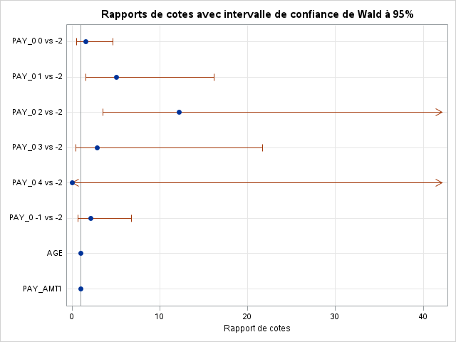

| Association des probabilités prédites et des réponses observées |  |  |  |
| --- | --- | --- | --- |
| Pourcentage concordant | 72.2 | D de Somers | 0.444 |
| Pourcentage discordant | 27.8 | Gamma | 0.444 |
| Pourcentage lié | 0.0 | Tau-a | 0.157 |
| Paires | 44275 | c | 0.722 |

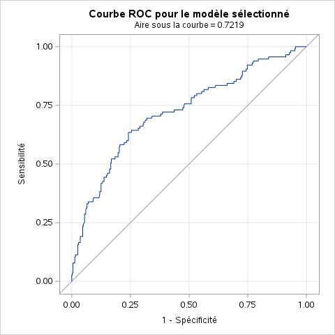

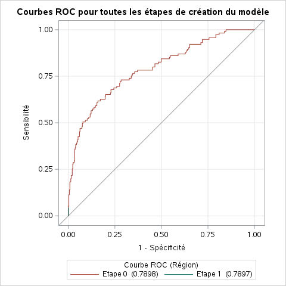

| Partition pour les tests de Hosmer et de Lemeshow Groupe | Partition pour les tests de Hosmer et de Lemeshow Total | Partition pour les tests de Hosmer et de Lemeshow defaultpayment = 1 Observé | Partition pour les tests de Hosmer et de Lemeshow defaultpayment = 1 Attendu | Partition pour les tests de Hosmer et de Lemeshow defaultpayment = 0 Observé | Partition pour les tests de Hosmer et de Lemeshow defaultpayment = 0 Attendu |
| --- | --- | --- | --- | --- | --- |
| 1 | 50 | 5 | 3.25 | 45 | 46.75 |
| 2 | 50 | 4 | 5.85 | 46 | 44.15 |
| 3 | 50 | 10 | 6.65 | 40 | 43.35 |
| 4 | 50 | 4 | 7.30 | 46 | 42.70 |
| 5 | 50 | 9 | 8.12 | 41 | 41.88 |
| 6 | 50 | 4 | 9.36 | 46 | 40.64 |
| 7 | 50 | 12 | 10.80 | 38 | 39.20 |
| 8 | 50 | 18 | 13.90 | 32 | 36.10 |
| 9 | 50 | 20 | 20.42 | 30 | 29.58 |
| 10 | 50 | 29 | 29.34 | 21 | 20.66 |

| Test d'adéquation de Hosmer et de Lemeshow khi-2 | Test d'adéquation de Hosmer et de Lemeshow DDL | Test d'adéquation de Hosmer et de Lemeshow Pr > khi-2 |
| --- | --- | --- |
| 11.1134 | 8 | 0.1954 |

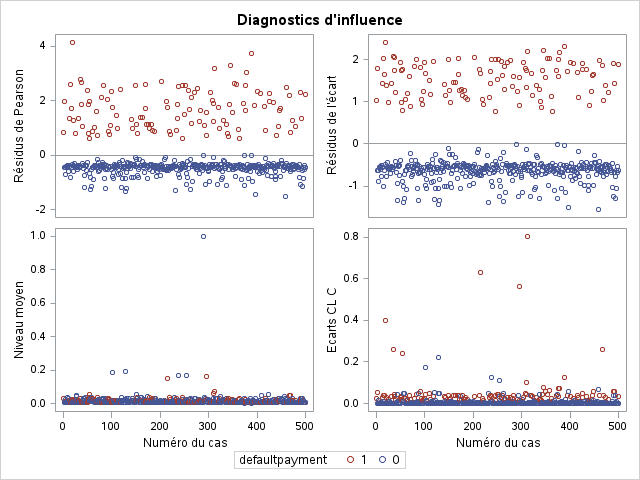

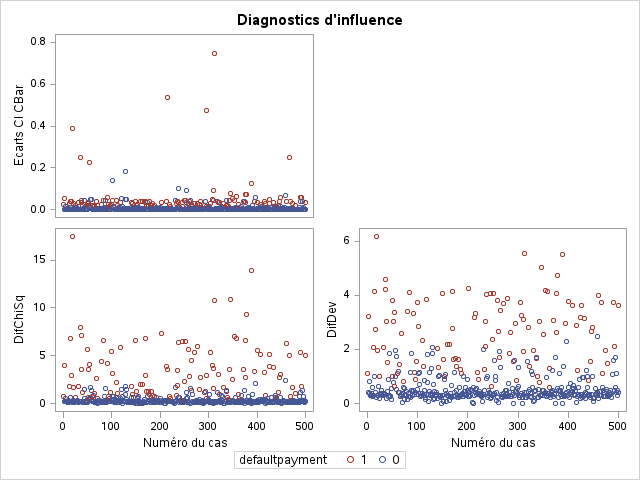

Données : défauts de paiement des clients à Taïwan

Matrice de confusion

[output not shown]

Données : défauts de paiement des clients à Taïwan

Matrice de confusion

| Obs. | ID | LIMIT_BAL | SEX | EDUCATION | MARRIAGE | AGE | PAY_0 | PAY_2 | PAY_3 | PAY_4 | PAY_5 | PAY_6 | BILL_AMT1 | BILL_AMT2 | BILL_AMT3 | BILL_AMT4 | BILL_AMT5 | BILL_AMT6 | PAY_AMT1 | PAY_AMT2 | PAY_AMT3 | PAY_AMT4 | PAY_AMT5 | PAY_AMT6 | defaultpayment | P_0 | P_1 | Prediction |
| --- | --- | --- | --- | --- | --- | --- | --- | --- | --- | --- | --- | --- | --- | --- | --- | --- | --- | --- | --- | --- | --- | --- | --- | --- | --- | --- | --- | --- |
| 1 | 3 | 90000 | 2 | 2 | 2 | 34 | 0 | 0 | 0 | 0 | 0 | 0 | 29239 | 14027 | 13559 | 14331 | 14948 | 15549 | 1518 | 1500 | 1000 | 1000 | 1000 | 5000 | 0 | 0.82828 | 0.17172 | Non |
| 2 | 7 | 500000 | 1 | 1 | 2 | 29 | 0 | 0 | 0 | 0 | 0 | 0 | 367965 | 412023 | 445007 | 542653 | 483003 | 473944 | 55000 | 40000 | 38000 | 20239 | 13750 | 13770 | 0 | 0.99050 | 0.00950 | Non |
| 3 | 16 | 50000 | 2 | 3 | 3 | 23 | 1 | 2 | 0 | 0 | 0 | 0 | 50614 | 29173 | 28116 | 28771 | 29531 | 30211 | 0 | 1500 | 1100 | 1200 | 1300 | 1100 | 0 | 0.63962 | 0.36038 | Non |
| 4 | 18 | 320000 | 1 | 1 | 1 | 49 | 0 | 0 | 0 | -1 | -1 | -1 | 253286 | 246536 | 194663 | 70074 | 5856 | 195599 | 10358 | 10000 | 75940 | 20000 | 195599 | 50000 | 0 | 0.84416 | 0.15584 | Non |
| 5 | 19 | 360000 | 2 | 1 | 1 | 49 | 1 | -2 | -2 | -2 | -2 | -2 | 0 | 0 | 0 | 0 | 0 | 0 | 0 | 0 | 0 | 0 | 0 | 0 | 0 | 0.48244 | 0.51756 | Oui |
| 6 | 23 | 70000 | 2 | 2 | 2 | 26 | 2 | 0 | 0 | 2 | 2 | 2 | 41087 | 42445 | 45020 | 44006 | 46905 | 46012 | 2007 | 3582 | 0 | 3601 | 0 | 1820 | 1 | 0.43208 | 0.56792 | Oui |
| 7 | 28 | 50000 | 2 | 3 | 2 | 30 | 0 | 0 | 0 | 0 | 0 | 0 | 22541 | 16138 | 17163 | 17878 | 18931 | 19617 | 1300 | 1300 | 1000 | 1500 | 1000 | 1012 | 0 | 0.84031 | 0.15969 | Non |
| 8 | 41 | 360000 | 1 | 1 | 2 | 33 | 0 | 0 | 0 | 0 | 0 | 0 | 218668 | 221296 | 206895 | 628699 | 195969 | 179224 | 10000 | 7000 | 6000 | 188840 | 28000 | 4000 | 0 | 0.88756 | 0.11244 | Non |
| 9 | 42 | 70000 | 2 | 1 | 2 | 25 | 0 | 0 | 0 | 0 | 0 | 0 | 67521 | 66999 | 63949 | 63699 | 64718 | 65970 | 3000 | 4500 | 4042 | 2500 | 2800 | 2500 | 0 | 0.86740 | 0.13260 | Non |
| 10 | 43 | 10000 | 1 | 2 | 2 | 22 | 0 | 0 | 0 | 0 | 0 | 0 | 1877 | 3184 | 6003 | 3576 | 3670 | 4451 | 1500 | 2927 | 1000 | 300 | 1000 | 500 | 0 | 0.86642 | 0.13358 | Non |
| 11 | 50 | 20000 | 1 | 1 | 2 | 24 | 0 | 0 | 0 | 0 | 0 | 0 | 17447 | 18479 | 19476 | 19865 | 20480 | 20063 | 1318 | 1315 | 704 | 928 | 912 | 1069 | 0 | 0.85938 | 0.14062 | Non |
| 12 | 62 | 70000 | 1 | 2 | 1 | 39 | 0 | 0 | 0 | 0 | 0 | -1 | 70800 | 72060 | 69938 | 16518 | 14096 | 830 | 4025 | 2095 | 1000 | 2000 | 3000 | 0 | 0 | 0.83032 | 0.16968 | Non |
| 13 | 76 | 20000 | 1 | 2 | 2 | 24 | 0 | 0 | 2 | 0 | 0 | 0 | 14619 | 17216 | 16642 | 16976 | 17332 | 18543 | 2850 | 0 | 610 | 630 | 1500 | 0 | 0 | 0.86928 | 0.13072 | Non |
| 14 | 77 | 50000 | 1 | 3 | 2 | 25 | -1 | 0 | 0 | 0 | 0 | 0 | 42838 | 37225 | 36087 | 9636 | 9590 | 10030 | 1759 | 1779 | 320 | 500 | 1000 | 1000 | 0 | 0.81550 | 0.18450 | Non |
| 15 | 78 | 300000 | 2 | 1 | 1 | 45 | -1 | -1 | -1 | -1 | -1 | -1 | 291 | 291 | 291 | 291 | 291 | 291 | 291 | 291 | 291 | 291 | 291 | 291 | 0 | 0.71296 | 0.28704 | Non |
| 16 | 79 | 30000 | 2 | 2 | 2 | 22 | 0 | 0 | 0 | 0 | 0 | 0 | 28387 | 29612 | 30326 | 28004 | 26446 | 6411 | 1686 | 1400 | 560 | 3000 | 1765 | 0 | 1 | 0.86761 | 0.13239 | Non |
| 17 | 83 | 60000 | 1 | 3 | 2 | 30 | 0 | 0 | 0 | 0 | 0 | 0 | 26324 | 27471 | 28108 | 21993 | 19899 | 19771 | 1576 | 1213 | 648 | 768 | 1140 | 0 | 1 | 0.84234 | 0.15766 | Non |
| 18 | 84 | 400000 | 2 | 2 | 1 | 44 | 0 | 0 | 2 | 0 | 0 | 0 | 131595 | 139060 | 126819 | 104430 | 104990 | 94058 | 10700 | 3 | 3050 | 3000 | 3200 | 2800 | 0 | 0.86203 | 0.13797 | Non |
| 19 | 85 | 50000 | 2 | 3 | 2 | 49 | 0 | 0 | 0 | 0 | 0 | 0 | 48909 | 47863 | 21489 | 20414 | 19342 | 19482 | 1676 | 1302 | 700 | 699 | 849 | 826 | 0 | 0.77041 | 0.22959 | Non |
| 20 | 90 | 20000 | 1 | 3 | 2 | 44 | 2 | 2 | 0 | 0 | 0 | 2 | 8583 | 8303 | 9651 | 10488 | 12314 | 11970 | 0 | 1651 | 1000 | 2000 | 0 | 1500 | 0 | 0.30367 | 0.69633 | Oui |
| 21 | 98 | 150000 | 1 | 1 | 2 | 27 | 0 | 0 | 0 | 0 | 0 | 0 | 86009 | 86108 | 89006 | 89775 | 87725 | 40788 | 4031 | 10006 | 3266 | 4040 | 1698 | 800 | 0 | 0.86824 | 0.13176 | Non |
| 22 | 105 | 60000 | 2 | 2 | 2 | 26 | 2 | 2 | 2 | 2 | 2 | 0 | 56685 | 55208 | 59175 | 60218 | 55447 | 55305 | 0 | 5000 | 2511 | 6 | 3000 | 3000 | 0 | 0.40515 | 0.59485 | Oui |
| 23 | 106 | 70000 | 2 | 2 | 2 | 24 | -1 | -1 | -2 | -2 | -2 | -1 | 5580 | 0 | 0 | 0 | 0 | 26529 | 0 | 0 | 0 | 0 | 26529 | 2000 | 0 | 0.80438 | 0.19562 | Non |
| 24 | 107 | 80000 | 2 | 2 | 1 | 36 | -1 | -1 | -1 | -1 | -1 | -1 | 6108 | 2861 | 3277 | 3319 | 1150 | 1150 | 2861 | 3279 | 3319 | 1150 | 1150 | 1035 | 0 | 0.78151 | 0.21849 | Non |
| 25 | 108 | 350000 | 1 | 1 | 2 | 52 | -1 | -1 | -1 | -1 | -1 | -1 | 713 | 2272 | 722 | 867 | 1150 | 5263 | 2272 | 722 | 867 | 1150 | 5263 | 5011 | 0 | 0.69966 | 0.30034 | Non |
| 26 | 123 | 110000 | 2 | 1 | 1 | 48 | 1 | -2 | -2 | -2 | -2 | -2 | 0 | 0 | 0 | 0 | 0 | 0 | 0 | 0 | 0 | 0 | 0 | 0 | 0 | 0.48863 | 0.51137 | Oui |
| 27 | 124 | 310000 | 2 | 2 | 1 | 35 | 2 | 0 | 0 | 0 | 0 | 0 | 304991 | 311243 | 306314 | 258610 | 246491 | 198889 | 13019 | 11128 | 8407 | 8599 | 6833 | 5987 | 1 | 0.52776 | 0.47224 | Non |
| 28 | 126 | 20000 | 1 | 2 | 2 | 23 | 1 | -2 | -2 | -2 | -2 | -2 | 0 | 0 | 0 | 0 | 0 | 0 | 0 | 0 | 0 | 0 | 0 | 0 | 0 | 0.63962 | 0.36038 | Non |
| 29 | 136 | 240000 | 1 | 2 | 1 | 34 | 0 | 0 | 0 | 2 | 2 | 2 | 10674 | 12035 | 13681 | 13269 | 14158 | 13891 | 1500 | 1800 | 0 | 1000 | 0 | 327 | 0 | 0.82814 | 0.17186 | Non |
| 30 | 149 | 80000 | 2 | 2 | 1 | 23 | 1 | 2 | 3 | 2 | 0 | 0 | 9168 | 10522 | 10205 | 9898 | 10123 | 12034 | 1650 | 0 | 0 | 379 | 2091 | 1 | 0 | 0.66033 | 0.33967 | Non |

[output cut: 65 more lines]

Données : défauts de paiement des clients à Taïwan